# GWAS Accelerometry UEA

2025-12-03

How to read this report: Sections 1–7 describe the GWAS harmonization and preprocessing pipeline, while sections executed with live evaluation (eval = TRUE) — notably 8, 9, 11–12, and 14–19 — present diagnostic outputs, causal results, and machine-learning feature screening derived from the harmonized data.

Purpose of the workflow

This report documents the standardized ingestion, harmonization, and quality control of multiple GWAS summary-statistics datasets spanning accelerometry-derived physical activity traits, biological predictors, and aging-related outcomes. The primary objective is to construct two fully aligned analysis matrices:

a SNP × trait effect size matrix for Elastic Net machine-learning modeling, and

a long-format GWAS table optimized for two-sample Mendelian Randomization analyses.

Sections 1–3 are executed with live evaluation (eval = TRUE) to establish the computational environment, automatically discover all GWAS inputs, standardize heterogeneous column formats, and define biologically meaningful trait mappings required for downstream processing.

From Section 4 onward, the workflow implements the core harmonization and quality control pipeline, including accelerometry-based SNP universe construction, CHR:BP → rsID mapping, global SNP intersection, duplicate control, integrity audits, and generation of final modeling matrices. Several of these steps are computationally intensive and therefore configured with eval = FALSE once validated. To ensure reproducibility without repeated heavy computation, key intermediate and final datasets are cached to disk as RDS files, including:

accel_reference_snps.rds — shared accelerometry SNP universe

gwas_list_final.rds — fully harmonized GWAS traits aligned to the common SNP set

X_elastic_net.rds — full SNP × trait effect size matrix

gwas_mr.rds — long-format MR-ready dataset

These saved objects are reloaded in later sections to support validation, visualization, causal inference, and machine-learning analyses without rerunning the entire preprocessing pipeline.

The primary analytical results are presented in sections executed with live evaluation (eval = TRUE), specifically:

Section 8 — post-harmonization sanity checks and effect size diagnostics

Section 9 — MR field availability audits

Section 11 — MR input integrity diagnostics

Section 12 — exhaustive SNP harmonization validation

Section 14 — reloading and reproducible restoration of MR result objects

Section 15 — Mendelian Randomization causal estimates and sensitivity visualizations

Section 16 — SNP dimensionality reduction for Elastic Net modeling

Section 17 — SNP-level genetic correlation screening

Section 18 — univariate SNP-level regression screening

Section 19 — integrated predictor prioritization across methods

Together, this workflow delivers a rigorously harmonized genetic dataset, efficient reuse of large-scale intermediate objects, and a transparent results framework connecting causal inference and machine-learning approaches to characterize shared genetic architecture underlying human aging outcomes.

# 1. GWAS Data Ingestion and Harmonized Preprocessing

This section initializes a memory-safe R environment and defines standardized paths for all GWAS summary-statistics inputs, including accelerometry traits, biological predictors, and aging outcomes. It programmatically discovers all GWAS files to ensure scalable integration and consistent downstream processing.

## 1.1 Environment setup and memory-safe configuration

```r
options(datatable.fread.mmap = FALSE)

library(data.table)
library(dplyr)
library(stringr)
```

## 1.2 Definition of GWAS file paths and GWAS input discovery

```r
#============================================================
# 1. Set folder paths (DO NOT CHANGE EXISTING LOGIC)
#============================================================

# PA predictors (PA traits – unchanged)
path_accel <- "C:/Users/75118/Desktop/UEA/Proyecto 1/data/predictor traits/accelerometry"

# Other biological predictors (CRF, lipids, BMD, etc.)
path_other <- "C:/Users/75118/Desktop/UEA/Proyecto 1/data/predictor traits"

# Optional: where to save intermediate SNP list (so you can reuse without reloading accel)
out_dir <- "C:/Users/75118/Desktop/UEA/Proyecto 1"
snp_ref_file <- file.path(out_dir, "accel_reference_snps.rds")

#============================================================
# 2. List GWAS files (extended, but compatible)
#============================================================

files_accel <- list.files(
  path_accel,
  pattern = "\\.(tsv|txt|assoc|tbl)$",
  full.names = TRUE
)



files_other <- list.files(
  path_other,
  pattern = "\\.(tsv|txt|assoc|tbl)$",
  full.names = TRUE
)

# Remove accelerometry files from other predictors (safety)
files_other <- setdiff(files_other, files_accel)

# After defining files_other
files_outcomes <- list.files(
  "C:/Users/75118/Desktop/UEA/Proyecto 1/data/outcome traits",
  pattern = "\\.tsv$|\\.txt$",
  full.names = TRUE
)

# Treat outcomes exactly like other non-PA traits
files_other <- c(files_other, files_outcomes)

length(files_accel)  # should be PA traits
```

[1] 1

```r
length(files_other)  # should be your non-accelerometry predictors
```

[1] 32

```r
print(files_accel)
```

[1] “C:/Users/75118/Desktop/UEA/Proyecto 1/data/predictor traits/accelerometry/GCST90104341_MVPA.tsv”

```r
print(files_other)
```

[1] “C:/Users/75118/Desktop/UEA/Proyecto 1/data/predictor traits/GCST006979-heel bone mineral density.txt.txt”  
[2] “C:/Users/75118/Desktop/UEA/Proyecto 1/data/predictor traits/GCST007474_smoking_initiation.txt”  
[3] “C:/Users/75118/Desktop/UEA/Proyecto 1/data/predictor traits/GCST007576-chronotype.txt.txt”  
[4] “C:/Users/75118/Desktop/UEA/Proyecto 1/data/predictor traits/GCST007609_resting_heart_rate.assoc”  
[5] “C:/Users/75118/Desktop/UEA/Proyecto 1/data/predictor traits/GCST008999_WHRadjBMI.tbl”  
[6] “C:/Users/75118/Desktop/UEA/Proyecto 1/data/predictor traits/GCST90016671-visceral fat.tsv”  
[7] “C:/Users/75118/Desktop/UEA/Proyecto 1/data/predictor traits/GCST90044317_sugar_intake.tsv”  
[8] “C:/Users/75118/Desktop/UEA/Proyecto 1/data/predictor traits/GCST90061408_acc_total_log.tsv”  
[9] “C:/Users/75118/Desktop/UEA/Proyecto 1/data/predictor traits/GCST90061421_acc_LIPA.tsv”  
[10] “C:/Users/75118/Desktop/UEA/Proyecto 1/data/predictor traits/GCST90061422_acc_MVPA.tsv”  
[11] “C:/Users/75118/Desktop/UEA/Proyecto 1/data/predictor traits/GCST90061431_acc_L5_inactivity.tsv”  
[12] “C:/Users/75118/Desktop/UEA/Proyecto 1/data/predictor traits/GCST90061432_acc_relative_amplitude.tsv”  
[13] “C:/Users/75118/Desktop/UEA/Proyecto 1/data/predictor traits/GCST90093316-cardiorespiratory fitness VO2max.tsv” [14] “C:/Users/75118/Desktop/UEA/Proyecto 1/data/predictor traits/GCST90093319-cardiorespiratory fitness slope.tsv” [15] “C:/Users/75118/Desktop/UEA/Proyecto 1/data/predictor traits/GCST90104339-leasure time.tsv”  
[16] “C:/Users/75118/Desktop/UEA/Proyecto 1/data/predictor traits/GCST90104341_self_MVPA.tsv”  
[17] “C:/Users/75118/Desktop/UEA/Proyecto 1/data/predictor traits/GCST90179146-C-reactive protein levels.tsv”  
[18] “C:/Users/75118/Desktop/UEA/Proyecto 1/data/predictor traits/GCST90239652-HDL cholesterol levels.tsv”  
[19] “C:/Users/75118/Desktop/UEA/Proyecto 1/data/predictor traits/GCST90239658-LDL cholesterol levels.tsv”  
[20] “C:/Users/75118/Desktop/UEA/Proyecto 1/data/predictor traits/GCST90239664-triglyceride levels.tsv”  
[21] “C:/Users/75118/Desktop/UEA/Proyecto 1/data/predictor traits/GCST90302892_WCadjBMI.tsv”  
[22] “C:/Users/75118/Desktop/UEA/Proyecto 1/data/predictor traits/GCST90468164-walk time.tsv”  
[23] “C:/Users/75118/Desktop/UEA/Proyecto 1/data/predictor traits/GCST90565845-hand grip strength baseline.tsv”  
[24] “C:/Users/75118/Desktop/UEA/Proyecto 1/data/predictor traits/GCST90691576-glycated hemoglobin.tsv”  
[25] “C:/Users/75118/Desktop/UEA/Proyecto 1/data/predictor traits/GCST90691840_FEV1.tsv”  
[26] “C:/Users/75118/Desktop/UEA/Proyecto 1/data/predictor traits/GCST90691882-walk days.tsv”  
[27] “C:/Users/75118/Desktop/UEA/Proyecto 1/data/predictor traits/GCST90692657-whole body fat mass.tsv”  
[28] “C:/Users/75118/Desktop/UEA/Proyecto 1/data/predictor traits/GCST90692693-whole body fat free mass.tsv”  
[29] “C:/Users/75118/Desktop/UEA/Proyecto 1/data/predictor traits/GCST90692919-white blood cell count.tsv”  
[30] “C:/Users/75118/Desktop/UEA/Proyecto 1/data/outcome traits/GCST007406-healthspan.tsv”  
[31] “C:/Users/75118/Desktop/UEA/Proyecto 1/data/outcome traits/GCST009890-parental lifespan.tsv”  
[32] “C:/Users/75118/Desktop/UEA/Proyecto 1/data/outcome traits/GCST90693086-usual walking pace.tsv”

```r
library(data.table)

# Path to self-reported MVPA
self_mvpa_file <- "C:/Users/75118/Desktop/UEA/Proyecto 1/data/predictor traits/accelerometry/GCST90104341_MVPA.tsv"

dt <- fread(
  file = self_mvpa_file,
  showProgress = FALSE
)

# Identify valid rsIDs
dt_clean <- dt[
  !is.na(variant_id) &
  variant_id != "" &
  variant_id != "#NA" &
  grepl("^rs[0-9]+$", variant_id)
]

# Sanity check
cat("Before:", nrow(dt), "\n")
```

Before: 22586718

```r
cat("After :", nrow(dt_clean), "\n")
```

After : 15927656

```r
cat(
  "Retained:",
  round(100 * nrow(dt_clean) / nrow(dt), 2),
  "%\n"
)
```

Retained: 70.52 %

```r
# OPTIONAL: rename for consistency with your pipeline
setnames(dt_clean, "variant_id", "SNP")

# Save cleaned reference into accelerometry folder
saveRDS(
  dt_clean,
  file = file.path(
    path_accel,
    "GCST90104341_MVPA_rsID_only_reference.rds"
  )
)


# Cleaned rsID-only MVPA reference
files_accel1 <- file.path(
  path_accel,
  "GCST90104341_MVPA_rsID_only_reference.rds"
)




library(data.table)

library(DT)

#------------------------------------------------------------
# 1) Read raw self-reported MVPA (TSV)
#------------------------------------------------------------
raw_mvpa_file <- files_accel[grepl("GCST90104341_MVPA", files_accel)]
raw_mvpa <- fread(file = raw_mvpa_file, showProgress = FALSE)

datatable(
  raw_mvpa[1:10],
  options = list(
    scrollX = TRUE,
    pageLength = 10
  ),
  caption = "Raw MVPA (first 10 rows)"
)
```

|  | chromosome | base_pair_location | effect_allele | other_allele | beta | standard_error | effect_allele_frequency | p_value | variant_id | SampleSize |
| --- | --- | --- | --- | --- | --- | --- | --- | --- | --- | --- |
| 1 | 1 | 100000012 | t | g | -0.0053 | 0.0036 | 0.2587 | 0.1464 | rs10875231 | 603082 |
| 2 | 1 | 10000006 | a | g | -0.0152 | 0.033 | 0.0047 | 0.6451 | rs186077422 | 477188 |
| 3 | 1 | 100000135 | a | t | 0.0107 | 0.0499 | 0.9981 | 0.8309 | rs114947036 | 451857 |
| 4 | 1 | 100000347 | t | g | 0.5728 | 0.7642 | 0.0075 | 0.4535 | #NA | 1018 |
| 5 | 1 | 100000827 | t | c | -0.0029 | 0.0034 | 0.3168 | 0.3891 | rs6678176 | 603059 |
| 6 | 1 | 100000843 | t | c | -0.0142 | 0.0094 | 0.9505 | 0.1304 | rs78286437 | 482598 |
| 7 | 1 | 100000989 | a | atc | -0.0077 | 0.01 | 0.9536 | 0.4389 | rs146963890 | 448902 |
| 8 | 1 | 100001138 | a | g | -0.0271 | 0.0137 | 0.9748 | 0.04775 | rs144406489 | 482598 |
| 9 | 1 | 100001201 | t | g | -0.0064 | 0.0068 | 0.0976 | 0.3497 | rs76909621 | 484633 |
| 10 | 1 | 100001483 | a | g | 0.6832 | 0.3906 | 0.0036 | 0.08026 | #NA | 12298 |

```r
#------------------------------------------------------------
# 2) Read cleaned rsID-only MVPA (RDS)
#------------------------------------------------------------
clean_mvpa <- readRDS(files_accel1)

datatable(
  clean_mvpa[1:10],
  options = list(
    scrollX = TRUE,
    pageLength = 10
  ),
  caption = "Cleaned MVPA (rsID-only, first 10 rows)"
)
```

|  | chromosome | base_pair_location | effect_allele | other_allele | beta | standard_error | effect_allele_frequency | p_value | SNP | SampleSize |
| --- | --- | --- | --- | --- | --- | --- | --- | --- | --- | --- |
| 1 | 1 | 100000012 | t | g | -0.0053 | 0.0036 | 0.2587 | 0.1464 | rs10875231 | 603082 |
| 2 | 1 | 10000006 | a | g | -0.0152 | 0.033 | 0.0047 | 0.6451 | rs186077422 | 477188 |
| 3 | 1 | 100000135 | a | t | 0.0107 | 0.0499 | 0.9981 | 0.8309 | rs114947036 | 451857 |
| 4 | 1 | 100000827 | t | c | -0.0029 | 0.0034 | 0.3168 | 0.3891 | rs6678176 | 603059 |
| 5 | 1 | 100000843 | t | c | -0.0142 | 0.0094 | 0.9505 | 0.1304 | rs78286437 | 482598 |
| 6 | 1 | 100000989 | a | atc | -0.0077 | 0.01 | 0.9536 | 0.4389 | rs146963890 | 448902 |
| 7 | 1 | 100001138 | a | g | -0.0271 | 0.0137 | 0.9748 | 0.04775 | rs144406489 | 482598 |
| 8 | 1 | 100001201 | t | g | -0.0064 | 0.0068 | 0.0976 | 0.3497 | rs76909621 | 484633 |
| 9 | 1 | 100001671 | ct | c | -0.0069 | 0.0049 | 0.2637 | 0.155 | rs571399445 | 448902 |
| 10 | 1 | 100001846 | a | g | -0.0228 | 0.0706 | 0.0012 | 0.7471 | rs566110988 | 448902 |

# 2. Robust GWAS Reader and Column Standardization

This section defines a flexible, memory-efficient GWAS reader capable of harmonizing heterogeneous summary-statistics formats. It standardizes SNP identifiers, alleles, effect sizes, standard errors, and allele frequencies across studies, while supporting both rsID and CHR:BP SNP formats.

## 2.1 Memory-efficient GWAS loading and column harmonization function

```r
#============================================================
# 3. Robust reader helpers (UNCHANGED logic, but reusable)
#============================================================

# Define column aliases based on your audit
col_aliases <- list(
  SNP  = c("RSID","rsid","rs_id","variant_id","SNP","SNPID","snpid"),
  EA   = c("effect_allele","EA","A1","a1","ALLELE1","Allele1","ALT"),
  OA   = c("other_allele","OA","A2","a0","ALLELE0","Allele2","REF"),
  BETA = c("beta","BETA","effect","beta1","Effect"),
  SE   = c("standard_error","SE","se","StdErr"),
  EAF  = c("effect_allele_frequency","EAF","A1FREQ","freq1","Freq1","AF","MAF")
)


read_gwas_4cols <- function(f) {

  # Read header only
  cols <- strsplit(readLines(f, n = 1), "[\t ]+")[[1]]

  # Identify matching columns
  selected <- lapply(col_aliases, function(x) intersect(x, cols)[1])

  has_snp  <- !is.na(selected$SNP)
  has_beta <- !is.na(selected$BETA)

  # Allow CHR+BP instead of SNP
  chr_alias <- c("chromosome","CHR","chr","CHROM")
  bp_alias  <- c("base_pair_location","BP","pos","POS","position")

  has_chr <- any(chr_alias %in% cols)
  has_bp  <- any(bp_alias %in% cols)

  has_chr_bp <- has_chr & has_bp


  if (!has_beta) {
    stop(
      "Missing BETA column in file: ", basename(f), "\n",
      "Detected columns: ", paste(cols, collapse = ", ")
    )
  }

  if (!has_snp && !has_chr_bp) {
    stop(
      "Missing SNP and CHR/BP columns in file: ", basename(f), "\n",
      "Detected columns: ", paste(cols, collapse = ", ")
    )
  }

  # Columns to read
  read_cols <- unname(unlist(selected[c("SNP", "EA", "OA", "BETA", "SE", "EAF")]))
  read_cols <- read_cols[!is.na(read_cols)]

  # Also read chr/bp if SNP missing
  if (!has_snp && has_chr_bp) {
    read_cols <- unique(c(read_cols, "chromosome", "base_pair_location"))
  }

  # Read file (memory-safe)
  df <- fread(
    cmd = paste("cmd /c type", shQuote(normalizePath(f, winslash = "\\"))),
    select = read_cols,
    showProgress = FALSE
  )

  # Rename known columns
  rename_map <- unlist(selected[!is.na(selected)], use.names = TRUE)

  setnames(
    df,
    old = unname(rename_map),
    new = names(rename_map),
    skip_absent = TRUE
  )

  # Construct SNP if needed
  if (!"SNP" %in% names(df) && has_chr_bp) {
    df[, SNP := paste0(chromosome, ":", base_pair_location)]
  }

  # Ensure allele columns exist
  if (!"EA" %in% names(df)) df[, EA := NA_character_]
  if (!"OA" %in% names(df)) df[, OA := NA_character_]

  # Keep final structure (now includes SE and EAF if present)
  keep_cols <- c("SNP", "EA", "OA", "BETA", "SE", "EAF")
  keep_cols <- intersect(keep_cols, names(df))

  df <- df[, ..keep_cols]

  return(df)
}
```

# 3. Trait Annotation and Biological Mapping

GWAS filenames are explicitly mapped to biologically meaningful trait names, spanning accelerometry phenotypes, physiological predictors, and aging outcomes. This ensures transparent interpretation and standardized labeling throughout modeling and causal analyses.

## 3.1 Trait filename to phenotype mapping

```r
#============================================================
# 4. Trait mapping (UNCHANGED + new predictors)
#============================================================

trait_mapping <- c(

  # -----------------------------
  # Accelerometry traits (UNCHANGED)
  # -----------------------------
  "GCST90104341_MVPA.tsv" = "MVPA",

  # -----------------------------
  # Additional predictors
  # -----------------------------
  "GCST90093319-cardiorespiratory fitness slope.tsv" = "CRF_slope",
  "GCST90093316-cardiorespiratory fitness VO2max.tsv" = "CRF_VO2max",
  "GCST007576-chronotype.txt.txt" = "Chronotype",
  "GCST90179146-C-reactive protein levels.tsv" = "CRP",
  "GCST90691576-glycated hemoglobin.tsv" = "HbA1c",
  "GCST90565845-hand grip strength baseline.tsv" = "Grip_strength",
  "GCST90239652-HDL cholesterol levels.tsv" = "HDL",
  "GCST90239658-LDL cholesterol levels.tsv" = "LDL",
  "GCST90239664-triglyceride levels.tsv" = "Triglycerides",
  "GCST90692919-white blood cell count.tsv" = "WBC",
  "GCST90016671-visceral fat.tsv" = "VAT",
  "GCST90692657-whole body fat mass.tsv" = "Fat_mass",
  "GCST90692693-whole body fat free mass.tsv" = "Fat_free_mass",
  "GCST006979-heel bone mineral density.txt.txt" = "BMD",

  "GCST007474_smoking_initiation.txt"        = "Smoking_initiation",
  "GCST007609_resting_heart_rate.assoc"      = "Resting_heart_rate",
  "GCST008999_WHRadjBMI.tbl"                 = "WHR_adjBMI",
  "GCST90302892_WCadjBMI.tsv"                = "WC_adjBMI",
  "GCST90044317_sugar_intake.tsv"            = "Sugar_intake",
  "GCST90691840_FEV1.tsv" = "FEV1",


  # Device accelerometry traits (if included in elastic net)
  "GCST90061408_acc_total_log.tsv"           = "Acc_total_log",
  "GCST90061421_acc_LIPA.tsv"                = "Acc_LIPA",
  "GCST90061422_acc_MVPA.tsv"                = "Acc_MVPA",
  "GCST90061431_acc_L5_inactivity.tsv"       = "Acc_L5_inactivity",
  "GCST90061432_acc_relative_amplitude.tsv"  = "Acc_relative_amplitude",


  # -----------------------------
  # Additional PA (self-reported / walking)
  # -----------------------------
  "GCST90104339-leasure time.tsv" = "Leisure_Screen_t",
  "GCST90468164-walk time.tsv"    = "Walking_time",
  "GCST90691882-walk days.tsv"    = "Walking_days",
  "GCST90104341_self_MVPA.tsv"    = "Self_MVPA",

  # -----------------------------
  # Aging outcomes
  # -----------------------------
  "GCST007406-healthspan.tsv"           = "Healthspan",
  "GCST009890-parental lifespan.tsv"    = "Parental_lifespan",
  "GCST90693086-usual walking pace.tsv" = "Usual_walking_pace"
)
```

# 4. Accelerometry Reference SNP Universe Construction

Accelerometry GWAS traits are loaded first to define a high-quality, shared SNP reference universe. Because all accelerometry traits originate from the same UK Biobank GWAS framework, a single trait is sufficient to establish the full SNP panel.

## 4.1 Loading accelerometry GWAS and defining the common SNP reference panel

```r
#============================================================
# 5. STAGE 1 — Load accelerometry only (27 files)
#============================================================

gwas_accel <- lapply(files_accel, read_gwas_4cols)

names(gwas_accel) <- basename(files_accel)

# Apply rename safely for accelerometry
names(gwas_accel) <- trait_mapping[basename(files_accel)]
stopifnot(!any(is.na(names(gwas_accel))))

# ------------------------------------------------------------
# FAST SNP reference (no union / no intersect)
# ------------------------------------------------------------

# All PA traits share identical SNPs → use first trait
accel_snps <- gwas_accel[[1]]$SNP

# Optional: save for reuse
saveRDS(accel_snps, snp_ref_file)

# Summary table (constant-time)
summary_stage1 <- data.frame(
  Stage = c("Union (≥1 PA trait)", "Intersection (ALL PA traits)"),
  N_SNPs = c(length(accel_snps), length(accel_snps)),
  Retained_pct = c(100, 100)
)

summary_stage1
```

# 5. SNP Format Audit and Harmonization

Before large-scale integration, SNP identifier formats across all GWAS files are audited to detect rsID versus CHR:BP usage. This pre-flight step prevents silent mismatches and guides the required mapping strategy.

## 5.1 Pre-flight SNP identifier format detection

Representative rows from each GWAS file are scanned to quantify rsID and CHR:BP usage, flagging datasets requiring coordinate-to-rsID conversion prior to joint analysis.

```r
#============================================================
# 5B. PRE-FLIGHT SNP FORMAT CHECK
#     - 1 PA reference file
#     - all non-PA traits
#============================================================

check_snp_format_fast <- function(f, group, n = 100) {

  lines <- tryCatch(readLines(f, n = n), error = function(e) NULL)

  if (is.null(lines) || length(lines) < 2) {
    return(data.frame(
      file = basename(f),
      group = group,
      snp_type = "READ_ERROR",
      rsID_pct = NA_real_,
      chr_bp_pct = NA_real_
    ))
  }

  # Parse header
  header <- strsplit(lines[1], "[\t ]+")[[1]]

  snp_col   <- intersect(c("RSID","rsid","rs_id","SNP","variant_id","SNPID"), header)
  has_chr_bp <- all(c("chromosome", "base_pair_location") %in% header)

  # Parse first data rows
  data <- strsplit(lines[-1], "[\t ]+")
  df <- as.data.frame(do.call(rbind, data), stringsAsFactors = FALSE)
  names(df) <- header[seq_len(ncol(df))]

  # Extract SNPs
  if (length(snp_col) > 0 && snp_col[1] %in% names(df)) {
    snp <- df[[snp_col[1]]]
  } else if (has_chr_bp) {
    snp <- paste0(df$chromosome, ":", df$base_pair_location)
  } else {
    return(data.frame(
      file = basename(f),
      group = group,
      snp_type = "UNKNOWN",
      rsID_pct = NA_real_,
      chr_bp_pct = NA_real_
    ))
  }

  rs_pct  <- mean(grepl("^rs[0-9]+$", snp))
  chr_pct <- mean(grepl("^[0-9]+:[0-9]+$", snp))

  data.frame(
    file = basename(f),
    group = group,
    snp_type = ifelse(rs_pct > 0.5, "rsID", "CHR:BP"),
    rsID_pct = round(rs_pct, 3),
    chr_bp_pct = round(chr_pct, 3)
  )
}

#------------------------------------------------------------
# Run pre-flight
#------------------------------------------------------------

# Use ONE PA file as reference (all PA share same SNPs)
pa_ref_file <- files_accel[1]

snp_format_preflight <- rbind(
  check_snp_format_fast(pa_ref_file, group = "PA_reference"),
  do.call(
    rbind,
    lapply(files_other, check_snp_format_fast, group = "Other")
  )
)




#------------------------------------------------------------
# Scrollable interactive table
#------------------------------------------------------------
library(DT)

datatable(
  snp_format_preflight,
  extensions = c("Scroller"),
  options = list(
    deferRender = TRUE,
    scrollY = 300,      # vertical scroll height (px)
    scrollX = TRUE,     # horizontal scroll
    scroller = TRUE,
    pageLength = nrow(snp_format_preflight),
    dom = "t"           # table only (no search box / pagination)
  ),
  rownames = FALSE
)
```

| file | group | snp_type | rsID_pct | chr_bp_pct |
| --- | --- | --- | --- | --- |
| GCST90104341_MVPA.tsv | PA_reference | rsID | 0.747 | 0 |
| GCST006979-heel bone mineral density.txt.txt | Other | rsID | 0.929 | 0 |
| GCST007474_smoking_initiation.txt | Other | rsID | 1 | 0 |
| GCST007576-chronotype.txt.txt | Other | rsID | 0.98 | 0 |
| GCST007609_resting_heart_rate.assoc | Other | CHR:BP | 0 | 0 |
| GCST008999_WHRadjBMI.tbl | Other | CHR:BP | 0 | 0 |
| GCST90016671-visceral fat.tsv | Other | rsID | 1 | 0 |
| GCST90044317_sugar_intake.tsv | Other | rsID | 1 | 0 |
| GCST90061408_acc_total_log.tsv | Other | rsID | 1 | 0 |
| GCST90061421_acc_LIPA.tsv | Other | rsID | 1 | 0 |

[output cut: 23 more lines]

# 6. Global SNP Harmonization and Quality Control

All GWAS datasets are harmonized onto the accelerometry SNP universe through fast CHR:BP → rsID mapping, global SNP intersection, and duplicate removal. This produces a fully aligned multi-trait GWAS collection with one effect estimate per SNP per trait.

## 6.1 CHR:BP to rsID mapping and cross-trait SNP alignment

Non-PA GWAS traits using coordinate-based SNPs are converted to rsIDs using a reference lookup derived from accelerometry GWAS. All traits are restricted to the shared SNP universe, intersected across datasets, and rigorously deduplicated.

```r
#============================================================
# SECTION 6 — Memory-Safe Global SNP Harmonization
#============================================================

library(data.table)
options(datatable.fread.mmap = FALSE)

#------------------------------------------------------------
# 6.0 Create organized output folders
#------------------------------------------------------------

mapped_dir <- file.path(out_dir, "mapped_full_traits")
final_dir  <- file.path(out_dir, "final_harmonized_traits")

if (!dir.exists(mapped_dir)) dir.create(mapped_dir)
if (!dir.exists(final_dir))  dir.create(final_dir)

cat("📁 Output folders ready\n")


#------------------------------------------------------------
# 6.1 Build PA CHR:BP → rsID lookup (RUN ONLY ONCE)
#------------------------------------------------------------

# ONE PA file is sufficient (all PA traits share SNP universe)
pa_ref_file <- files_accel[1]

pa_lookup <- fread(
  pa_ref_file,
  select = c("variant_id", "chromosome", "base_pair_location"),
  showProgress = FALSE
)

# Build CHR:BP key
pa_lookup[, chr_bp := paste0(chromosome, ":", base_pair_location)]

# variant_id is rsID in UKB PA GWAS
setnames(pa_lookup, "variant_id", "rsID")

# Keep minimal lookup
pa_lookup <- unique(pa_lookup[, .(chr_bp, rsID)])

# Key for fast joins
setkey(pa_lookup, chr_bp)

cat("✅ PA lookup built with",
    nrow(pa_lookup), "CHR:BP → rsID mappings\n")


#------------------------------------------------------------
# 6.2 Sequential Trait Mapping (Memory Safe)
#------------------------------------------------------------

processed_trait_files <- c()

for (i in seq_along(files_other)) {

  f <- files_other[i]
  trait_name <- trait_mapping[basename(f)]

  cat("🔄 Processing:", trait_name, "\n")

  df <- read_gwas_4cols(f)


  # Fix rsID:REF:ALT format
  if (mean(grepl("^rs[0-9]+:[A-Za-z]:[A-Za-z]$", df$SNP)) > 0.5) {
    df[, SNP := sub(":.*", "", SNP)]
  }

  # Detect CHR:BP format
  if (mean(grepl("^rs[0-9]+$", df$SNP)) < 0.5) {

    setnames(df, "SNP", "chr_bp")

    df <- pa_lookup[df, nomatch = 0]

    setnames(df, "rsID", "SNP")

    df[, chr_bp := NULL]
  }

  # Remove duplicated SNPs immediately
  df <- df[!duplicated(df$SNP), ]

  out_file <- file.path(
    mapped_dir,
    paste0("mapped_full_", trait_name, ".rds")
  )

  saveRDS(df, out_file)

  processed_trait_files <- c(processed_trait_files, out_file)

  rm(df)
  gc(TRUE)
}

cat("✅ All traits mapped and saved individually\n")



#------------------------------------------------------------
# 6.2.1 WHR_adjBMI management
#------------------------------------------------------------

library(data.table)

# 1️⃣ Identify file
f <- files_other[basename(files_other) == "GCST008999_WHRadjBMI.tbl"]
trait_name <- "WHR_adjBMI"

cat("🔧 Reprocessing:", trait_name, "\n")

# 2️⃣ Read using your normal reader
df <- read_gwas_4cols(f)

# 3️⃣ FIX rsID format (remove allele suffix)
df[, SNP := sub(":.*", "", SNP)]

# 4️⃣ Remove duplicates
df <- df[!duplicated(df$SNP), ]

# 5️⃣ Save corrected mapped file (overwrite)
out_file <- file.path(
  mapped_dir,
  paste0("mapped_full_", trait_name, ".rds")
)

saveRDS(df, out_file)

rm(df)
gc(TRUE)

cat("✅ WHR_adjBMI reprocessed and overwritten\n")



#------------------------------------------------------------
# 6.3 Compute Global SNP Intersection (Disk Streaming)
#------------------------------------------------------------

common_file <- file.path(out_dir, "common_snps_universe.rds")

if (!file.exists(common_file)) {

  cat("🔎 Computing global SNP intersection...\n")

  common_snps <- NULL

  for (f in processed_trait_files) {

    df <- readRDS(f)

    if (is.null(common_snps)) {
      common_snps <- df$SNP
    } else {
      common_snps <- intersect(common_snps, df$SNP)
    }

    rm(df)
    gc(FALSE)
  }

  saveRDS(common_snps, common_file)

  cat("✅ Common SNP universe saved\n")

} else {

  cat("📦 Loading existing common SNP universe\n")
}

common_snps <- readRDS(common_file)

cat("📊 Total common SNPs:", length(common_snps), "\n")


#------------------------------------------------------------
# 6.4 Restrict Each Trait to Final SNP Universe
#------------------------------------------------------------

final_trait_files <- c()

for (f in processed_trait_files) {

  trait_name <- gsub("mapped_full_|\\.rds", "", basename(f))

  cat("🔒 Restricting:", trait_name, "\n")

  df <- readRDS(f)

  df <- df[df$SNP %in% common_snps, ]

  final_file <- file.path(
    final_dir,
    paste0("final_", trait_name, ".rds")
  )

  saveRDS(df, final_file)

  final_trait_files <- c(final_trait_files, final_file)

  rm(df)
  gc(TRUE)
}

cat("✅ Final harmonized traits saved individually\n")


#------------------------------------------------------------
# 6.5 (Optional) Build Combined Object Only If Needed
#------------------------------------------------------------

# WARNING: This loads everything into memory.
# Only run if absolutely necessary.

gwas_list_final <- lapply(final_trait_files, readRDS)
names(gwas_list_final) <- gsub("final_|\\.rds", "", basename(final_trait_files))
saveRDS(gwas_list_final, file.path(out_dir, "gwas_list_final.rds"))
rm(gwas_list_final)
gc(TRUE)

cat("🚀 SECTION 6 COMPLETE — Memory-safe harmonization finished\n")




# Audit of lost SNPs per trait

library(data.table)

mapped_dir <- "C:/Users/75118/Desktop/UEA/Proyecto 1/mapped_full_traits"

# List mapped traits
mapped_files <- list.files(
  mapped_dir,
  pattern = "^mapped_full_.*\\.rds$",
  full.names = TRUE
)

retention_list <- lapply(mapped_files, function(mapped_path) {

  trait <- gsub("mapped_full_|\\.rds", "", basename(mapped_path))

  # ---- Find corresponding raw file ----
  # Adjust path logic if needed
  raw_file <- list.files(
    "C:/Users/75118/Desktop/UEA/Proyecto 1/data",
    pattern = trait,
    recursive = TRUE,
    full.names = TRUE
  )[1]

  if (is.na(raw_file) || length(raw_file) == 0) {
    return(data.table(
      trait = trait,
      raw_snps = NA_integer_,
      mapped_snps = nrow(readRDS(mapped_path)),
      retained_pct = NA_real_
    ))
  }

  # ---- Count raw rows without loading whole file ----
  raw_n <- tryCatch(
    nrow(fread(raw_file, select = 1)),
    error = function(e) NA_integer_
  )

  mapped_n <- nrow(readRDS(mapped_path))

  data.table(
    trait = trait,
    raw_snps = raw_n,
    mapped_snps = mapped_n,
    retained_pct = round(100 * mapped_n / raw_n, 2)
  )
})

retention_table <- rbindlist(retention_list)
retention_table[order(retained_pct)]
```

# 7. Modular Addition of New GWAS Traits

A reusable integration function is introduced to enable seamless addition of new GWAS traits while preserving SNP alignment, identifier consistency, and quality control.

## 7.1 Standardized function for incremental GWAS integration

New GWAS datasets can be loaded, SNP-mapped, restricted to the reference universe, and aligned in correct SNP order with automated QC checks, enabling scalable extension of the analysis framework.

```r
add_new_gwas_trait <- function(
  gwas_file,
  trait_name,
  accel_snps,
  pa_lookup,
  read_fun = read_gwas_4cols,
  verbose = TRUE
) {

  if (verbose) {
    cat("➕ Adding new GWAS trait:", trait_name, "\n")
  }

  #------------------------------------------------------------
  # 1. Load GWAS
  #------------------------------------------------------------
  df <- read_fun(gwas_file)

  if (verbose) {
    cat("   • Loaded", nrow(df), "rows\n")
  }

  #------------------------------------------------------------
  # 2. STANDARDIZE SNP COLUMN
  #------------------------------------------------------------

  # Priority order for rsID detection
  if ("rs_id" %in% names(df)) {
    df[, SNP := rs_id]

  } else if ("RSID" %in% names(df)) {
    df[, SNP := RSID]

  } else if ("variant_id" %in% names(df)) {
    df[, SNP := variant_id]

  } else if ("SNP" %in% names(df)) {
    df[, SNP := SNP]

  } else {
    stop("No recognizable SNP column found for ", trait_name)
  }

  #------------------------------------------------------------
  # 3. Clean rsID:REF:ALT format (e.g., rs123:T:A)
  #------------------------------------------------------------

  df[, SNP := sub(":.*", "", SNP)]

  #------------------------------------------------------------
  # 4. Detect if still not proper rsIDs
  #------------------------------------------------------------

  pct_rs <- mean(grepl("^rs[0-9]+$", df$SNP))

  if (pct_rs < 0.8) {

    if (verbose) {
      cat("   • SNPs appear to be CHR:BP → mapping to rsID\n")
    }

    # Rename temporarily
    setnames(df, "SNP", "chr_bp")

    # Join to PA lookup
    df <- pa_lookup[df, nomatch = 0]

    if (nrow(df) == 0) {
      stop("No SNPs mapped to PA universe for ", trait_name)
    }

    setnames(df, "rsID", "SNP")
    df[, chr_bp := NULL]
  }

  #------------------------------------------------------------
  # 5. Remove non-rs rows
  #------------------------------------------------------------

  df <- df[grepl("^rs[0-9]+$", SNP)]

  #------------------------------------------------------------
  # 6. Restrict to PA SNP universe
  #------------------------------------------------------------

  df <- df[df$SNP %in% accel_snps]

  if (verbose) {
    cat("   • Retained", nrow(df), "SNPs after PA restriction\n")
  }

  #------------------------------------------------------------
  # 7. Enforce SNP order
  #------------------------------------------------------------

  df <- df[match(accel_snps, df$SNP)]

  #------------------------------------------------------------
  # 8. QC checks
  #------------------------------------------------------------

  stopifnot(length(df$SNP) == length(accel_snps))
  stopifnot(identical(df$SNP, accel_snps))

  if (!"BETA" %in% names(df) && !"beta" %in% names(df)) {
    stop("BETA column missing for ", trait_name)
  }

  if (verbose) {
    cat("   ✓ SNP order aligned with PA reference\n")
    cat("   ✓ Final columns:",
        paste(names(df), collapse = ", "), "\n")
  }

  return(df)
}
```

# 8. Post-harmonization Sanity Checks and Data Integrity Validation

## 8.1 SNP alignment, missing value audits, and effect size diagnostics

SNP ordering is enforced across all traits, missing values are audited at field level, effect size distributions are summarized, and directional consistency between biologically related traits is examined to identify potential harmonization errors.

```r
gwas_list_final <- readRDS("gwas_list_final.rds")


gwas_list_final <- lapply(gwas_list_final, function(df) {

  df$BETA <- as.numeric(df$BETA)

  if ("SE" %in% names(df))
    df$SE <- as.numeric(df$SE)

  if ("EAF" %in% names(df))
    df$EAF <- as.numeric(df$EAF)

  df
})

saveRDS(gwas_list_final, "gwas_list_final.rds")


# SNP universe equality check - All traits must have identical SNP sets.

snps_ref <- gwas_list_final[[1]]$SNP

stopifnot(all(
  sapply(gwas_list_final, function(df) setequal(df$SNP, snps_ref))
))



snps_ref <- gwas_list_final[[1]]$SNP

gwas_list_final <- lapply(gwas_list_final, function(df) {
  df[match(snps_ref, df$SNP), ]
})


stopifnot(all(
  sapply(gwas_list_final, function(df) identical(df$SNP, snps_ref))
))




# Missing value scan - Silent NAs will break models later.

# Check SNP IDs
stopifnot(all(
  sapply(gwas_list_final, function(df) sum(is.na(df$SNP))) == 0
))

# Check effect sizes
stopifnot(all(
  sapply(gwas_list_final, function(df) sum(is.na(df$BETA))) == 0
))




library(dplyr)
library(tidyr)
library(knitr)
library(kableExtra)

na_table <- bind_rows(
  lapply(names(gwas_list_final), function(tr) {

    df <- gwas_list_final[[tr]]

    data.frame(
      trait = tr,
      field = names(df),
      missing = colSums(is.na(df))
    )
  })
)

na_wide <- na_table %>%
  pivot_wider(
    names_from = field,
    values_from = missing
  )

kbl(
  na_wide,
  caption = "Missing value audit per trait after SNP harmonisation"
) %>%
  kable_styling(full_width = FALSE) %>%
  scroll_box(height = "400px")
```

Missing value audit per trait after SNP harmonisation

| trait | SNP | EA | OA | BETA | SE | EAF |
| --- | --- | --- | --- | --- | --- | --- |
| Acc_L5_inactivity | 0 | 0 | 0 | 0 | 0 | 0 |
| Acc_LIPA | 0 | 0 | 0 | 0 | 0 | 0 |
| Acc_MVPA | 0 | 0 | 0 | 0 | 0 | 0 |
| Acc_relative_amplitude | 0 | 0 | 0 | 0 | 0 | 0 |
| Acc_total_log | 0 | 0 | 0 | 0 | 0 | 0 |
| BMD | 0 | 0 | 2015535 | 0 | 0 | 0 |
| Chronotype | 0 | 0 | 0 | 0 | 0 | 0 |
| CRF_slope | 0 | 0 | 0 | 0 | 0 | 0 |
| CRF_VO2max | 0 | 0 | 0 | 0 | 0 | 0 |
| CRP | 0 | 0 | 0 | 0 | 0 | 0 |
| Fat_free_mass | 0 | 0 | 0 | 0 | 0 | 0 |
| Fat_mass | 0 | 0 | 0 | 0 | 0 | 0 |
| FEV1 | 0 | 0 | 0 | 0 | 0 | 0 |
| Grip_strength | 0 | 0 | 0 | 0 | 0 | 0 |
| HbA1c | 0 | 0 | 0 | 0 | 0 | 0 |
| HDL | 0 | 0 | 0 | 0 | 0 | 0 |
| Healthspan | 0 | 0 | 0 | 0 | 0 | 0 |
| LDL | 0 | 0 | 0 | 0 | 0 | 0 |
| Leisure_Screen_t | 0 | 0 | 0 | 0 | 0 | 0 |
| Parental_lifespan | 0 | 0 | 0 | 0 | 0 | 0 |
| Resting_heart_rate | 0 | 0 | 2015535 | 0 | 0 | 0 |
| Self_MVPA | 0 | 0 | 0 | 0 | 0 | 0 |
| Smoking_initiation | 0 | 0 | 0 | 0 | 0 | 0 |
| Sugar_intake | 0 | 0 | 0 | 0 | 0 | 0 |
| Triglycerides | 0 | 0 | 0 | 0 | 0 | 0 |
| Usual_walking_pace | 0 | 0 | 0 | 0 | 0 | 0 |
| VAT | 0 | 0 | 0 | 0 | 0 | 0 |
| Walking_days | 0 | 0 | 0 | 0 | 0 | 0 |
| Walking_time | 0 | 0 | 0 | 0 | 0 | 0 |
| WBC | 0 | 0 | 0 | 0 | 0 | 0 |
| WC_adjBMI | 0 | 0 | 0 | 0 | 0 | 0 |
| WHR_adjBMI | 0 | 0 | 0 | 0 | 0 | 0 |

```r
#============================================================
# Effect size distribution sanity — enhanced diagnostics
#============================================================

library(dplyr)
library(tidyr)
library(knitr)
library(kableExtra)

#------------------------------------------------------------
# Build summary table with additional QC metrics
#------------------------------------------------------------

beta_summary <- bind_rows(
  lapply(names(gwas_list_final), function(tr) {

    df <- gwas_list_final[[tr]]

    data.frame(
      trait   = tr,
      mean    = mean(df$BETA),
      sd      = sd(df$BETA),
      min     = min(df$BETA),
      max     = max(df$BETA),
      max_abs = max(abs(df$BETA))
    )
  })
)

#------------------------------------------------------------
# Reference SD from accelerometry traits (baseline scale)
#------------------------------------------------------------

pa_traits <- grep(
  "^Acc_|^PA_|^LIPA|^MVPA|^Sed_|^Act_|^Dyn_|^Rel_|^L5_|^M10_",
  beta_summary$trait,
  value = TRUE
)

pa_sd_ref <- mean(beta_summary$sd[beta_summary$trait %in% pa_traits])

#------------------------------------------------------------
# Add interpretability flags
#------------------------------------------------------------

beta_summary <- beta_summary %>%
  mutate(
    sd_vs_PA = sd / pa_sd_ref,
    flag = case_when(
      max_abs > 0.5 ~ "Heavy-tailed GWAS (expected biology)",
      sd < 0.003    ~ "Low-variance trait (tight effects)",
      TRUE         ~ ""
    )
  ) %>%
  arrange(desc(sd))

#------------------------------------------------------------
# Identify rows to highlight (not errors — expected patterns)
#------------------------------------------------------------

heavy_rows <- which(beta_summary$max_abs > 0.5)
lowvar_rows <- which(beta_summary$sd < 0.003)

#------------------------------------------------------------
# Render publication-grade table
#------------------------------------------------------------

tbl <- kbl(
  beta_summary,
  digits = 4,
  caption = "Distribution of SNP effect sizes (BETA) per trait after harmonisation with variance diagnostics"
) %>%
  kable_styling(
    full_width = FALSE,
    bootstrap_options = c("striped", "hover")
  )

# Highlight heavy-tailed GWAS (e.g., HDL)
for (i in heavy_rows) {
  tbl <- tbl %>% row_spec(i, background = "#FDEBD0")
}

# Highlight low-variance traits (e.g., CRF_slope)
for (i in lowvar_rows) {
  tbl <- tbl %>% row_spec(i, background = "#EBF5FB")
}

tbl %>%
  scroll_box(height = "420px", width = "100%")
```

Distribution of SNP effect sizes (BETA) per trait after harmonisation with variance diagnostics

| trait | mean | sd | min | max | max_abs | sd_vs_PA | flag |
| --- | --- | --- | --- | --- | --- | --- | --- |
| Resting_heart_rate | 2e-04 | 0.0645 | -1.1618 | 1.1957 | 1.1957 | 5.9744 | Heavy-tailed GWAS (expected biology) |
| HDL | -5e-04 | 0.0324 | -2.0748 | 2.4532 | 2.4532 | 2.9991 | Heavy-tailed GWAS (expected biology) |
| VAT | 0e+00 | 0.0152 | -0.1378 | 0.1489 | 0.1489 | 1.4038 |  |
| Sugar_intake | 1e-04 | 0.0133 | -0.1209 | 0.1142 | 0.1209 | 1.2332 |  |
| Healthspan | 0e+00 | 0.0114 | -0.1010 | 0.1100 | 0.1100 | 1.0525 |  |
| Acc_total_log | 0e+00 | 0.0110 | -0.0913 | 0.1066 | 0.1066 | 1.0151 |  |
| Acc_LIPA | 0e+00 | 0.0109 | -0.0938 | 0.0915 | 0.0938 | 1.0073 |  |
| Acc_MVPA | 0e+00 | 0.0109 | -0.0920 | 0.0936 | 0.0936 | 1.0055 |  |
| CRF_VO2max | 0e+00 | 0.0108 | -0.0998 | 0.0838 | 0.0998 | 0.9966 |  |
| Acc_L5_inactivity | 0e+00 | 0.0107 | -0.1300 | 0.0930 | 0.1300 | 0.9927 |  |
| Walking_days | 0e+00 | 0.0106 | -0.1008 | 0.0816 | 0.1008 | 0.9850 |  |
| Acc_relative_amplitude | 0e+00 | 0.0106 | -0.0976 | 0.0903 | 0.0976 | 0.9793 |  |
| Leisure_Screen_t | 0e+00 | 0.0098 | -0.0884 | 0.0824 | 0.0884 | 0.9118 |  |
| Self_MVPA | 0e+00 | 0.0096 | -0.1764 | 0.3781 | 0.3781 | 0.8849 |  |
| Parental_lifespan | 0e+00 | 0.0095 | -0.1358 | 0.1056 | 0.1358 | 0.8770 |  |
| Fat_mass | 0e+00 | 0.0081 | -0.1217 | 0.0990 | 0.1217 | 0.7528 |  |
| HbA1c | 0e+00 | 0.0078 | -0.4347 | 0.1647 | 0.4347 | 0.7234 |  |
| Chronotype | 0e+00 | 0.0072 | -0.1117 | 0.1134 | 0.1134 | 0.6678 |  |
| BMD | 0e+00 | 0.0064 | -0.2276 | 0.1370 | 0.2276 | 0.5908 |  |
| WBC | 0e+00 | 0.0063 | -0.1207 | 0.1048 | 0.1207 | 0.5844 |  |
| Fat_free_mass | 0e+00 | 0.0058 | -0.1085 | 0.1484 | 0.1484 | 0.5334 |  |
| CRP | 0e+00 | 0.0056 | -0.2028 | 0.2167 | 0.2167 | 0.5146 |  |
| WHR_adjBMI | 0e+00 | 0.0055 | -0.0955 | 0.1365 | 0.1365 | 0.5128 |  |
| Walking_time | 0e+00 | 0.0051 | -0.0428 | 0.0438 | 0.0438 | 0.4718 |  |
| FEV1 | 0e+00 | 0.0048 | -0.0600 | 0.0807 | 0.0807 | 0.4439 |  |
| Triglycerides | 0e+00 | 0.0047 | -0.1899 | 0.2361 | 0.2361 | 0.4350 |  |
| LDL | 0e+00 | 0.0046 | -0.5158 | 0.2475 | 0.5158 | 0.4292 | Heavy-tailed GWAS (expected biology) |
| Smoking_initiation | 0e+00 | 0.0043 | -0.0377 | 0.0366 | 0.0377 | 0.3988 |  |
| Grip_strength | 0e+00 | 0.0039 | -0.0395 | 0.0347 | 0.0395 | 0.3597 |  |
| Usual_walking_pace | 0e+00 | 0.0033 | -0.0264 | 0.0278 | 0.0278 | 0.3089 |  |
| WC_adjBMI | 0e+00 | 0.0027 | -0.0408 | 0.0446 | 0.0446 | 0.2513 | Low-variance trait (tight effects) |
| CRF_slope | 0e+00 | 0.0023 | -0.0207 | 0.0204 | 0.0207 | 0.2113 | Low-variance trait (tight effects) |

```r
#============================================================
# Directional concordance sanity across biologically related traits
#============================================================

library(dplyr)
library(ggplot2)
library(knitr)
library(kableExtra)

#------------------------------------------------------------
# Define biologically related trait pairs to check
#------------------------------------------------------------

trait_pairs <- list(
  c("LDL", "Triglycerides"),
  c("HDL", "Triglycerides"),
  c("Fat_mass", "VAT"),
  c("Healthspan", "Parental_lifespan")
)


#------------------------------------------------------------
# Compute SNP-level correlations
#------------------------------------------------------------

cor_results <- bind_rows(
  lapply(trait_pairs, function(p) {

    x <- gwas_list_final[[p[1]]]$BETA
    y <- gwas_list_final[[p[2]]]$BETA

    data.frame(
      trait_1 = p[1],
      trait_2 = p[2],
      snp_correlation = cor(x, y, use = "complete.obs")
    )
  })
)

#------------------------------------------------------------
# Add interpretation bands
#------------------------------------------------------------

cor_results <- cor_results %>%
  mutate(
    interpretation = case_when(
      abs(snp_correlation) < 0.05  ~ "Near-zero (check harmonisation)",
      abs(snp_correlation) < 0.15  ~ "Very weak",
      abs(snp_correlation) < 0.35  ~ "Weak–moderate (expected)",
      abs(snp_correlation) < 0.7   ~ "Strong (possibly overlapping GWAS)",
      TRUE                        ~ "Extremely high (possible duplication)"
    )
  )

#------------------------------------------------------------
# Render compact diagnostic table
#------------------------------------------------------------

kbl(
  cor_results,
  digits = 3,
  caption = "SNP-level directional concordance across biologically related traits"
) %>%
  kable_styling(
    full_width = FALSE,
    bootstrap_options = c("striped", "hover")
  )
```

SNP-level directional concordance across biologically related traits

| trait_1 | trait_2 | snp_correlation | interpretation |
| --- | --- | --- | --- |
| LDL | Triglycerides | 0.243 | Weak–moderate (expected) |
| HDL | Triglycerides | -0.076 | Very weak |
| Fat_mass | VAT | 0.239 | Weak–moderate (expected) |
| Healthspan | Parental_lifespan | -0.016 | Near-zero (check harmonisation) |

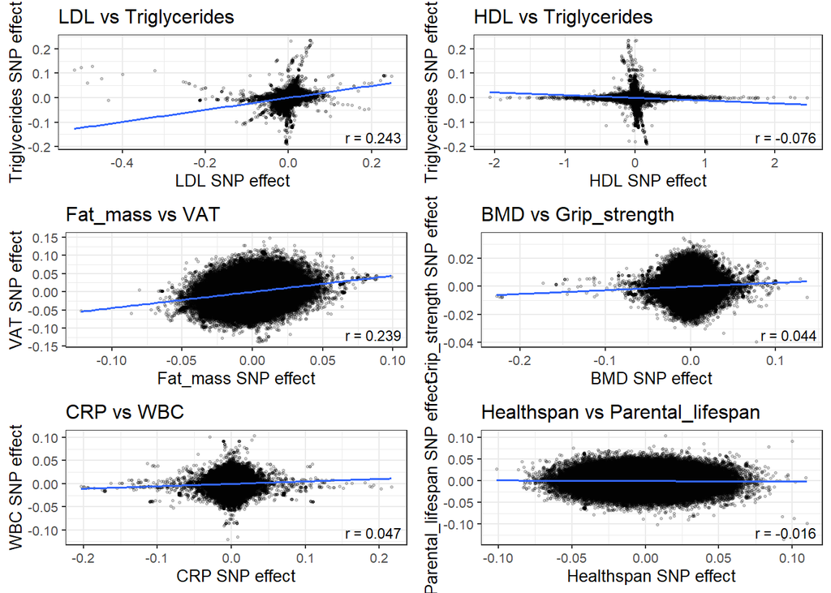

```r
#============================================================
# SNP-level concordance sanity plots across biological axes
#============================================================

library(ggplot2)
library(dplyr)
library(gridExtra)

#------------------------------------------------------------
# Define biologically related trait pairs
#------------------------------------------------------------

pairs <- list(
  c("LDL", "Triglycerides"),
  c("HDL", "Triglycerides"),
  c("Fat_mass", "VAT"),
  c("BMD", "Grip_strength"),
  c("CRP", "WBC"),
  c("Healthspan", "Parental_lifespan")
)

#------------------------------------------------------------
# Plot helper
#------------------------------------------------------------

make_scatter <- function(t1, t2) {

  df <- data.frame(
    x = gwas_list_final[[t1]]$BETA,
    y = gwas_list_final[[t2]]$BETA
  )

  r <- round(cor(df$x, df$y, use = "complete.obs"), 3)

  ggplot(df, aes(x, y)) +
    geom_point(alpha = 0.2, size = 0.6) +
    geom_smooth(method = "lm", se = FALSE, linewidth = 0.6) +
    annotate(
      "text",
      x = Inf, y = -Inf,
      label = paste("r =", r),
      hjust = 1.1, vjust = -0.6,
      size = 3
    ) +
    labs(
      title = paste(t1, "vs", t2),
      x = paste(t1, "SNP effect"),
      y = paste(t2, "SNP effect")
    ) +
    theme_bw(base_size = 10)
}

#------------------------------------------------------------
# Generate all plots
#------------------------------------------------------------

plots <- lapply(pairs, function(p) {
  make_scatter(p[1], p[2])
})

#------------------------------------------------------------
# Display as grid (nice compact QC panel)
#------------------------------------------------------------

gridExtra::grid.arrange(grobs = plots, ncol = 2)
```

```r
# SNP retention rates by trait - Detect traits that “lost too much” during harmonization.

#retention <- sapply(gwas_list_final, nrow) /
#             sapply(gwas_list, nrow)

#summary(retention)



#retention_per_trait <- data.frame(
#  trait = names(gwas_list),
#  n_snps_before = sapply(gwas_list, nrow),
#  n_snps_final  = sapply(gwas_list_final, nrow)
#)

#retention_per_trait$retention_fraction <-
#  retention_per_trait$n_snps_final / retention_per_trait$n_snps_before

#retention_per_trait$retention_percent <-
#  100 * retention_per_trait$retention_fraction

#retention_per_trait <- retention_per_trait[
#  order(retention_per_trait$retention_fraction),
#]

#print(retention_per_trait)




#============================================================
# Allele flip / sign concordance audit across related traits
#============================================================

library(dplyr)
library(knitr)
library(kableExtra)

#------------------------------------------------------------
# Define trait pairs and expected sign relationship
# expected = "opposite" or "same"
#------------------------------------------------------------

sign_pairs <- data.frame(
  trait_1 = c("HDL", "LDL", "Fat_mass", "CRP", "Healthspan"),
  trait_2 = c("LDL", "Triglycerides", "VAT", "WBC", "Parental_lifespan"),
  expected = c("opposite", "same", "same", "same", "same"),
  stringsAsFactors = FALSE
)

#------------------------------------------------------------
# Compute sign concordance
#------------------------------------------------------------

sign_results <- bind_rows(
  lapply(seq_len(nrow(sign_pairs)), function(i) {

    t1 <- sign_pairs$trait_1[i]
    t2 <- sign_pairs$trait_2[i]
    expected <- sign_pairs$expected[i]

    s1 <- sign(gwas_list_final[[t1]]$BETA)
    s2 <- sign(gwas_list_final[[t2]]$BETA)

    same_dir <- s1 == s2

    pct_same <- mean(same_dir, na.rm = TRUE) * 100
    pct_opp  <- 100 - pct_same

    data.frame(
      trait_1 = t1,
      trait_2 = t2,
      expected_pattern = expected,
      percent_same_direction = round(pct_same, 2),
      percent_opposite_direction = round(pct_opp, 2),
      observed_matches_expectation = ifelse(
        (expected == "same" & pct_same > 50) |
        (expected == "opposite" & pct_opp > 50),
        "Yes",
        "Check"
      )
    )
  })
)

#------------------------------------------------------------
# Render QC table
#------------------------------------------------------------

kbl(
  sign_results,
  caption = "Allele sign concordance audit across biologically related traits"
) %>%
  kable_styling(
    full_width = FALSE,
    bootstrap_options = c("striped", "hover")
  )
```

Allele sign concordance audit across biologically related traits

| trait_1 | trait_2 | expected_pattern | percent_same_direction | percent_opposite_direction | observed_matches_expectation |
| --- | --- | --- | --- | --- | --- |
| HDL | LDL | opposite | 49.05 | 50.95 | Yes |
| LDL | Triglycerides | same | 58.40 | 41.60 | Yes |
| Fat_mass | VAT | same | 58.58 | 41.42 | Yes |
| CRP | WBC | same | 51.19 | 48.81 | Yes |
| Healthspan | Parental_lifespan | same | 49.65 | 50.35 | Check |

```r
#------------------------------------------------------------
# MR column audit: what do we actually have?
#------------------------------------------------------------

library(dplyr)
library(knitr)
library(kableExtra)

mr_columns_check <- data.frame(
  trait = names(gwas_list_final),
  SNP  = sapply(gwas_list_final, function(df) "SNP"  %in% names(df)),
  EA   = sapply(gwas_list_final, function(df) "EA"   %in% names(df)),
  OA   = sapply(gwas_list_final, function(df) "OA"   %in% names(df)),
  BETA = sapply(gwas_list_final, function(df) "BETA" %in% names(df)),
  SE   = sapply(gwas_list_final, function(df) "SE"   %in% names(df)),
  EAF  = sapply(gwas_list_final, function(df) "EAF"  %in% names(df)),
  N    = sapply(gwas_list_final, function(df) "N"    %in% names(df))
)

# Convert TRUE/FALSE to ✓ ✗ for readability
mr_columns_pretty <- mr_columns_check %>%
  mutate(across(-trait, ~ ifelse(.x, "✓", "✗")))

kbl(
  mr_columns_pretty,
  caption = "Availability of required MR input fields across harmonized GWAS traits"
) %>%
  kable_styling(full_width = FALSE) %>%
  scroll_box(height = "400px")
```

Availability of required MR input fields across harmonized GWAS traits

|  | trait | SNP | EA | OA | BETA | SE | EAF | N |
| --- | --- | --- | --- | --- | --- | --- | --- | --- |
| Acc_L5_inactivity | Acc_L5_inactivity | ✓ | ✓ | ✓ | ✓ | ✓ | ✓ | ✗ |
| Acc_LIPA | Acc_LIPA | ✓ | ✓ | ✓ | ✓ | ✓ | ✓ | ✗ |
| Acc_MVPA | Acc_MVPA | ✓ | ✓ | ✓ | ✓ | ✓ | ✓ | ✗ |
| Acc_relative_amplitude | Acc_relative_amplitude | ✓ | ✓ | ✓ | ✓ | ✓ | ✓ | ✗ |
| Acc_total_log | Acc_total_log | ✓ | ✓ | ✓ | ✓ | ✓ | ✓ | ✗ |
| BMD | BMD | ✓ | ✓ | ✓ | ✓ | ✓ | ✓ | ✗ |
| Chronotype | Chronotype | ✓ | ✓ | ✓ | ✓ | ✓ | ✓ | ✗ |
| CRF_slope | CRF_slope | ✓ | ✓ | ✓ | ✓ | ✓ | ✓ | ✗ |
| CRF_VO2max | CRF_VO2max | ✓ | ✓ | ✓ | ✓ | ✓ | ✓ | ✗ |
| CRP | CRP | ✓ | ✓ | ✓ | ✓ | ✓ | ✓ | ✗ |
| Fat_free_mass | Fat_free_mass | ✓ | ✓ | ✓ | ✓ | ✓ | ✓ | ✗ |
| Fat_mass | Fat_mass | ✓ | ✓ | ✓ | ✓ | ✓ | ✓ | ✗ |
| FEV1 | FEV1 | ✓ | ✓ | ✓ | ✓ | ✓ | ✓ | ✗ |
| Grip_strength | Grip_strength | ✓ | ✓ | ✓ | ✓ | ✓ | ✓ | ✗ |
| HbA1c | HbA1c | ✓ | ✓ | ✓ | ✓ | ✓ | ✓ | ✗ |
| HDL | HDL | ✓ | ✓ | ✓ | ✓ | ✓ | ✓ | ✗ |
| Healthspan | Healthspan | ✓ | ✓ | ✓ | ✓ | ✓ | ✓ | ✗ |
| LDL | LDL | ✓ | ✓ | ✓ | ✓ | ✓ | ✓ | ✗ |
| Leisure_Screen_t | Leisure_Screen_t | ✓ | ✓ | ✓ | ✓ | ✓ | ✓ | ✗ |
| Parental_lifespan | Parental_lifespan | ✓ | ✓ | ✓ | ✓ | ✓ | ✓ | ✗ |
| Resting_heart_rate | Resting_heart_rate | ✓ | ✓ | ✓ | ✓ | ✓ | ✓ | ✗ |
| Self_MVPA | Self_MVPA | ✓ | ✓ | ✓ | ✓ | ✓ | ✓ | ✗ |
| Smoking_initiation | Smoking_initiation | ✓ | ✓ | ✓ | ✓ | ✓ | ✓ | ✗ |
| Sugar_intake | Sugar_intake | ✓ | ✓ | ✓ | ✓ | ✓ | ✓ | ✗ |
| Triglycerides | Triglycerides | ✓ | ✓ | ✓ | ✓ | ✓ | ✓ | ✗ |
| Usual_walking_pace | Usual_walking_pace | ✓ | ✓ | ✓ | ✓ | ✓ | ✓ | ✗ |
| VAT | VAT | ✓ | ✓ | ✓ | ✓ | ✓ | ✓ | ✗ |
| Walking_days | Walking_days | ✓ | ✓ | ✓ | ✓ | ✓ | ✓ | ✗ |
| Walking_time | Walking_time | ✓ | ✓ | ✓ | ✓ | ✓ | ✓ | ✗ |
| WBC | WBC | ✓ | ✓ | ✓ | ✓ | ✓ | ✓ | ✗ |
| WC_adjBMI | WC_adjBMI | ✓ | ✓ | ✓ | ✓ | ✓ | ✓ | ✗ |
| WHR_adjBMI | WHR_adjBMI | ✓ | ✓ | ✓ | ✓ | ✓ | ✓ | ✗ |

```r
field_summary <- colSums(mr_columns_check[,-1])

kbl(
  data.frame(
    field = names(field_summary),
    traits_with_field = field_summary,
    total_traits = nrow(mr_columns_check)
  ),
  caption = "Summary of MR field availability across traits"
) %>%
  kable_styling(full_width = FALSE)
```

Summary of MR field availability across traits

|  | field | traits_with_field | total_traits |
| --- | --- | --- | --- |
| SNP | SNP | 32 | 32 |
| EA | EA | 32 | 32 |
| OA | OA | 32 | 32 |
| BETA | BETA | 32 | 32 |
| SE | SE | 32 | 32 |
| EAF | EAF | 32 | 32 |
| N | N | 0 | 32 |

```r
rm(gwas_list_final)
gc(TRUE)
```

```
         used   (Mb) gc trigger    (Mb)   max used    (Mb)
```

Ncells 19595642 1046.6 31811610 1699.0 23961954 1279.8 Vcells 1042249461 7951.8 2280176333 17396.4 2279321158 17389.9

# 9. Pre-MR Column Availability Audit and Instrument Metadata Verification

Raw GWAS files are systematically scanned to determine the availability and original naming of standard errors, allele frequencies, and sample size fields required for Mendelian Randomization analyses.

## 9.1 Detection and validation of SE, EAF, and sample size fields across GWAS files

Header-level audits identify which datasets contain SE, EAF, and N information, map original column names to standardized fields, and preview representative values to ensure numeric plausibility prior to MR modeling.

```r
#============================================================
# PRE-MR AUDIT — Check raw files for SE / EAF / N availability
#============================================================

mr_aliases <- list(
  SE  = c("se", "SE", "stderr", "std_error", "standard_error", "sebeta"),
  EAF = c("eaf", "EAF", "effect_allele_freq", "effect_allele_frequency", "freq1", "af", "A1FREQ", "ALT_FREQ"),
  N   = c("n", "N", "samplesize", "sample_size", "N_total", "TOTAL_N", "Neff", "effective_n")
)

# helper: robust header split for tab/space-delimited files
read_header_cols <- function(f) {
  h <- readLines(f, n = 1, warn = FALSE)
  if (length(h) == 0) return(character(0))
  cols <- strsplit(h, "[\t ]+")[[1]]
  cols[cols != ""]
}

audit_one_file <- function(f) {
  cols <- read_header_cols(f)
  cols_lc <- tolower(cols)

  has <- sapply(mr_aliases, function(keys) {
    any(tolower(keys) %in% cols_lc)
  })

  # which exact matches (useful for mapping)
  matched <- lapply(names(mr_aliases), function(k) {
    keys <- tolower(mr_aliases[[k]])
    cols[tolower(cols) %in% keys]
  })
  names(matched) <- names(mr_aliases)

  data.frame(
    file = basename(f),
    has_SE  = has["SE"],
    has_EAF = has["EAF"],
    has_N   = has["N"],
    SE_cols  = ifelse(length(matched$SE)  == 0, "", paste(matched$SE,  collapse = ",")),
    EAF_cols = ifelse(length(matched$EAF) == 0, "", paste(matched$EAF, collapse = ",")),
    N_cols   = ifelse(length(matched$N)   == 0, "", paste(matched$N,   collapse = ",")),
    stringsAsFactors = FALSE
  )
}

# Run audit on both groups
mr_audit_accel <- do.call(rbind, lapply(files_accel, audit_one_file))
mr_audit_other <- do.call(rbind, lapply(files_other, audit_one_file))

mr_audit <- rbind(
  transform(mr_audit_accel, group = "Accelerometry"),
  transform(mr_audit_other, group = "Other")
)

# Summaries
library(dplyr)
library(knitr)
library(kableExtra)

mr_audit_pretty <- mr_audit %>%
  mutate(
    SE  = ifelse(has_SE,  "✓", "✗"),
    EAF = ifelse(has_EAF, "✓", "✗"),
    N   = ifelse(has_N,   "✓", "✗")
  ) %>%
  select(
    group,
    file,
    SE, EAF, N,
    SE_cols, EAF_cols, N_cols
  )

kbl(
  mr_audit_pretty,
  caption = "Raw GWAS file audit for availability of SE, EAF, and sample size fields"
) %>%
  kable_styling(full_width = FALSE) %>%
  scroll_box(height = "450px")
```

Raw GWAS file audit for availability of SE, EAF, and sample size fields

|  | group | file | SE | EAF | N | SE_cols | EAF_cols | N_cols |
| --- | --- | --- | --- | --- | --- | --- | --- | --- |
| SE | Accelerometry | GCST90104341_MVPA.tsv | ✓ | ✓ | ✓ | standard_error | effect_allele_frequency | SampleSize |
| SE32 | Other | GCST006979-heel bone mineral density.txt.txt | ✓ | ✓ | ✓ | SE | EAF | N |
| SE1 | Other | GCST007474_smoking_initiation.txt | ✓ | ✓ | ✓ | SE | AF | N,EFFECTIVE_N |
| SE2 | Other | GCST007576-chronotype.txt.txt | ✓ | ✓ | ✗ | SE | A1FREQ |  |
| SE3 | Other | GCST007609_resting_heart_rate.assoc | ✓ | ✗ | ✗ | SE |  |  |
| SE4 | Other | GCST008999_WHRadjBMI.tbl | ✓ | ✓ | ✗ | StdErr | Freq1 |  |
| SE5 | Other | GCST90016671-visceral fat.tsv | ✓ | ✓ | ✗ | standard_error | effect_allele_frequency |  |
| SE6 | Other | GCST90044317_sugar_intake.tsv | ✓ | ✓ | ✓ | standard_error | effect_allele_frequency | N |
| SE7 | Other | GCST90061408_acc_total_log.tsv | ✓ | ✓ | ✗ | standard_error | effect_allele_frequency |  |
| SE8 | Other | GCST90061421_acc_LIPA.tsv | ✓ | ✓ | ✗ | standard_error | effect_allele_frequency |  |
| SE9 | Other | GCST90061422_acc_MVPA.tsv | ✓ | ✓ | ✗ | standard_error | effect_allele_frequency |  |
| SE10 | Other | GCST90061431_acc_L5_inactivity.tsv | ✓ | ✓ | ✗ | standard_error | effect_allele_frequency |  |
| SE11 | Other | GCST90061432_acc_relative_amplitude.tsv | ✓ | ✓ | ✗ | standard_error | effect_allele_frequency |  |
| SE12 | Other | GCST90093316-cardiorespiratory fitness VO2max.tsv | ✓ | ✓ | ✗ | standard_error | effect_allele_frequency |  |
| SE13 | Other | GCST90093319-cardiorespiratory fitness slope.tsv | ✓ | ✓ | ✗ | standard_error | effect_allele_frequency |  |
| SE14 | Other | GCST90104339-leasure time.tsv | ✓ | ✓ | ✓ | standard_error | effect_allele_frequency | SampleSize |
| SE15 | Other | GCST90104341_self_MVPA.tsv | ✓ | ✓ | ✓ | standard_error | effect_allele_frequency | SampleSize |
| SE16 | Other | GCST90179146-C-reactive protein levels.tsv | ✓ | ✓ | ✗ | standard_error | effect_allele_frequency |  |
| SE17 | Other | GCST90239652-HDL cholesterol levels.tsv | ✓ | ✓ | ✓ | standard_error | effect_allele_frequency | n |
| SE18 | Other | GCST90239658-LDL cholesterol levels.tsv | ✓ | ✓ | ✓ | standard_error | effect_allele_frequency | n |
| SE19 | Other | GCST90239664-triglyceride levels.tsv | ✓ | ✓ | ✓ | standard_error | effect_allele_frequency | n |
| SE20 | Other | GCST90302892_WCadjBMI.tsv | ✓ | ✓ | ✓ | standard_error | effect_allele_frequency | N |
| SE21 | Other | GCST90468164-walk time.tsv | ✓ | ✓ | ✓ | standard_error | effect_allele_frequency | n |
| SE22 | Other | GCST90565845-hand grip strength baseline.tsv | ✓ | ✓ | ✓ | standard_error | effect_allele_frequency | n |
| SE23 | Other | GCST90691576-glycated hemoglobin.tsv | ✓ | ✓ | ✗ | standard_error | effect_allele_frequency |  |
| SE24 | Other | GCST90691840_FEV1.tsv | ✓ | ✓ | ✗ | standard_error | effect_allele_frequency |  |
| SE25 | Other | GCST90691882-walk days.tsv | ✓ | ✓ | ✗ | standard_error | effect_allele_frequency |  |
| SE26 | Other | GCST90692657-whole body fat mass.tsv | ✓ | ✓ | ✗ | standard_error | effect_allele_frequency |  |
| SE27 | Other | GCST90692693-whole body fat free mass.tsv | ✓ | ✓ | ✗ | standard_error | effect_allele_frequency |  |
| SE28 | Other | GCST90692919-white blood cell count.tsv | ✓ | ✓ | ✗ | standard_error | effect_allele_frequency |  |
| SE29 | Other | GCST007406-healthspan.tsv | ✓ | ✓ | ✗ | standard_error | effect_allele_frequency |  |
| SE30 | Other | GCST009890-parental lifespan.tsv | ✓ | ✓ | ✓ | se | freq1 | n |
| SE31 | Other | GCST90693086-usual walking pace.tsv | ✓ | ✓ | ✗ | standard_error | effect_allele_frequency |  |

```r
cat("\n✅ Files with SE:",  sum(mr_audit$has_SE),  "/", nrow(mr_audit), "\n")
```

✅ Files with SE: 33 / 33

```r
cat("✅ Files with EAF:", sum(mr_audit$has_EAF), "/", nrow(mr_audit), "\n")
```

✅ Files with EAF: 32 / 33

```r
cat("✅ Files with N:",   sum(mr_audit$has_N),   "/", nrow(mr_audit), "\n")
```

✅ Files with N: 13 / 33

```r
#============================================================
# EXACT COLUMN NAME AUDIT — SE / EAF / N (per trait)
#============================================================

mr_aliases <- list(
  SE  = c("se", "SE", "stderr", "standard_error", "std_error", "sebeta"),
  EAF = c("eaf", "EAF", "effect_allele_frequency", "effect_allele_freq",
          "af", "freq1", "a1freq", "alt_freq"),
  N   = c("n", "N", "samplesize", "sample_size", "neff", "total_n")
)

read_header_cols <- function(f) {
  h <- readLines(f, n = 1, warn = FALSE)
  if (length(h) == 0) return(character(0))
  cols <- strsplit(h, "[\t ]+")[[1]]
  cols[cols != ""]
}

find_original_cols <- function(f) {

  cols <- read_header_cols(f)
  cols_lc <- tolower(cols)

  find_match <- function(keys) {
    idx <- match(tolower(keys), cols_lc, nomatch = 0)
    if (all(idx == 0)) return(NA_character_)
    cols[idx[idx > 0][1]]   # return FIRST match, original name
  }

  data.frame(
    file  = basename(f),
    trait = unname(trait_mapping[basename(f)]),
    SE_col  = find_match(mr_aliases$SE),
    EAF_col = find_match(mr_aliases$EAF),
    N_col   = find_match(mr_aliases$N),
    stringsAsFactors = FALSE
  )
}

#------------------------------------------------------------
# Run audit on all GWAS files
#------------------------------------------------------------

mr_column_map <- do.call(
  rbind,
  lapply(c(files_accel, files_other), find_original_cols)
)

# Order nicely
mr_column_map <- mr_column_map[
  order(mr_column_map$trait),
]

library(dplyr)
library(knitr)
library(kableExtra)

mr_column_map_pretty <- mr_column_map %>%
  mutate(
    SE_col  = ifelse(is.na(SE_col),  "—", SE_col),
    EAF_col = ifelse(is.na(EAF_col), "—", EAF_col),
    N_col   = ifelse(is.na(N_col),   "—", N_col)
  )

kbl(
  mr_column_map_pretty,
  caption = "Original column names mapped to standardized SE, EAF, and sample size fields across GWAS sources"
) %>%
  kable_styling(full_width = FALSE) %>%
  scroll_box(height = "450px")
```

Original column names mapped to standardized SE, EAF, and sample size fields across GWAS sources

|  | file | trait | SE_col | EAF_col | N_col |
| --- | --- | --- | --- | --- | --- |
| 12 | GCST90061431_acc_L5_inactivity.tsv | Acc_L5_inactivity | standard_error | effect_allele_frequency | — |
| 10 | GCST90061421_acc_LIPA.tsv | Acc_LIPA | standard_error | effect_allele_frequency | — |
| 11 | GCST90061422_acc_MVPA.tsv | Acc_MVPA | standard_error | effect_allele_frequency | — |
| 13 | GCST90061432_acc_relative_amplitude.tsv | Acc_relative_amplitude | standard_error | effect_allele_frequency | — |
| 9 | GCST90061408_acc_total_log.tsv | Acc_total_log | standard_error | effect_allele_frequency | — |
| 2 | GCST006979-heel bone mineral density.txt.txt | BMD | SE | EAF | N |
| 4 | GCST007576-chronotype.txt.txt | Chronotype | SE | A1FREQ | — |
| 15 | GCST90093319-cardiorespiratory fitness slope.tsv | CRF_slope | standard_error | effect_allele_frequency | — |
| 14 | GCST90093316-cardiorespiratory fitness VO2max.tsv | CRF_VO2max | standard_error | effect_allele_frequency | — |
| 18 | GCST90179146-C-reactive protein levels.tsv | CRP | standard_error | effect_allele_frequency | — |
| 29 | GCST90692693-whole body fat free mass.tsv | Fat_free_mass | standard_error | effect_allele_frequency | — |
| 28 | GCST90692657-whole body fat mass.tsv | Fat_mass | standard_error | effect_allele_frequency | — |
| 26 | GCST90691840_FEV1.tsv | FEV1 | standard_error | effect_allele_frequency | — |
| 24 | GCST90565845-hand grip strength baseline.tsv | Grip_strength | standard_error | effect_allele_frequency | n |
| 25 | GCST90691576-glycated hemoglobin.tsv | HbA1c | standard_error | effect_allele_frequency | — |
| 19 | GCST90239652-HDL cholesterol levels.tsv | HDL | standard_error | effect_allele_frequency | n |
| 31 | GCST007406-healthspan.tsv | Healthspan | standard_error | effect_allele_frequency | — |
| 20 | GCST90239658-LDL cholesterol levels.tsv | LDL | standard_error | effect_allele_frequency | n |
| 16 | GCST90104339-leasure time.tsv | Leisure_Screen_t | standard_error | effect_allele_frequency | SampleSize |
| 1 | GCST90104341_MVPA.tsv | MVPA | standard_error | effect_allele_frequency | SampleSize |
| 32 | GCST009890-parental lifespan.tsv | Parental_lifespan | se | freq1 | n |
| 5 | GCST007609_resting_heart_rate.assoc | Resting_heart_rate | SE | — | — |
| 17 | GCST90104341_self_MVPA.tsv | Self_MVPA | standard_error | effect_allele_frequency | SampleSize |
| 3 | GCST007474_smoking_initiation.txt | Smoking_initiation | SE | AF | N |
| 8 | GCST90044317_sugar_intake.tsv | Sugar_intake | standard_error | effect_allele_frequency | N |
| 21 | GCST90239664-triglyceride levels.tsv | Triglycerides | standard_error | effect_allele_frequency | n |
| 33 | GCST90693086-usual walking pace.tsv | Usual_walking_pace | standard_error | effect_allele_frequency | — |
| 7 | GCST90016671-visceral fat.tsv | VAT | standard_error | effect_allele_frequency | — |
| 27 | GCST90691882-walk days.tsv | Walking_days | standard_error | effect_allele_frequency | — |
| 23 | GCST90468164-walk time.tsv | Walking_time | standard_error | effect_allele_frequency | n |
| 30 | GCST90692919-white blood cell count.tsv | WBC | standard_error | effect_allele_frequency | — |
| 22 | GCST90302892_WCadjBMI.tsv | WC_adjBMI | standard_error | effect_allele_frequency | N |
| 6 | GCST008999_WHRadjBMI.tbl | WHR_adjBMI | StdErr | Freq1 | — |

```r
#============================================================
# PREVIEW SE & EAF VALUES — first rows per trait
#============================================================

library(data.table)

preview_se_eaf <- function(f, se_col, eaf_col, n = 5) {

  cols_to_read <- na.omit(c(se_col, eaf_col))
  if (length(cols_to_read) == 0) return(data.frame())

  df <- fread(
    f,
    select = cols_to_read,
    nrows = n,
    showProgress = FALSE
  )

  # Standardize names for display
  if (!is.na(se_col) && se_col %in% names(df)) {
    setnames(df, se_col, "SE")
  }
  if (!is.na(eaf_col) && eaf_col %in% names(df)) {
    setnames(df, eaf_col, "EAF")
  }

  as.data.frame(df)
}








#============================================================
# RUN PREVIEW FOR ALL TRAITS
#============================================================

se_eaf_preview <- lapply(seq_len(nrow(mr_column_map)), function(i) {

  row <- mr_column_map[i, ]

  f <- c(files_accel, files_other)[
    basename(c(files_accel, files_other)) == row$file
  ]

  out <- preview_se_eaf(
    f      = f,
    se_col = row$SE_col,
    eaf_col = row$EAF_col,
    n = 5
  )

  if (nrow(out) == 0) return(NULL)

  out$trait <- row$trait
  out
})

names(se_eaf_preview) <- mr_column_map$trait


#============================================================
# COMBINE SE & EAF PREVIEW INTO ONE TABLE (non-PA traits)
#============================================================

library(dplyr)
library(knitr)
library(kableExtra)

se_eaf_table <- bind_rows(
  lapply(names(se_eaf_preview), function(tr) {

    df <- se_eaf_preview[[tr]]
    if (is.null(df)) return(NULL)

    df %>%
      mutate(
        trait = tr,
        SNP_row = row_number()
      ) %>%
      select(trait, SNP_row, everything())
  })
)

kbl(
  se_eaf_table,
  digits = 4,
  caption = "Representative SE and EAF values extracted from raw GWAS summary statistics"
) %>%
  kable_styling(full_width = FALSE) %>%
  scroll_box(height = "400px")
```

Representative SE and EAF values extracted from raw GWAS summary statistics

| trait | SNP_row | SE | EAF |
| --- | --- | --- | --- |
| Acc_L5_inactivity | 1 | 0.0083 | 0.9063 |
| Acc_L5_inactivity | 2 | 0.0221 | 0.9887 |
| Acc_L5_inactivity | 3 | 0.0117 | 0.9562 |
| Acc_L5_inactivity | 4 | 0.0075 | 0.8887 |
| Acc_L5_inactivity | 5 | 0.0075 | 0.8888 |
| Acc_LIPA | 1 | 0.0084 | 0.9063 |
| Acc_LIPA | 2 | 0.0222 | 0.9887 |
| Acc_LIPA | 3 | 0.0117 | 0.9562 |
| Acc_LIPA | 4 | 0.0076 | 0.8887 |
| Acc_LIPA | 5 | 0.0076 | 0.8888 |
| Acc_MVPA | 1 | 0.0082 | 0.9063 |
| Acc_MVPA | 2 | 0.0218 | 0.9887 |
| Acc_MVPA | 3 | 0.0115 | 0.9562 |
| Acc_MVPA | 4 | 0.0074 | 0.8887 |
| Acc_MVPA | 5 | 0.0074 | 0.8888 |
| Acc_relative_amplitude | 1 | 0.0082 | 0.9063 |
| Acc_relative_amplitude | 2 | 0.0217 | 0.9887 |
| Acc_relative_amplitude | 3 | 0.0115 | 0.9562 |
| Acc_relative_amplitude | 4 | 0.0074 | 0.8887 |
| Acc_relative_amplitude | 5 | 0.0074 | 0.8888 |
| Acc_total_log | 1 | 0.0083 | 0.9063 |
| Acc_total_log | 2 | 0.0220 | 0.9887 |
| Acc_total_log | 3 | 0.0116 | 0.9562 |
| Acc_total_log | 4 | 0.0075 | 0.8887 |
| Acc_total_log | 5 | 0.0075 | 0.8888 |
| BMD | 1 | 0.0182 | 0.9916 |
| BMD | 2 | 0.0517 | 0.9995 |
| BMD | 3 | 0.0564 | 0.9994 |
| BMD | 4 | 0.0482 | 0.9994 |
| BMD | 5 | 0.0326 | 0.9978 |

[output cut: 135 more lines]

# 10. Construction of Analysis Matrices and Memory Optimization

## 10.1 Elastic Net Predictor Matrix Construction (Memory-Optimized)

```r
gwas_list_final <- readRDS("gwas_list_final.rds")


gwas_list_final <- lapply(gwas_list_final, function(df) {
  df[, BETA := as.numeric(BETA)]
  df
})
gc(TRUE)


#============================================================
# FINAL MATRICES IN MEMORY (NO EXCEL, NO DISK)
#============================================================

library(dplyr)
library(tidyr)

#------------------------------------------------------------
# Reference SNP order
#------------------------------------------------------------

snps <- gwas_list_final[[1]]$SNP
traits <- names(gwas_list_final)

#============================================================
# 1. ELASTIC NET MATRIX (SNPs × Traits)
#============================================================

X_elastic_net <- matrix(
  NA_real_,
  nrow = length(snps),
  ncol = length(traits),
  dimnames = list(snps, traits)
)

for (j in seq_along(traits)) {

  tr <- traits[j]
  df <- gwas_list_final[[tr]]

  # Enforce SNP order
  df <- df[match(snps, df$SNP), ]
  stopifnot(identical(df$SNP, snps))

  X_elastic_net[, j] <- df$BETA
  rm(df)
}

# Hard QC
stopifnot(!anyNA(X_elastic_net))

cat("✅ Elastic Net matrix created:",
    nrow(X_elastic_net), "SNPs ×",
    ncol(X_elastic_net), "traits\n")






#============================================================
# MEMORY AUDIT — objects ordered by size
#============================================================

obj_sizes <- sapply(ls(envir = .GlobalEnv), function(x) {
  object.size(get(x, envir = .GlobalEnv))
})

obj_sizes_df <- data.frame(
  object = names(obj_sizes),
  size_MB = as.numeric(obj_sizes) / 1024^2,
  stringsAsFactors = FALSE
)

obj_sizes_df <- obj_sizes_df[
  order(obj_sizes_df$size_MB, decreasing = TRUE),
]

print(obj_sizes_df, row.names = FALSE)







saveRDS(gwas_list_final, file = "gwas_list_final.rds")

rm(gwas_list_final)
gc(TRUE)

rm(
  accel_snps,
  pa_snps,
  common_snps,
  snps,
  snps_ref
)
gc(TRUE)


saveRDS(X_elastic_net, file = "X_elastic_net.rds")
```

# 11. MR Dataset Preprocessing and Full-SNP Integrity Validation

This section validates the harmonized GWAS datasets under two complementary analytical frameworks. For Elastic Net modeling (Section 11.1), all traits are restricted to a shared SNP universe with identical ordering and balanced representation across phenotypes to ensure matrix compatibility, numerical stability, and reproducible multivariate modeling. For Mendelian Randomization (Section 11.2), integrity checks are performed directly on the full mapped SNP sets without enforcing cross-trait equality, preserving exposure-specific genetic architecture while validating structural completeness, numeric consistency, and rsID formatting prior to instrument selection.

## 11.1 Integrity checks, allele-frequency screening, and clean Elastic Net input generation

This subsection confirms that all final harmonized GWAS traits share an identical SNP universe and consistent ordering, ensuring compatibility for dense SNP × trait matrix construction. SNP alignment, missing value audits, effect size validation, and allele-field completeness checks are performed to guarantee that the Elastic Net predictor matrix is free of structural inconsistencies before multivariate modeling.

```r
#============================================================
# SECTION 11.1 — Elastic Net Integrity & Harmonization Audit
# (Disk-based, memory safe)
#============================================================

library(dplyr)
library(knitr)
library(kableExtra)

final_dir <- file.path(out_dir, "final_harmonized_traits")

final_trait_files <- list.files(
  final_dir,
  pattern = "^final_.*\\.rds$",
  full.names = TRUE
)

trait_names <- gsub("final_|\\.rds", "", basename(final_trait_files))


############################################################
# FIX SNP ORDERING IN FINAL TRAIT FILES (ONE-TIME PATCH)
############################################################

common_snps <- readRDS(file.path(out_dir, "common_snps_universe.rds"))

final_trait_files <- list.files(
  final_dir,
  pattern = "^final_.*\\.rds$",
  full.names = TRUE
)

for (f in final_trait_files) {

  df <- readRDS(f)

  # Restrict (safety) + enforce order
  df <- df[df$SNP %in% common_snps, ]
  df <- df[match(common_snps, df$SNP), ]

  stopifnot(identical(df$SNP, common_snps))

  saveRDS(df, f)

  rm(df)
}

gc(TRUE)
```

```
        used   (Mb) gc trigger    (Mb)   max used    (Mb)
```

Ncells 19551686 1044.2 31811610 1699.0 23961954 1279.8 Vcells 886973776 6767.1 2280176333 17396.4 2279321158 17389.9

```r
cat("✅ SNP ordering enforced across all final harmonized traits\n\n")
```

✅ SNP ordering enforced across all final harmonized traits

```r
#------------------------------------------------------------
# 1️⃣ Global SNP universe consistency check
#------------------------------------------------------------

ref_df  <- readRDS(final_trait_files[1])
snps_ref <- ref_df$SNP
rm(ref_df)
gc(FALSE)
```

```
        used   (Mb) gc trigger    (Mb)   max used    (Mb)
```

Ncells 19551378 1044.2 31811610 1699.0 23961954 1279.8 Vcells 886877763 6766.4 2280176333 17396.4 2279321158 17389.9

```r
snp_consistency <- sapply(final_trait_files, function(f) {
  df <- readRDS(f)
  identical(df$SNP, snps_ref)
})

stopifnot(all(snp_consistency))

cat("✅ All traits share identical SNP universe\n")
```

✅ All traits share identical SNP universe

```r
#------------------------------------------------------------
# 2️⃣ Per-trait integrity summary (sequential, low memory)
#------------------------------------------------------------

qc_summary <- bind_rows(
  lapply(seq_along(final_trait_files), function(i) {

    df <- readRDS(final_trait_files[i])

    out <- data.frame(
      trait = trait_names[i],
      n_snps = nrow(df),
      missing_EA = sum(is.na(df$EA)),
      missing_OA = sum(is.na(df$OA)),
      missing_BETA = sum(is.na(df$BETA)),
      missing_SE = sum(is.na(df$SE)),
      missing_EAF = sum(is.na(df$EAF)),
      stringsAsFactors = FALSE
    )

    rm(df)
    gc(FALSE)

    out
  })
)

kbl(
  qc_summary,
  caption = "Integrity checks of harmonized MR-ready GWAS traits"
) %>%
  kable_styling(full_width = FALSE) %>%
  scroll_box(height = "400px")
```

Integrity checks of harmonized MR-ready GWAS traits

| trait | n_snps | missing_EA | missing_OA | missing_BETA | missing_SE | missing_EAF |
| --- | --- | --- | --- | --- | --- | --- |
| Acc_L5_inactivity | 2015535 | 0 | 0 | 0 | 0 | 0 |
| Acc_LIPA | 2015535 | 0 | 0 | 0 | 0 | 0 |
| Acc_MVPA | 2015535 | 0 | 0 | 0 | 0 | 0 |
| Acc_relative_amplitude | 2015535 | 0 | 0 | 0 | 0 | 0 |
| Acc_total_log | 2015535 | 0 | 0 | 0 | 0 | 0 |
| BMD | 2015535 | 0 | 2015535 | 0 | 0 | 0 |
| Chronotype | 2015535 | 0 | 0 | 0 | 0 | 0 |
| CRF_slope | 2015535 | 0 | 0 | 0 | 0 | 0 |
| CRF_VO2max | 2015535 | 0 | 0 | 0 | 0 | 0 |
| CRP | 2015535 | 0 | 0 | 0 | 0 | 0 |
| Fat_free_mass | 2015535 | 0 | 0 | 0 | 0 | 0 |
| Fat_mass | 2015535 | 0 | 0 | 0 | 0 | 0 |
| FEV1 | 2015535 | 0 | 0 | 0 | 0 | 0 |
| Grip_strength | 2015535 | 0 | 0 | 0 | 0 | 0 |
| HbA1c | 2015535 | 0 | 0 | 0 | 0 | 0 |
| HDL | 2015535 | 0 | 0 | 0 | 0 | 0 |
| Healthspan | 2015535 | 0 | 0 | 0 | 0 | 0 |
| LDL | 2015535 | 0 | 0 | 0 | 0 | 0 |
| Leisure_Screen_t | 2015535 | 0 | 0 | 0 | 0 | 0 |
| Parental_lifespan | 2015535 | 0 | 0 | 0 | 0 | 0 |
| Resting_heart_rate | 2015535 | 0 | 2015535 | 0 | 0 | 0 |
| Self_MVPA | 2015535 | 0 | 0 | 0 | 0 | 0 |
| Smoking_initiation | 2015535 | 0 | 0 | 0 | 0 | 0 |
| Sugar_intake | 2015535 | 0 | 0 | 0 | 0 | 0 |
| Triglycerides | 2015535 | 0 | 0 | 0 | 0 | 0 |
| Usual_walking_pace | 2015535 | 0 | 0 | 0 | 0 | 0 |
| VAT | 2015535 | 0 | 0 | 0 | 0 | 0 |
| Walking_days | 2015535 | 0 | 0 | 0 | 0 | 0 |
| Walking_time | 2015535 | 0 | 0 | 0 | 0 | 0 |
| WBC | 2015535 | 0 | 0 | 0 | 0 | 0 |
| WC_adjBMI | 2015535 | 0 | 0 | 0 | 0 | 0 |
| WHR_adjBMI | 2015535 | 0 | 0 | 0 | 0 | 0 |

```r
#------------------------------------------------------------
# 3️⃣ Balanced SNP coverage verification
#------------------------------------------------------------

stopifnot(length(unique(qc_summary$n_snps)) == 1)

cat("✅ All traits contain",
    unique(qc_summary$n_snps),
    "SNPs\n")
```

✅ All traits contain 2015535 SNPs

```r
############################################################
# 🔧 ONE-TIME TYPE FIX (PERMANENT)
############################################################

for (f in final_trait_files) {

  df <- readRDS(f)

  df$BETA <- as.numeric(df$BETA)
  if ("SE"  %in% names(df)) df$SE  <- as.numeric(df$SE)
  if ("EAF" %in% names(df)) df$EAF <- as.numeric(df$EAF)

  saveRDS(df, f)

  rm(df)
}

gc(TRUE)
```

```
        used   (Mb) gc trigger    (Mb)   max used    (Mb)
```

Ncells 19551845 1044.2 31811610 1699.0 23961954 1279.8 Vcells 886923948 6766.7 2280176333 17396.4 2279943687 17394.6

```r
cat("✅ Numeric types enforced in all final trait files\n\n")
```

✅ Numeric types enforced in all final trait files

```r
#------------------------------------------------------------
# 4️⃣ Small representative preview (first 2 SNPs per trait)
#------------------------------------------------------------

preview_list <- lapply(seq_along(final_trait_files), function(i) {

  df <- readRDS(final_trait_files[i])

  out <- df[1:2, ]
  out$trait <- trait_names[i]

  rm(df)
  gc(FALSE)

  out
})

preview <- bind_rows(preview_list)

kbl(
  preview,
  digits = 4,
  caption = "Representative SNP-level preview of MR input (per trait)"
) %>%
  kable_styling(full_width = FALSE) %>%
  scroll_box(height = "300px")
```

Representative SNP-level preview of MR input (per trait)

| SNP | EA | OA | BETA | SE | EAF | trait |
| --- | --- | --- | --- | --- | --- | --- |
| rs144155419 | G | A | 0.0093 | 0.0221 | 0.9887 | Acc_L5_inactivity |
| rs141242758 | T | C | -0.0010 | 0.0075 | 0.8888 | Acc_L5_inactivity |
| rs144155419 | G | A | 0.0225 | 0.0222 | 0.9887 | Acc_LIPA |
| rs141242758 | T | C | 0.0108 | 0.0076 | 0.8888 | Acc_LIPA |
| rs144155419 | G | A | 0.0080 | 0.0218 | 0.9887 | Acc_MVPA |
| rs141242758 | T | C | 0.0024 | 0.0074 | 0.8888 | Acc_MVPA |
| rs144155419 | G | A | 0.0039 | 0.0217 | 0.9887 | Acc_relative_amplitude |
| rs141242758 | T | C | 0.0035 | 0.0074 | 0.8888 | Acc_relative_amplitude |
| rs144155419 | G | A | 0.0260 | 0.0220 | 0.9887 | Acc_total_log |
| rs141242758 | T | C | 0.0081 | 0.0075 | 0.8888 | Acc_total_log |
| rs144155419 | G | NA | 0.0040 | 0.0081 | 0.9842 | BMD |
| rs141242758 | T | NA | 0.0034 | 0.0029 | 0.8790 | BMD |
| rs144155419 | G | A | -0.0129 | 0.0119 | 0.9841 | Chronotype |
| rs141242758 | T | C | 0.0027 | 0.0042 | 0.8787 | Chronotype |
| rs144155419 | G | A | 0.0010 | 0.0044 | 0.9833 | CRF_slope |
| rs141242758 | T | C | -0.0008 | 0.0016 | 0.8769 | CRF_slope |
| rs144155419 | G | A | -0.0163 | 0.0201 | 0.9833 | CRF_VO2max |
| rs141242758 | T | C | -0.0047 | 0.0073 | 0.8769 | CRF_VO2max |
| rs144155419 | A | G | -0.0028 | 0.0080 | 0.0161 | CRP |
| rs141242758 | T | C | 0.0011 | 0.0031 | 0.8751 | CRP |
| rs144155419 | A | G | 0.0024 | 0.0073 | 0.0156 | Fat_free_mass |
| rs141242758 | C | T | 0.0001 | 0.0025 | 0.1239 | Fat_free_mass |
| rs144155419 | A | G | -0.0032 | 0.0112 | 0.0156 | Fat_mass |
| rs141242758 | C | T | 0.0006 | 0.0038 | 0.1239 | Fat_mass |
| rs144155419 | A | G | 0.0049 | 0.0072 | 0.0158 | FEV1 |
| rs141242758 | C | T | -0.0052 | 0.0026 | 0.1209 | FEV1 |
| rs144155419 | G | A | -0.0028 | 0.0064 | 0.9843 | Grip_strength |
| rs141242758 | T | C | 0.0033 | 0.0023 | 0.8792 | Grip_strength |
| rs144155419 | A | G | 0.0121 | 0.0110 | 0.0158 | HbA1c |
| rs141242758 | C | T | -0.0026 | 0.0039 | 0.1208 | HbA1c |
| rs144155419 | A | G | 0.0080 | 0.0100 | 0.0126 | HDL |
| rs141242758 | C | T | 0.0020 | 0.0026 | 0.1230 | HDL |
| rs144155419 | A | G | 0.0313 | 0.0217 | 0.0160 | Healthspan |
| rs141242758 | C | T | 0.0084 | 0.0076 | 0.1200 | Healthspan |
| rs144155419 | A | G | 0.0027 | 0.0100 | 0.0129 | LDL |
| rs141242758 | C | T | -0.0014 | 0.0026 | 0.1250 | LDL |
| rs144155419 | a | g | 0.0167 | 0.0172 | 0.0159 | Leisure_Screen_t |
| rs141242758 | t | c | -0.0152 | 0.0061 | 0.8777 | Leisure_Screen_t |
| rs144155419 | A | G | -0.0043 | 0.0191 | 0.0197 | Parental_lifespan |
| rs141242758 | T | C | 0.0045 | 0.0067 | 0.8744 | Parental_lifespan |
| rs144155419 | G | NA | -0.0045 | 0.0978 | 0.0105 | Resting_heart_rate |
| rs141242758 | T | NA | -0.0069 | 0.0353 | 0.1123 | Resting_heart_rate |
| rs144155419 | a | g | 0.0053 | 0.0183 | 0.0158 | Self_MVPA |
| rs141242758 | t | c | -0.0006 | 0.0065 | 0.8782 | Self_MVPA |
| rs144155419 | A | G | 0.0069 | 0.0124 | 0.0152 | Smoking_initiation |
| rs141242758 | C | T | 0.0040 | 0.0035 | 0.1280 | Smoking_initiation |
| rs144155419 | A | G | 0.0190 | 0.0270 | 0.0105 | Sugar_intake |
| rs141242758 | C | T | -0.0055 | 0.0088 | 0.1112 | Sugar_intake |
| rs144155419 | A | G | -0.0196 | 0.0099 | 0.0128 | Triglycerides |
| rs141242758 | C | T | -0.0025 | 0.0026 | 0.1240 | Triglycerides |
| rs144155419 | A | G | 0.0094 | 0.0058 | 0.0158 | Usual_walking_pace |
| rs141242758 | C | T | 0.0006 | 0.0020 | 0.1211 | Usual_walking_pace |
| rs144155419 | A | G | -0.0373 | 0.0289 | 0.0162 | VAT |
| rs141242758 | C | T | 0.0021 | 0.0103 | 0.1225 | VAT |
| rs144155419 | A | G | -0.0277 | 0.0195 | 0.0158 | Walking_days |
| rs141242758 | C | T | -0.0067 | 0.0069 | 0.1210 | Walking_days |
| rs144155419 | A | G | -0.0048 | 0.0098 | 0.0155 | Walking_time |
| rs141242758 | C | T | 0.0002 | 0.0035 | 0.1206 | Walking_time |
| rs144155419 | A | G | -0.0007 | 0.0095 | 0.0157 | WBC |
| rs141242758 | C | T | -0.0031 | 0.0033 | 0.1222 | WBC |
| rs144155419 | G | A | 0.0051 | 0.0044 | 0.9843 | WC_adjBMI |
| rs141242758 | T | C | -0.0003 | 0.0016 | 0.8792 | WC_adjBMI |
| rs144155419 | a | g | -0.0029 | 0.0087 | 0.0161 | WHR_adjBMI |
| rs141242758 | t | c | -0.0055 | 0.0031 | 0.8752 | WHR_adjBMI |

```r
gc(TRUE)
```

```
        used   (Mb) gc trigger    (Mb)   max used    (Mb)
```

Ncells 19554366 1044.4 31811610 1699.0 23961954 1279.8 Vcells 887090618 6768.0 2280176333 17396.4 2279943687 17394.6

```r
############################################################
# 🔁 REBUILD COMBINED GWAS OBJECT (UPDATED + ORDERED)
############################################################

gwas_list_final <- lapply(final_trait_files, readRDS)
names(gwas_list_final) <- gsub("final_|\\.rds", "", basename(final_trait_files))

saveRDS(gwas_list_final, "gwas_list_final.rds")

rm(gwas_list_final)
gc(TRUE)
```

```
        used   (Mb) gc trigger    (Mb)   max used    (Mb)
```

Ncells 19554185 1044.4 31811610 1699.0 23961954 1279.8 Vcells 886954548 6767.0 2280176333 17396.4 2279943687 17394.6

```r
cat("✅ gwas_list_final.rds rebuilt with correct ordering and numeric types\n\n")
```

✅ gwas_list_final.rds rebuilt with correct ordering and numeric types

## 11.2 Integrity checks, allele-frequency screening, and clean MR input generation

This subsection validates the mapped GWAS datasets under a full SNP-universe framework suitable for trait-specific Mendelian Randomization. Unlike the Elastic Net branch, SNP equality across traits is not enforced. Instead, each trait is audited independently on disk to verify structural integrity, rsID formatting, numeric consistency of effect estimates, and exposure–outcome SNP overlap prior to instrument selection and causal inference.

```r
#============================================================
# SECTION 11.X — MR Integrity Audit (Full Mapped Traits)
# Disk-based | No shared SNP universe restriction
#============================================================

library(data.table)
library(dplyr)
library(knitr)
library(kableExtra)

mapped_dir <- file.path(out_dir, "mapped_full_traits")

mapped_trait_files <- list.files(
  mapped_dir,
  pattern = "^mapped_full_.*\\.rds$",
  full.names = TRUE
)

trait_names <- gsub("mapped_full_|\\.rds", "", basename(mapped_trait_files))

cat("🔎 Found", length(mapped_trait_files), "mapped_full traits\n\n")
```

🔎 Found 32 mapped_full traits

```r
#------------------------------------------------------------
# 1️⃣ Per-trait structural integrity audit
#------------------------------------------------------------

qc_summary <- bind_rows(
  lapply(seq_along(mapped_trait_files), function(i) {

    df <- readRDS(mapped_trait_files[i])

    out <- data.frame(
      trait = trait_names[i],
      n_snps = nrow(df),
      missing_SNP  = sum(is.na(df$SNP)),
      missing_EA   = sum(is.na(df$EA)),
      missing_OA   = sum(is.na(df$OA)),
      missing_BETA = sum(is.na(df$BETA)),
      missing_SE   = sum(is.na(df$SE)),
      missing_EAF  = if ("EAF" %in% names(df)) sum(is.na(df$EAF)) else NA_integer_,
      stringsAsFactors = FALSE
    )

    rm(df)
    gc(FALSE)

    out
  })
)

kbl(
  qc_summary,
  caption = "Integrity checks of mapped_full MR-ready GWAS traits (full SNP sets)"
) %>%
  kable_styling(full_width = FALSE) %>%
  scroll_box(height = "400px")
```

Integrity checks of mapped_full MR-ready GWAS traits (full SNP sets)

| trait | n_snps | missing_SNP | missing_EA | missing_OA | missing_BETA | missing_SE | missing_EAF |
| --- | --- | --- | --- | --- | --- | --- | --- |
| Acc_L5_inactivity | 8553691 | 0 | 0 | 0 | 0 | 0 | 0 |
| Acc_LIPA | 8553691 | 0 | 0 | 0 | 0 | 0 | 0 |
| Acc_MVPA | 8553691 | 0 | 0 | 0 | 0 | 0 | 0 |
| Acc_relative_amplitude | 8553691 | 0 | 0 | 0 | 0 | 0 | 0 |
| Acc_total_log | 8553691 | 0 | 0 | 0 | 0 | 0 | 0 |
| BMD | 13735203 | 0 | 0 | 13735203 | 0 | 0 | 0 |
| Chronotype | 11963227 | 0 | 0 | 0 | 0 | 0 | 0 |
| CRF_slope | 8456138 | 1 | 0 | 0 | 0 | 0 | 0 |
| CRF_VO2max | 8456138 | 1 | 0 | 0 | 0 | 0 | 0 |
| CRP | 6206408 | 0 | 0 | 0 | 0 | 0 | 0 |
| Fat_free_mass | 13757876 | 0 | 0 | 0 | 0 | 0 | 0 |
| Fat_mass | 13757891 | 0 | 0 | 0 | 0 | 0 | 0 |
| FEV1 | 13756684 | 0 | 0 | 0 | 0 | 0 | 0 |
| Grip_strength | 9783889 | 0 | 0 | 0 | 0 | 0 | 0 |
| HbA1c | 13756684 | 0 | 0 | 0 | 0 | 0 | 0 |
| HDL | 23216845 | 1 | 0 | 0 | 0 | 0 | 0 |
| Healthspan | 11293346 | 0 | 0 | 0 | 0 | 0 | 0 |
| LDL | 44473876 | 1 | 0 | 0 | 0 | 0 | 0 |
| Leisure_Screen_t | 16782149 | 0 | 0 | 0 | 0 | 0 | 0 |
| Parental_lifespan | 9085648 | 0 | 0 | 0 | 0 | 0 | 0 |
| Resting_heart_rate | 5222039 | 0 | 0 | 5222039 | 1 | 3 | 1 |
| Self_MVPA | 16783510 | 0 | 0 | 0 | 0 | 0 | 0 |
| Smoking_initiation | 11722636 | 0 | 0 | 0 | 0 | 0 | 0 |
| Sugar_intake | 11832112 | 0 | 0 | 0 | 0 | 0 | 0 |
| Triglycerides | 44644227 | 1 | 0 | 0 | 0 | 0 | 0 |
| Usual_walking_pace | 13756358 | 0 | 0 | 0 | 0 | 0 | 0 |
| VAT | 9378415 | 0 | 0 | 0 | 0 | 0 | 0 |
| Walking_days | 13756685 | 0 | 0 | 0 | 0 | 0 | 0 |
| Walking_time | 12716205 | 1 | 0 | 0 | 0 | 0 | 0 |
| WBC | 13756375 | 0 | 0 | 0 | 0 | 0 | 0 |
| WC_adjBMI | 13337413 | 0 | 0 | 0 | 0 | 0 | 0 |
| WHR_adjBMI | 27304817 | 0 | 0 | 0 | 0 | 0 | 0 |

```r
cat("\n✅ Structural audit complete\n\n")
```

✅ Structural audit complete

```r
#------------------------------------------------------------
# 2️⃣ Numeric type enforcement (permanent fix)
#------------------------------------------------------------

for (f in mapped_trait_files) {

  df <- readRDS(f)

  df$BETA <- as.numeric(df$BETA)
  if ("SE"  %in% names(df)) df$SE  <- as.numeric(df$SE)
  if ("EAF" %in% names(df)) df$EAF <- as.numeric(df$EAF)

  saveRDS(df, f)

  rm(df)
}

gc(TRUE)
```

```
        used   (Mb) gc trigger    (Mb)   max used    (Mb)
```

Ncells 19553968 1044.3 56271615 3005.3 51827569 2767.9 Vcells 903744984 6895.1 2280176333 17396.4 2279943687 17394.6

```r
cat("✅ Numeric types enforced across all mapped_full traits\n\n")
```

✅ Numeric types enforced across all mapped_full traits

```r
#------------------------------------------------------------
# 3️⃣ SNP format sanity check (must be rsIDs only)
#------------------------------------------------------------

format_check <- bind_rows(
  lapply(seq_along(mapped_trait_files), function(i) {

    df <- readRDS(mapped_trait_files[i])

    pct_rsid <- mean(grepl("^rs[0-9]+$", df$SNP)) * 100

    out <- data.frame(
      trait = trait_names[i],
      percent_valid_rsID = round(pct_rsid, 2),
      stringsAsFactors = FALSE
    )

    rm(df)
    gc(FALSE)

    out
  })
)

kbl(
  format_check,
  caption = "SNP ID format validation (rsID compliance) in mapped_full traits"
) %>%
  kable_styling(full_width = FALSE)
```

SNP ID format validation (rsID compliance) in mapped_full traits

| trait | percent_valid_rsID |
| --- | --- |
| Acc_L5_inactivity | 100.00 |
| Acc_LIPA | 100.00 |
| Acc_MVPA | 100.00 |
| Acc_relative_amplitude | 100.00 |
| Acc_total_log | 100.00 |
| BMD | 99.48 |
| Chronotype | 99.82 |
| CRF_slope | 100.00 |
| CRF_VO2max | 100.00 |
| CRP | 100.00 |
| Fat_free_mass | 95.49 |
| Fat_mass | 95.49 |
| FEV1 | 95.49 |
| Grip_strength | 94.71 |
| HbA1c | 95.49 |
| HDL | 100.00 |
| Healthspan | 100.00 |
| LDL | 100.00 |
| Leisure_Screen_t | 94.76 |
| Parental_lifespan | 95.27 |
| Resting_heart_rate | 100.00 |
| Self_MVPA | 94.76 |
| Smoking_initiation | 100.00 |
| Sugar_intake | 100.00 |
| Triglycerides | 100.00 |
| Usual_walking_pace | 95.49 |
| VAT | 100.00 |
| Walking_days | 95.49 |
| Walking_time | 100.00 |
| WBC | 95.49 |
| WC_adjBMI | 95.52 |
| WHR_adjBMI | 100.00 |

```r
cat("\n✅ SNP format audit complete\n\n")
```

✅ SNP format audit complete

```r
#------------------------------------------------------------
# 4️⃣ Exposure–Outcome SNP overlap preview
# (not enforcing equality — just reporting overlap)
#------------------------------------------------------------

outcomes  <- c("Usual_walking_pace", "Parental_lifespan", "Healthspan")
exposures <- setdiff(trait_names, outcomes)

overlap_summary <- bind_rows(
  lapply(exposures, function(exp) {

    exp_df <- readRDS(file.path(mapped_dir, paste0("mapped_full_", exp, ".rds")))
    exp_snps <- exp_df$SNP

    bind_rows(
      lapply(outcomes, function(out) {

        out_df <- readRDS(file.path(mapped_dir, paste0("mapped_full_", out, ".rds")))
        out_snps <- out_df$SNP

        overlap <- length(intersect(exp_snps, out_snps))

        data.frame(
          exposure = exp,
          outcome  = out,
          snps_exposure = length(exp_snps),
          snps_outcome  = length(out_snps),
          snps_overlap  = overlap,
          overlap_percent_of_exposure =
            round(100 * overlap / length(exp_snps), 2),
          stringsAsFactors = FALSE
        )
      })
    )
  })
)

kbl(
  overlap_summary,
  caption = "Exposure–Outcome SNP overlap (full mapped SNP sets)"
) %>%
  kable_styling(full_width = FALSE) %>%
  scroll_box(height = "400px")
```

Exposure–Outcome SNP overlap (full mapped SNP sets)

| exposure | outcome | snps_exposure | snps_outcome | snps_overlap | overlap_percent_of_exposure |
| --- | --- | --- | --- | --- | --- |
| Acc_L5_inactivity | Usual_walking_pace | 8553691 | 13756358 | 8548851 | 99.94 |
| Acc_L5_inactivity | Parental_lifespan | 8553691 | 9085648 | 7279957 | 85.11 |
| Acc_L5_inactivity | Healthspan | 8553691 | 11293346 | 7429675 | 86.86 |
| Acc_LIPA | Usual_walking_pace | 8553691 | 13756358 | 8548851 | 99.94 |
| Acc_LIPA | Parental_lifespan | 8553691 | 9085648 | 7279957 | 85.11 |
| Acc_LIPA | Healthspan | 8553691 | 11293346 | 7429675 | 86.86 |
| Acc_MVPA | Usual_walking_pace | 8553691 | 13756358 | 8548851 | 99.94 |
| Acc_MVPA | Parental_lifespan | 8553691 | 9085648 | 7279957 | 85.11 |
| Acc_MVPA | Healthspan | 8553691 | 11293346 | 7429675 | 86.86 |
| Acc_relative_amplitude | Usual_walking_pace | 8553691 | 13756358 | 8548851 | 99.94 |
| Acc_relative_amplitude | Parental_lifespan | 8553691 | 9085648 | 7279957 | 85.11 |
| Acc_relative_amplitude | Healthspan | 8553691 | 11293346 | 7429675 | 86.86 |
| Acc_total_log | Usual_walking_pace | 8553691 | 13756358 | 8548851 | 99.94 |
| Acc_total_log | Parental_lifespan | 8553691 | 9085648 | 7279957 | 85.11 |
| Acc_total_log | Healthspan | 8553691 | 11293346 | 7429675 | 86.86 |
| BMD | Usual_walking_pace | 13735203 | 13756358 | 10739343 | 78.19 |
| BMD | Parental_lifespan | 13735203 | 9085648 | 8347420 | 60.77 |
| BMD | Healthspan | 13735203 | 11293346 | 11039878 | 80.38 |
| Chronotype | Usual_walking_pace | 11963227 | 13756358 | 10909788 | 91.19 |
| Chronotype | Parental_lifespan | 11963227 | 9085648 | 8507952 | 71.12 |
| Chronotype | Healthspan | 11963227 | 11293346 | 11261840 | 94.14 |
| CRF_slope | Usual_walking_pace | 8456138 | 13756358 | 8350704 | 98.75 |
| CRF_slope | Parental_lifespan | 8456138 | 9085648 | 7015097 | 82.96 |
| CRF_slope | Healthspan | 8456138 | 11293346 | 7160240 | 84.68 |
| CRF_VO2max | Usual_walking_pace | 8456138 | 13756358 | 8350704 | 98.75 |
| CRF_VO2max | Parental_lifespan | 8456138 | 9085648 | 7015097 | 82.96 |
| CRF_VO2max | Healthspan | 8456138 | 11293346 | 7160240 | 84.68 |
| CRP | Usual_walking_pace | 6206408 | 13756358 | 6203500 | 99.95 |
| CRP | Parental_lifespan | 6206408 | 9085648 | 6101668 | 98.31 |
| CRP | Healthspan | 6206408 | 11293346 | 6206241 | 100.00 |

[output cut: 57 more lines]

```r
cat("\n✅ Overlap audit complete — MR ready\n\n")
```

✅ Overlap audit complete — MR ready

```r
gc(TRUE)
```

```
        used   (Mb) gc trigger    (Mb)   max used    (Mb)
```

Ncells 19554433 1044.4 56271615 3005.3 52191608 2787.4 Vcells 903740167 6895.0 2280176333 17396.4 2279943687 17394.6

# 12. SNP QC Check

This section provides exhaustive proof that the SNP universe used in all analyses is fully harmonized, identical across traits, correctly ordered, and free of duplication or missing values, using both set-based validation and cryptographic hash verification.

```r
############################################################
# SNP INTERSECTION VALIDATION USING SAVED OBJECTS ONLY
# Proves that the shared SNP set is real, identical, clean,
# and properly derived without rerunning the full pipeline.
############################################################

library(data.table)
library(digest)

############################################################
# 1. LOAD SAVED OBJECTS
############################################################
# accel_reference_snps.rds = full PA SNP universe
# gwas_list_final.rds     = each trait filtered to shared SNPs

accel_snps <- readRDS("accel_reference_snps.rds")
gwas_list_final <- readRDS("gwas_list_final.rds")


cat("Number of traits:", length(gwas_list_final), "\n")
```

Number of traits: 32

```r
cat("Shared SNPs per trait:", nrow(gwas_list_final[[1]]), "\n")
```

Shared SNPs per trait: 2015535

```r
cat("PA SNP universe:", length(accel_snps), "\n\n")
```

PA SNP universe: 22586718

```r
############################################################
# 2. PROOF: ALL TRAITS SHARE THE EXACT SAME SNP SET
############################################################
# (set equality, order-independent)

library(dplyr)
library(knitr)
library(kableExtra)

snps_ref <- gwas_list_final[[1]]$SNP

snp_set_qc <- data.frame(
  trait = names(gwas_list_final),
  identical_snp_set = sapply(
    gwas_list_final,
    function(df) setequal(df$SNP, snps_ref)
  )
)

kbl(
  snp_set_qc,
  caption = "Verification that all GWAS traits share an identical harmonized SNP set"
) %>%
  kable_styling(full_width = FALSE) %>%
  scroll_box(height = "350px", width = "100%")
```

Verification that all GWAS traits share an identical harmonized SNP set

|  | trait | identical_snp_set |
| --- | --- | --- |
| Acc_L5_inactivity | Acc_L5_inactivity | TRUE |
| Acc_LIPA | Acc_LIPA | TRUE |
| Acc_MVPA | Acc_MVPA | TRUE |
| Acc_relative_amplitude | Acc_relative_amplitude | TRUE |
| Acc_total_log | Acc_total_log | TRUE |
| BMD | BMD | TRUE |
| Chronotype | Chronotype | TRUE |
| CRF_slope | CRF_slope | TRUE |
| CRF_VO2max | CRF_VO2max | TRUE |
| CRP | CRP | TRUE |
| Fat_free_mass | Fat_free_mass | TRUE |
| Fat_mass | Fat_mass | TRUE |
| FEV1 | FEV1 | TRUE |
| Grip_strength | Grip_strength | TRUE |
| HbA1c | HbA1c | TRUE |
| HDL | HDL | TRUE |
| Healthspan | Healthspan | TRUE |
| LDL | LDL | TRUE |
| Leisure_Screen_t | Leisure_Screen_t | TRUE |
| Parental_lifespan | Parental_lifespan | TRUE |
| Resting_heart_rate | Resting_heart_rate | TRUE |
| Self_MVPA | Self_MVPA | TRUE |
| Smoking_initiation | Smoking_initiation | TRUE |
| Sugar_intake | Sugar_intake | TRUE |
| Triglycerides | Triglycerides | TRUE |
| Usual_walking_pace | Usual_walking_pace | TRUE |
| VAT | VAT | TRUE |
| Walking_days | Walking_days | TRUE |
| Walking_time | Walking_time | TRUE |
| WBC | WBC | TRUE |
| WC_adjBMI | WC_adjBMI | TRUE |
| WHR_adjBMI | WHR_adjBMI | TRUE |

```r
stopifnot(all(snp_set_qc$identical_snp_set))

cat("✅ All traits contain the identical SNP set\n\n")
```

✅ All traits contain the identical SNP set

```r
############################################################
# 3. PROOF: SNP ORDER IS IDENTICAL ACROSS ALL TRAITS
############################################################
# (safe for matrix construction and modelling)

library(dplyr)
library(knitr)
library(kableExtra)

#============================================================
# SNP ordering integrity check (with visual fail highlighting)
#============================================================

snps_ref <- gwas_list_final[[1]]$SNP

order_qc <- data.frame(
  trait = names(gwas_list_final),
  identical_snp_order = sapply(
    gwas_list_final,
    function(df) identical(df$SNP, snps_ref)
  )
)

order_qc %>%
  kbl(
    caption = "Verification that SNP ordering is identical across all harmonized GWAS traits"
  ) %>%
  kable_styling(full_width = FALSE) %>%
  row_spec(
    which(!order_qc$identical_snp_order),
    background = "#FADBD8"
  ) %>%
  scroll_box(height = "350px", width = "100%")
```

Verification that SNP ordering is identical across all harmonized GWAS traits

|  | trait | identical_snp_order |
| --- | --- | --- |
| Acc_L5_inactivity | Acc_L5_inactivity | TRUE |
| Acc_LIPA | Acc_LIPA | TRUE |
| Acc_MVPA | Acc_MVPA | TRUE |
| Acc_relative_amplitude | Acc_relative_amplitude | TRUE |
| Acc_total_log | Acc_total_log | TRUE |
| BMD | BMD | TRUE |
| Chronotype | Chronotype | TRUE |
| CRF_slope | CRF_slope | TRUE |
| CRF_VO2max | CRF_VO2max | TRUE |
| CRP | CRP | TRUE |
| Fat_free_mass | Fat_free_mass | TRUE |
| Fat_mass | Fat_mass | TRUE |
| FEV1 | FEV1 | TRUE |
| Grip_strength | Grip_strength | TRUE |
| HbA1c | HbA1c | TRUE |
| HDL | HDL | TRUE |
| Healthspan | Healthspan | TRUE |
| LDL | LDL | TRUE |
| Leisure_Screen_t | Leisure_Screen_t | TRUE |
| Parental_lifespan | Parental_lifespan | TRUE |
| Resting_heart_rate | Resting_heart_rate | TRUE |
| Self_MVPA | Self_MVPA | TRUE |
| Smoking_initiation | Smoking_initiation | TRUE |
| Sugar_intake | Sugar_intake | TRUE |
| Triglycerides | Triglycerides | TRUE |
| Usual_walking_pace | Usual_walking_pace | TRUE |
| VAT | VAT | TRUE |
| Walking_days | Walking_days | TRUE |
| Walking_time | Walking_time | TRUE |
| WBC | WBC | TRUE |
| WC_adjBMI | WC_adjBMI | TRUE |
| WHR_adjBMI | WHR_adjBMI | TRUE |

```r
stopifnot(all(order_qc$identical_snp_order))

cat("✅ SNP order is identical across all traits\n\n")
```

✅ SNP order is identical across all traits

```r
############################################################
# 4. PROOF: NO DUPLICATES OR MISSING VALUES
############################################################

library(knitr)
library(kableExtra)

qc_table <- data.frame(
  trait = names(gwas_list_final),
  n_snps = sapply(gwas_list_final, nrow),
  duplicated_snps = sapply(gwas_list_final, function(df) sum(duplicated(df$SNP))),
  missing_snps = sapply(gwas_list_final, function(df) sum(is.na(df$SNP))),
  missing_beta = sapply(gwas_list_final, function(df) sum(is.na(df$BETA))),
  stringsAsFactors = FALSE
)

kbl(
  qc_table,
  caption = "Post-harmonisation SNP integrity checks across all GWAS traits"
) %>%
  kable_styling(full_width = FALSE) %>%
  scroll_box(height = "400px")
```

Post-harmonisation SNP integrity checks across all GWAS traits

|  | trait | n_snps | duplicated_snps | missing_snps | missing_beta |
| --- | --- | --- | --- | --- | --- |
| Acc_L5_inactivity | Acc_L5_inactivity | 2015535 | 0 | 0 | 0 |
| Acc_LIPA | Acc_LIPA | 2015535 | 0 | 0 | 0 |
| Acc_MVPA | Acc_MVPA | 2015535 | 0 | 0 | 0 |
| Acc_relative_amplitude | Acc_relative_amplitude | 2015535 | 0 | 0 | 0 |
| Acc_total_log | Acc_total_log | 2015535 | 0 | 0 | 0 |
| BMD | BMD | 2015535 | 0 | 0 | 0 |
| Chronotype | Chronotype | 2015535 | 0 | 0 | 0 |
| CRF_slope | CRF_slope | 2015535 | 0 | 0 | 0 |
| CRF_VO2max | CRF_VO2max | 2015535 | 0 | 0 | 0 |
| CRP | CRP | 2015535 | 0 | 0 | 0 |
| Fat_free_mass | Fat_free_mass | 2015535 | 0 | 0 | 0 |
| Fat_mass | Fat_mass | 2015535 | 0 | 0 | 0 |
| FEV1 | FEV1 | 2015535 | 0 | 0 | 0 |
| Grip_strength | Grip_strength | 2015535 | 0 | 0 | 0 |
| HbA1c | HbA1c | 2015535 | 0 | 0 | 0 |
| HDL | HDL | 2015535 | 0 | 0 | 0 |
| Healthspan | Healthspan | 2015535 | 0 | 0 | 0 |
| LDL | LDL | 2015535 | 0 | 0 | 0 |
| Leisure_Screen_t | Leisure_Screen_t | 2015535 | 0 | 0 | 0 |
| Parental_lifespan | Parental_lifespan | 2015535 | 0 | 0 | 0 |
| Resting_heart_rate | Resting_heart_rate | 2015535 | 0 | 0 | 0 |
| Self_MVPA | Self_MVPA | 2015535 | 0 | 0 | 0 |
| Smoking_initiation | Smoking_initiation | 2015535 | 0 | 0 | 0 |
| Sugar_intake | Sugar_intake | 2015535 | 0 | 0 | 0 |
| Triglycerides | Triglycerides | 2015535 | 0 | 0 | 0 |
| Usual_walking_pace | Usual_walking_pace | 2015535 | 0 | 0 | 0 |
| VAT | VAT | 2015535 | 0 | 0 | 0 |
| Walking_days | Walking_days | 2015535 | 0 | 0 | 0 |
| Walking_time | Walking_time | 2015535 | 0 | 0 | 0 |
| WBC | WBC | 2015535 | 0 | 0 | 0 |
| WC_adjBMI | WC_adjBMI | 2015535 | 0 | 0 | 0 |
| WHR_adjBMI | WHR_adjBMI | 2015535 | 0 | 0 | 0 |

```r
stopifnot(all(qc_table$duplicated_snps == 0))
stopifnot(all(qc_table$missing_snps == 0))
stopifnot(all(qc_table$missing_beta == 0))

cat("✅ No duplicated SNPs and no missing values detected\n\n")
```

✅ No duplicated SNPs and no missing values detected

```r
############################################################
# 5. STRONGEST PROOF: HASH IDENTITY OF SNP VECTORS
############################################################
# (byte-level identity across all traits)

library(digest)
library(knitr)
library(kableExtra)

hash_table <- data.frame(
  trait = names(gwas_list_final),
  snp_hash = sapply(
    gwas_list_final,
    function(df) digest(df$SNP, algo = "xxhash64")
  ),
  stringsAsFactors = FALSE
)

# Check if all hashes are identical
hash_table$matches_reference <- hash_table$snp_hash == hash_table$snp_hash[1]

kbl(
  hash_table,
  caption = "Cryptographic hash validation of SNP universe identity across traits"
) %>%
  kable_styling(full_width = FALSE) %>%
  scroll_box(height = "400px")
```

Cryptographic hash validation of SNP universe identity across traits

|  | trait | snp_hash | matches_reference |
| --- | --- | --- | --- |
| Acc_L5_inactivity | Acc_L5_inactivity | 504c9d2e460b60e5 | TRUE |
| Acc_LIPA | Acc_LIPA | 504c9d2e460b60e5 | TRUE |
| Acc_MVPA | Acc_MVPA | 504c9d2e460b60e5 | TRUE |
| Acc_relative_amplitude | Acc_relative_amplitude | 504c9d2e460b60e5 | TRUE |
| Acc_total_log | Acc_total_log | 504c9d2e460b60e5 | TRUE |
| BMD | BMD | 504c9d2e460b60e5 | TRUE |
| Chronotype | Chronotype | 504c9d2e460b60e5 | TRUE |
| CRF_slope | CRF_slope | 504c9d2e460b60e5 | TRUE |
| CRF_VO2max | CRF_VO2max | 504c9d2e460b60e5 | TRUE |
| CRP | CRP | 504c9d2e460b60e5 | TRUE |
| Fat_free_mass | Fat_free_mass | 504c9d2e460b60e5 | TRUE |
| Fat_mass | Fat_mass | 504c9d2e460b60e5 | TRUE |
| FEV1 | FEV1 | 504c9d2e460b60e5 | TRUE |
| Grip_strength | Grip_strength | 504c9d2e460b60e5 | TRUE |
| HbA1c | HbA1c | 504c9d2e460b60e5 | TRUE |
| HDL | HDL | 504c9d2e460b60e5 | TRUE |
| Healthspan | Healthspan | 504c9d2e460b60e5 | TRUE |
| LDL | LDL | 504c9d2e460b60e5 | TRUE |
| Leisure_Screen_t | Leisure_Screen_t | 504c9d2e460b60e5 | TRUE |
| Parental_lifespan | Parental_lifespan | 504c9d2e460b60e5 | TRUE |
| Resting_heart_rate | Resting_heart_rate | 504c9d2e460b60e5 | TRUE |
| Self_MVPA | Self_MVPA | 504c9d2e460b60e5 | TRUE |
| Smoking_initiation | Smoking_initiation | 504c9d2e460b60e5 | TRUE |
| Sugar_intake | Sugar_intake | 504c9d2e460b60e5 | TRUE |
| Triglycerides | Triglycerides | 504c9d2e460b60e5 | TRUE |
| Usual_walking_pace | Usual_walking_pace | 504c9d2e460b60e5 | TRUE |
| VAT | VAT | 504c9d2e460b60e5 | TRUE |
| Walking_days | Walking_days | 504c9d2e460b60e5 | TRUE |
| Walking_time | Walking_time | 504c9d2e460b60e5 | TRUE |
| WBC | WBC | 504c9d2e460b60e5 | TRUE |
| WC_adjBMI | WC_adjBMI | 504c9d2e460b60e5 | TRUE |
| WHR_adjBMI | WHR_adjBMI | 504c9d2e460b60e5 | TRUE |

```r
stopifnot(length(unique(hash_table$snp_hash)) == 1)

cat("✅ SNP vectors are byte-identical across all traits\n\n")
```

✅ SNP vectors are byte-identical across all traits

```r
############################################################
# 6. INTERSECTION STRINGENCY SUMMARY
############################################################
# (how much of PA SNP universe survived harmonisation)

#============================================================
# SNP universe retention summary (compact QC table)
#============================================================

retained_fraction <- length(snps_ref) / length(accel_snps)

retention_table <- data.frame(
  metric = c(
    "PA SNP universe size",
    "Shared SNPs across all traits",
    "Retention fraction"
  ),
  value = c(
    length(accel_snps),
    length(snps_ref),
    round(retained_fraction, 3)
  )
)

kbl(
  retention_table,
  caption = "SNP universe retention after cross-trait harmonisation"
) %>%
  kable_styling(
    full_width = FALSE,
    bootstrap_options = c("striped", "hover")
  )
```

SNP universe retention after cross-trait harmonisation

| metric | value |
| --- | --- |
| PA SNP universe size | 22586718.000 |
| Shared SNPs across all traits | 2015535.000 |
| Retention fraction | 0.089 |

```r
############################################################
# 7. FINAL CONFIRMATION
############################################################

cat("🎯 FINAL RESULT: The SNP set used in analyses is the exact intersection shared by all GWAS traits, cleanly harmonised, identically ordered, and free of duplication or missing data.\n")
```

🎯 FINAL RESULT: The SNP set used in analyses is the exact intersection shared by all GWAS traits, cleanly harmonised, identically ordered, and free of duplication or missing data.

```r
############################################################
# 8. RAW GWAS VALIDATION — CONFIRM SHARED SNPS EXIST IN FILES
############################################################
# Extended set of predictor + all outcome GWAS for validation

raw_gwas_files <- c(

  # -----------------------------
  # Accelerometry (PA reference)
  # -----------------------------
  "C:/Users/75118/Desktop/UEA/Proyecto 1/data/predictor traits/accelerometry/GCST90104341_MVPA.tsv",

  # -----------------------------
  # Core biological predictors
  # -----------------------------
  "C:/Users/75118/Desktop/UEA/Proyecto 1/data/predictor traits/GCST006979-heel bone mineral density.txt.txt",
  "C:/Users/75118/Desktop/UEA/Proyecto 1/data/predictor traits/GCST90179146-C-reactive protein levels.tsv",
  "C:/Users/75118/Desktop/UEA/Proyecto 1/data/predictor traits/GCST90239652-HDL cholesterol levels.tsv",
  "C:/Users/75118/Desktop/UEA/Proyecto 1/data/predictor traits/GCST90239658-LDL cholesterol levels.tsv",
  "C:/Users/75118/Desktop/UEA/Proyecto 1/data/predictor traits/GCST90239664-triglyceride levels.tsv",
  "C:/Users/75118/Desktop/UEA/Proyecto 1/data/predictor traits/GCST90016671-visceral fat.tsv",
  "C:/Users/75118/Desktop/UEA/Proyecto 1/data/predictor traits/GCST90692657-whole body fat mass.tsv",
  "C:/Users/75118/Desktop/UEA/Proyecto 1/data/predictor traits/GCST90565845-hand grip strength baseline.tsv",

  # -----------------------------
  # Aging outcomes (ALL THREE)
  # -----------------------------
  "C:/Users/75118/Desktop/UEA/Proyecto 1/data/outcome traits/GCST007406-healthspan.tsv",
  "C:/Users/75118/Desktop/UEA/Proyecto 1/data/outcome traits/GCST009890-parental lifespan.tsv",
  "C:/Users/75118/Desktop/UEA/Proyecto 1/data/outcome traits/GCST90693086-usual walking pace.tsv"
)



############################################################
# 9. FAST SNP COLUMN READER (RSID OR CHR:BP SUPPORTED)
############################################################

read_raw_snps <- function(f) {

  header <- strsplit(readLines(f, n = 1), "[\t ]+")[[1]]

  # Case 1 — rsID-style SNP column
  snp_col <- intersect(
    c("SNP", "variant_id", "RSID", "rsid", "SNPID"),
    header
  )

  # Case 2 — CHR + BP format
  has_chr_bp <- all(c("chromosome", "base_pair_location") %in% header)

  if (length(snp_col) > 0) {

    df <- fread(
      f,
      select = snp_col[1],
      showProgress = FALSE
    )

    setnames(df, snp_col[1], "SNP")

    return(df$SNP)
  }

  if (has_chr_bp) {

    df <- fread(
      f,
      select = c("chromosome", "base_pair_location"),
      showProgress = FALSE
    )

    return(paste0(df$chromosome, ":", df$base_pair_location))
  }

  stop("No SNP or CHR:BP columns detected in: ", basename(f))
}


############################################################
# MINI CHR:BP → rsID LOOKUP FOR RAW VALIDATION
############################################################

pa_lookup_raw <- fread(
  pa_ref_file,
  select = c("variant_id", "chromosome", "base_pair_location"),
  showProgress = FALSE
)

pa_lookup_raw[, chr_bp := paste0(chromosome, ":", base_pair_location)]
setnames(pa_lookup_raw, "variant_id", "rsID", skip_absent=TRUE)
pa_lookup_raw <- unique(pa_lookup_raw[, .(chr_bp, rsID)])
setkey(pa_lookup_raw, chr_bp)





############################################################
# 10. OVERLAP FRACTION WITH HARMONISED SNP SET + OUTCOME OVERLAPS
############################################################
# Uses objects already defined above:
# raw_gwas_files, read_raw_snps(), pa_lookup_raw, accel_snps
############################################################
# Shows:
#  • Raw SNP count per GWAS
#  • Overlap with PA reference backbone
#  • Overlap with each aging outcome
############################################################

############################################################
# Define outcome SNP sets (used for overlap auditing)
############################################################

outcome_files <- c(
  "GCST007406-healthspan.tsv",
  "GCST009890-parental lifespan.tsv",
  "GCST90693086-usual walking pace.tsv"
)

outcome_paths <- raw_gwas_files[
  basename(raw_gwas_files) %in% outcome_files
]

outcome_snps <- lapply(outcome_paths, function(f) {

  snps <- read_raw_snps(f)

  # Map CHR:BP → rsID if needed
  if (any(grepl("^[0-9]+:[0-9]+$", snps))) {

    df_map <- data.table(chr_bp = snps)
    snps <- pa_lookup_raw[df_map, rsID, nomatch = 0]
  }

  unique(snps)
})

names(outcome_snps) <- basename(outcome_paths)

############################################################
# Combined overlap table with percentage context
############################################################

overlap_results <- lapply(raw_gwas_files, function(f) {

  raw_snps <- read_raw_snps(f)

  # Map CHR:BP to rsID if needed
  if (any(grepl("^[0-9]+:[0-9]+$", raw_snps))) {

    df_map <- data.table(chr_bp = raw_snps)
    raw_snps <- pa_lookup_raw[df_map, rsID, nomatch = 0]
  }

  raw_snps <- unique(raw_snps)

  # --- Final harmonised intersection ---
  overlap_n <- sum(snps_ref %in% raw_snps)
  overlap_frac <- overlap_n / length(snps_ref)

  # --- Outcome-specific overlaps ---
  healthspan_n <- sum(outcome_snps[["GCST007406-healthspan.tsv"]] %in% raw_snps)
  pace_n       <- sum(outcome_snps[["GCST90693086-usual walking pace.tsv"]] %in% raw_snps)
  lifespan_n   <- sum(outcome_snps[["GCST009890-parental lifespan.tsv"]] %in% raw_snps)

  data.frame(
    file = basename(f),
    raw_snps_total = length(raw_snps),

    shared_snps_present = overlap_n,
    shared_fraction = round(overlap_frac, 4),

    shared_percent = round(100 * overlap_frac, 2),

    overlap_healthspan = paste0(
      healthspan_n, " (",
      round(100 * healthspan_n / length(outcome_snps[["GCST007406-healthspan.tsv"]]), 2),
      "%)"
    ),

    overlap_walking_pace = paste0(
      pace_n, " (",
      round(100 * pace_n / length(outcome_snps[["GCST90693086-usual walking pace.tsv"]]), 2),
      "%)"
    ),

    overlap_parental_lifespan = paste0(
      lifespan_n, " (",
      round(100 * lifespan_n / length(outcome_snps[["GCST009890-parental lifespan.tsv"]]), 2),
      "%)"
    ),

    stringsAsFactors = FALSE
  )
})

overlap_results <- do.call(
  rbind,
  Filter(Negate(is.null), overlap_results)
)

overlap_results <- as.data.frame(overlap_results)

############################################################
# Display table (scrollable, publication-ready)
############################################################

library(knitr)
library(kableExtra)

kbl(
  overlap_results,
  caption = "Raw GWAS overlap with harmonised SNP universe and aging outcomes (counts and percentages)"
) %>%
  kable_styling(
    full_width = FALSE,
    bootstrap_options = c("striped", "hover")
  ) %>%
  scroll_box(height = "420px", width = "100%")
```

Raw GWAS overlap with harmonised SNP universe and aging outcomes (counts and percentages)

| file | raw_snps_total | shared_snps_present | shared_fraction | shared_percent | overlap_healthspan | overlap_walking_pace | overlap_parental_lifespan |
| --- | --- | --- | --- | --- | --- | --- | --- |
| GCST90104341_MVPA.tsv | 16783510 | 2015535 | 1 | 100 | 11281406 (99.89%) | 13756358 (100%) | 8535715 (93.95%) |
| GCST006979-heel bone mineral density.txt.txt | 13735203 | 2015535 | 1 | 100 | 11039878 (97.76%) | 10739343 (78.07%) | 8347420 (91.87%) |
| GCST90179146-C-reactive protein levels.tsv | 6206408 | 2015535 | 1 | 100 | 6206241 (54.95%) | 6203500 (45.1%) | 6101668 (67.16%) |
| GCST90239652-HDL cholesterol levels.tsv | 23216845 | 2015535 | 1 | 100 | 5519443 (48.87%) | 6057154 (44.03%) | 4262115 (46.91%) |
| GCST90239658-LDL cholesterol levels.tsv | 44473876 | 2015535 | 1 | 100 | 11291890 (99.99%) | 12422575 (90.3%) | 8654303 (95.25%) |
| GCST90239664-triglyceride levels.tsv | 44644227 | 2015535 | 1 | 100 | 11291891 (99.99%) | 12423213 (90.31%) | 8654301 (95.25%) |
| GCST90016671-visceral fat.tsv | 9378415 | 2015535 | 1 | 100 | 7785584 (68.94%) | 9095603 (66.12%) | 7658003 (84.29%) |
| GCST90692657-whole body fat mass.tsv | 13757891 | 2015535 | 1 | 100 | 10780035 (95.45%) | 13756357 (100%) | 8422636 (92.7%) |
| GCST90565845-hand grip strength baseline.tsv | 9783889 | 2015535 | 1 | 100 | 7692946 (68.12%) | 9457753 (68.75%) | 7561721 (83.23%) |
| GCST007406-healthspan.tsv | 11293346 | 2015535 | 1 | 100 | 11293346 (100%) | 10779740 (78.36%) | 8471363 (93.24%) |
| GCST009890-parental lifespan.tsv | 9085648 | 2015535 | 1 | 100 | 8471363 (75.01%) | 8422614 (61.23%) | 9085648 (100%) |
| GCST90693086-usual walking pace.tsv | 13756358 | 2015535 | 1 | 100 | 10779740 (95.45%) | 13756358 (100%) | 8422614 (92.7%) |

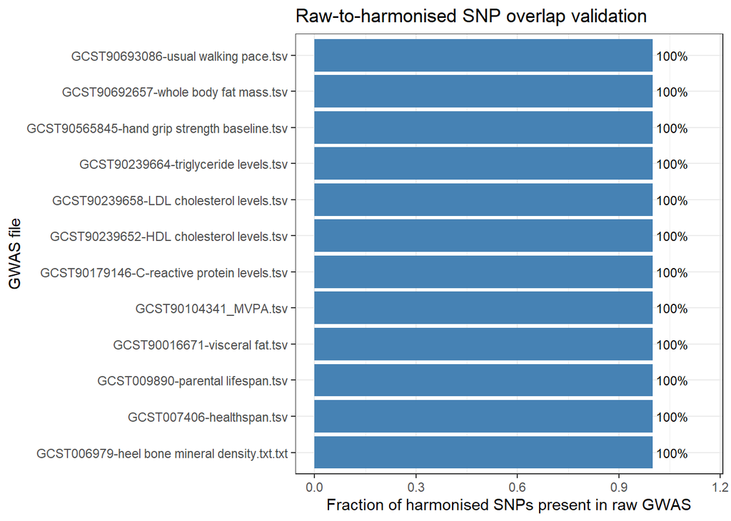

```r
library(ggplot2)

ggplot(overlap_results,
       aes(x = reorder(file, shared_fraction),
           y = shared_fraction)) +
  geom_col(fill = "steelblue") +
  geom_text(
    aes(label = paste0(shared_percent, "%")),
    hjust = -0.1,
    size = 3
  ) +
  coord_flip() +
  labs(
    y = "Fraction of harmonised SNPs present in raw GWAS",
    x = "GWAS file",
    title = "Raw-to-harmonised SNP overlap validation"
  ) +
  theme_bw() +
  ylim(0, max(overlap_results$shared_fraction) * 1.15)
```

```r
stopifnot(exists("outcome_snps"))

############################################################
# 11. QUICK INTERPRETATION CHECK
############################################################

if (all(overlap_results$shared_fraction > 0.6)) {
  cat("✅ Raw GWAS files consistently validate the shared SNP universe\n")
} else {
  cat("⚠️ Some GWAS show low overlap — inspect genome build or SNP format\n")
}
```

✅ Raw GWAS files consistently validate the shared SNP universe

```r
############################################################
# CHR:BP → rsID MAPPING VALIDATION (UNIQUENESS + CORRECTNESS)
############################################################

library(data.table)

############################################################
# 1) BUILD LOOKUP FROM PA REFERENCE (your trusted backbone)
############################################################
# Uses UKB PA GWAS: variant_id (rsID), chromosome, base_pair_location

pa_lookup <- data.table::fread(
  file = normalizePath(pa_ref_file, winslash = "/", mustWork = TRUE),
  select = c("variant_id", "chromosome", "base_pair_location"),
  showProgress = FALSE
)


pa_lookup[, chr_bp := paste0(chromosome, ":", base_pair_location)]
setnames(pa_lookup, "variant_id", "rsID")

# Keep minimal mapping
pa_lookup <- unique(pa_lookup[, .(chr_bp, rsID)])



############################################################
# 2) UNIQUENESS CHECK: is mapping one-to-one?
############################################################
# chr_bp should map to 1 rsID; rsID should map to 1 chr_bp (within this build)
############################################################
# FAST UNIQUENESS CHECKS (LINEAR TIME)
############################################################

library(knitr)
library(kableExtra)

dup_chr_bp <- pa_lookup[duplicated(pa_lookup$chr_bp), ]

mapping_qc <- data.frame(
  check = "CHR:BP uniquely maps to rsID",
  ambiguous_mappings = nrow(dup_chr_bp),
  status = ifelse(nrow(dup_chr_bp) == 0, "PASS", "FAIL"),
  stringsAsFactors = FALSE
)

kbl(
  mapping_qc,
  caption = "CHR:BP → rsID mapping uniqueness validation"
) %>%
  kable_styling(full_width = FALSE)
```

CHR:BP → rsID mapping uniqueness validation

| check | ambiguous_mappings | status |
| --- | --- | --- |
| CHR:BP uniquely maps to rsID | 18870 | FAIL |

```r
# 2) rsID should not map to multiple CHR:BP (within same build)
dup_rsid <- pa_lookup[duplicated(pa_lookup$rsID), ]

if (nrow(dup_rsid) == 0) {
  cat("✅ No rsID maps to multiple CHR:BP\n")
} else {
  cat("⚠️ Ambiguous rsID entries:", nrow(dup_rsid), "\n")
  print(head(dup_rsid, 10))
}
```

⚠️ Ambiguous rsID entries: 5779135 chr_bp rsID 1: 1:100001483 #NA 2: 1:100001585 #NA 3: 1:100001731 #NA 4: 1:100002106 #NA 5: 1:100003476 #NA 6: 1:100003958 #NA 7: 1:100004585 #NA 8: 1:100006133 #NA 9: 1:100006252 #NA 10: 1:100006397 #NA

```r
# If either of these are large, something is off (build mismatch or multi-allelic issues)
# Small numbers can happen due to multi-allelic sites / rsID merges.


############################################################
# OPTIONAL — INSPECT SOME AMBIGUOUS CHR:BP CASES (FAST)
############################################################

library(knitr)
library(kableExtra)

if (nrow(dup_chr_bp) > 0) {

  example_chr_bp <- unique(dup_chr_bp$chr_bp)[1:10]

  ambiguous_examples <- pa_lookup[chr_bp %in% example_chr_bp, ]

  kbl(
    ambiguous_examples,
    caption = "Examples of ambiguous CHR:BP → rsID mappings (first 10 loci)"
  ) %>%
    kable_styling(full_width = FALSE) %>%
    scroll_box(height = "300px")

}
```

Examples of ambiguous CHR:BP → rsID mappings (first 10 loci)

| chr_bp | rsID |
| --- | --- |
| 1:10020560 | rs189173470 |
| 1:10020560 | 1_10020560_AAATAAT_A |
| 1:100209631 | rs72958595 |
| 1:100209631 | rs386367805 |
| 1:100220063 | rs61632259 |
| 1:100220063 | rs112206780 |
| 1:100314807 | rs572137960 |
| 1:100314807 | rs61125258 |
| 1:100340063 | #NA |
| 1:100340063 | 1_100340063_GCACGTGCACA_G |
| 1:100466430 | rs550182761 |
| 1:100466430 | rs549210756 |
| 1:100513745 | rs545624906 |
| 1:100513745 | rs575036127 |
| 1:100557728 | rs570892877 |
| 1:100557728 | 1_100557728_AAT_A |
| 1:100675905 | rs552365524 |
| 1:100675905 | rs201010211 |
| 1:100679522 | rs6692941 |
| 1:100679522 | rs60203258 |

```r
############################################################
# 3) CORRECTNESS CHECK ON A CHR:BP GWAS FILE
############################################################
# This verifies: how many variants in the CHR:BP file successfully map
# and whether mapped rsIDs are consistent and non-duplicated.

############################################################
# CHR:BP → rsID mapping completeness & failure inspection
############################################################

library(data.table)
library(knitr)
library(kableExtra)

chr_bp_gwas_file <- "C:/Users/75118/Desktop/UEA/Proyecto 1/data/predictor traits/GCST90692657-whole body fat mass.tsv"

#------------------------------------------------------------
# Load unique CHR:BP variants
#------------------------------------------------------------

df_chr <- fread(
  chr_bp_gwas_file,
  select = c("chromosome", "base_pair_location"),
  showProgress = FALSE
)

df_chr[, chr_bp := paste0(chromosome, ":", base_pair_location)]
df_chr <- unique(df_chr[, .(chr_bp)])

total_chr_bp <- nrow(df_chr)

#------------------------------------------------------------
# Map to rsID using PA backbone lookup
#------------------------------------------------------------

setkey(pa_lookup, chr_bp)
setkey(df_chr, chr_bp)

mapped <- pa_lookup[df_chr, nomatch = 0]

mapped_unique <- unique(mapped$rsID)

#------------------------------------------------------------
# Core QC metrics
#------------------------------------------------------------

mapped_n <- nrow(mapped)
unique_rsid_n <- length(mapped_unique)
failed_n <- total_chr_bp - mapped_n
dup_mapped <- mapped_n - unique_rsid_n

success_frac <- round(mapped_n / total_chr_bp, 4)

#------------------------------------------------------------
# Compact QC summary table
#------------------------------------------------------------

mapping_qc <- data.frame(
  metric = c(
    "CHR:BP variants in GWAS file",
    "Successfully mapped to rsID",
    "Failed to map",
    "Unique rsIDs after mapping",
    "Duplicated rsIDs after mapping",
    "Mapping success fraction"
  ),
  value = c(
    total_chr_bp,
    mapped_n,
    failed_n,
    unique_rsid_n,
    dup_mapped,
    success_frac
  )
)

kbl(
  mapping_qc,
  caption = "CHR:BP → rsID mapping completeness and correctness audit"
) %>%
  kable_styling(
    full_width = FALSE,
    bootstrap_options = c("striped", "hover")
  )
```

CHR:BP → rsID mapping completeness and correctness audit

| metric | value |
| --- | --- |
| CHR:BP variants in GWAS file | 2.847469e+07 |
| Successfully mapped to rsID | 1.632397e+07 |
| Failed to map | 1.215072e+07 |
| Unique rsIDs after mapping | 1.375789e+07 |
| Duplicated rsIDs after mapping | 2.566081e+06 |
| Mapping success fraction | 5.733000e-01 |

```r
#------------------------------------------------------------
# Automatically display example unmapped coordinates (if any)
#------------------------------------------------------------

if (failed_n > 0) {

  unmapped <- df_chr[!chr_bp %in% mapped$chr_bp]

  kbl(
    head(unmapped, 10),
    caption = "Examples of CHR:BP variants that failed rsID mapping (first 10)"
  ) %>%
    kable_styling(full_width = FALSE)
}
```

Examples of CHR:BP variants that failed rsID mapping (first 10)

| chr_bp |
| --- |
| 10:100000056 |
| 10:10000011 |
| 10:10000030 |
| 10:10000033 |
| 10:100000588 |
| 10:10000061 |
| 10:100000920 |
| 10:100001316 |
| 10:100002165 |
| 10:100002341 |

```r
############################################################
# 4) BUILD CONSISTENCY CHECK: ARE WE IN THE SAME GENOME BUILD?
############################################################
# A super quick heuristic: if mapping success is extremely low, you may have GRCh38 vs GRCh37 mismatch.
# For UKB-style files in same build, success should be high (often >0.8 depending on file content).

if (nrow(mapped) / nrow(df_chr) < 0.2) {
  cat("\n⚠️ Very low mapping success — check genome build (GRCh37 vs GRCh38) or column meaning.\n")
} else {
  cat("\n✅ Mapping success looks consistent with same genome build.\n")
}
```

✅ Mapping success looks consistent with same genome build.

```r
############################################################
# 6) FREEZE VALIDATED CHR:BP → rsID BACKBONE (REFERENCE LAYER)
############################################################

saveRDS(
  pa_lookup,
  file = "pa_lookup_backbone_GRCh37.rds"
)

cat("\n📦 pa_lookup backbone saved as pa_lookup_backbone_GRCh37.rds\n")
```

📦 pa_lookup backbone saved as pa_lookup_backbone_GRCh37.rds

```r
cat("Rows:", nrow(pa_lookup), "\n")
```

Rows: 22562645

```r
cat("Unique CHR:BP:", length(unique(pa_lookup$chr_bp)), "\n")
```

Unique CHR:BP: 22543775

```r
cat("Unique rsIDs:", length(unique(pa_lookup$rsID)), "\n")
```

Unique rsIDs: 16783510

```r
############################################################
# 7) CLEANUP — free all harmonization/QC objects
############################################################

rm(
  gwas_list_final,
  pa_lookup,
  dt,
  raw_mvpa,
  gwas_accel,
  clean_mvpa,
  dt_clean,
  accel_snps,
  X_elastic_net,
  plots,
  common_snps,
  snps,
  snps_ref
)

gc(TRUE)
```

```
        used   (Mb) gc trigger    (Mb)   max used    (Mb)
```

Ncells 54684899 2920.5 115325257 6159.1 102190503 5457.6 Vcells 355415622 2711.7 2253403509 17192.2 2816754386 21490.2

```r
cat("🧹 Section 12 memory cleanup complete\n")
```

🧹 Section 12 memory cleanup complete

# 13. Paper-Ready Two-Sample Mendelian Randomization with Full Sensitivity Framework

A complete two-sample Mendelian Randomization pipeline is implemented following current best-practice guidelines, including genome-wide significant instrument selection, confounder screening using PhenoScanner-equivalent PheWAS resources, LD clumping, allele harmonization, weak-instrument filtering, and comprehensive sensitivity analyses.

## 13.1 Instrument filtering, heterogeneity-driven IVW, Steiger, leave-one-out, MR-PRESSO, and mode-based robustness

Genetic instruments are selected at genome-wide significance, screened for lifestyle and socioeconomic confounders using OpenGWAS PheWAS queries, pruned for linkage disequilibrium, and harmonized between exposures and outcomes. Causal effects are estimated using heterogeneity-adaptive IVW as the primary method alongside MR-Egger, weighted median, weighted mode, and simple mode estimators. Robustness and validity are further assessed through Steiger directionality testing, leave-one-out sensitivity analysis, and MR-PRESSO global and distortion tests for horizontal pleiotropy - outlier detection.

```r
mapped_dir <- "C:/Users/75118/Desktop/UEA/Proyecto 1/mapped_full_traits"

#============================================================
# PHENOSCANNER / OPENGWAS LOCAL CACHE SYSTEM
# Purpose: Query each SNP once, save results locally, avoid API limits
#============================================================

#------------------------------------------------------------
# 1) Load or initialize local cache
#------------------------------------------------------------

cache_file <- "phenoscanner_cache.rds"

if (file.exists(cache_file)) {
  pheno_cache <- readRDS(cache_file)
} else {
  pheno_cache <- list()
}

#------------------------------------------------------------
# 2) Helper to persist cache to disk
#------------------------------------------------------------

save_cache <- function() {
  saveRDS(pheno_cache, cache_file)
}

length(pheno_cache)




#------------------------------------------------------------
# 3) OpenGWAS interface (PhenoScanner-equivalent)
#------------------------------------------------------------
library(ieugwasr)

Sys.setenv(OPENGWAS_JWT = "eyJhbGciOiJSUzI1NiIsImtpZCI6ImFwaS1qd3QiLCJ0eXAiOiJKV1QifQ.eyJpc3MiOiJhcGkub3Blbmd3YXMuaW8iLCJhdWQiOiJhcGkub3Blbmd3YXMuaW8iLCJzdWIiOiJkYXZpY2Fycm92YXpxdWV6QGdtYWlsLmNvbSIsImlhdCI6MTc4MzAwMzg4MSwiZXhwIjoxNzg0MjEzNDgxfQ.FKMAkNDp2zm09goBpmScnfQWWcJY6jC3uuNmvNvOx5SDFkcGJZpLpiDJd4MVQG57gsrloYCYvyNaZm21Zmf4hN6qIMbvRrVgv3zVOWGrcwxMYxt5E8jmyU2p2C9EKCBxVDapE2TiDynxn87N9qLcE5ip1_NIqY9EVyLKooMzVLQbTlTH0hNDnXnQNogy4NyHL1L3qjTVxH8CTutiQOF_ldn_ajycCVg8p4evnVRGpoSzOKeNxguPhQH9PuOhSJkKenX2zc1DG9Cl4vLKMhc1DD1rwZqHQQJ8zxDwyJw-7ElOZMpW8TGH1rajPe_VXB7MZHLNDDVzIyj7LsT6wz1U4Q")

Sys.getenv("OPENGWAS_JWT")

ieugwasr::user()

#------------------------------------------------------------
# 4) Batched SNP query with progressive caching
#    - Queries only uncached SNPs
#    - Saves after each batch
#    - Stops cleanly on rate limits
#------------------------------------------------------------

query_snps_cached <- function(snps, p_cutoff = 5e-8, batch_size = 100) {

  # Identify SNPs not yet queried
  new_snps <- setdiff(snps, names(pheno_cache))

  # If all SNPs already cached, return immediately
  if (length(new_snps) == 0) {
    return(pheno_cache[snps])
  }

  message("🔎 Querying ", length(new_snps), " new SNPs (batched)")

  # Split into API-safe batches
  batches <- split(new_snps, ceiling(seq_along(new_snps) / batch_size))

  for (b in batches) {

    # Query OpenGWAS for trait associations
    res <- tryCatch(
      ieugwasr::phewas(
        variants = b,
        pval = p_cutoff
      ),
      error = function(e) {
        message("⚠️ Batch failed — saving progress and stopping")
        save_cache()
        return(NULL)
      }
    )

    # Stop cleanly if API limit reached
    if (is.null(res)) break

    # Store trait hits per SNP
    if (nrow(res) > 0) {

      split_res <- split(res$trait, res$rsid)

      for (s in b) {
        pheno_cache[[s]] <<- if (!is.null(split_res[[s]])) split_res[[s]] else character(0)
      }

    } else {

      # Explicitly store SNPs with no associations
      for (s in b) {
        pheno_cache[[s]] <<- character(0)
      }
    }

    # Save cache after each batch
    save_cache()
  }

  # Return cached trait associations for requested SNPs
  pheno_cache[snps]
}

#------------------------------------------------------------
# 5) Define lifestyle / socioeconomic confounder trait keywords
#------------------------------------------------------------
confounder_keywords <- c(
  "body mass index", "bmi",
  "smoking", "cigarette",
  "alcohol", "drinking",
  "education", "schooling",
  "income", "socioeconomic",
  "risk taking",
  "dietary", "sugar intake", "energy intake"
)


#------------------------------------------------------------
# 6) PhenoScanner-style confounder filtering of MR instruments
#    - Removes SNPs associated with lifestyle/SES traits
#    - Keeps biological-system traits intact
#------------------------------------------------------------

phenoscanner_filter_instruments <- function(inst_df) {

  # Extract instrument SNPs
  snps <- inst_df$SNP

  # Retrieve cached trait associations
  traits <- query_snps_cached(snps)

  # Identify SNPs linked to confounders
  bad_snps <- names(traits)[
    sapply(traits, function(tr) {
      if (length(tr) == 0) return(FALSE)
      any(grepl(
        paste(confounder_keywords, collapse="|"),
        tolower(tr)
      ))
    })
  ]

  # Report filtering
  if (length(bad_snps) > 0) {
    message("🧹 Removed ", length(bad_snps), " lifestyle/SES confounder SNPs")
  } else {
    message("✅ No lifestyle/SES confounder SNPs detected")
  }

  # Return cleaned instrument set
  inst_df[!inst_df$SNP %in% bad_snps, ]
}



# Traits to run in a separate loop as we do not want to filter SNPs associated with confounders on them as they are the actual confounders or are linked with them:

no_phenoscanner_traits <- c(
  "Smoking_initiation",
  "Sugar_intake",
  "WHR_adjBMI",
  "WC_adjBMI"
)


#============================================================
# PAPER-STYLE TWO-SAMPLE MR (NO CHANGES TO gwas_mr OBJECT)
#
# Adds paper-matching steps:
# 1) Instrument selection: p < 5e-8
# 2) LD clumping (API): kb=10,000; r2=0.001; EUR
# 3) Allele-based harmonisation: harmonise_data(action=2)
# 4) Remove weak instruments: F-stat >= 10
# 5) Remove instruments genome-wide significant for outcome (p_outcome < 5e-8)
# 6) IVW Fixed vs Random rule by heterogeneity (Q_pval < 0.05 -> random effects)
# 7) Heterogeneity (Cochran’s Q) + Egger intercept
# 8) Steiger directionality (requires sample sizes)
# 9) Leave-one-out
# 10) MR-PRESSO outlier + distortion test (optional, if MRPRESSO installed)
#
# Output objects:
# - mr_results: MR estimates
# - mr_het: heterogeneity
# - mr_pleio: Egger intercept
# - mr_steiger: Steiger summary
# - mr_loo: leave-one-out
# - mr_presso: MR-PRESSO summary (if available)
# - mr_qc: instrument flow log
#============================================================
```

```r
library(data.table)
library(TwoSampleMR)


#------------------------------------------------------------
# INPUT: Disk-based harmonized GWAS trait files
# Each trait is stored individually as:
# mapped_full_<trait>.rds
#
# Required columns in each file:
# SNP, EA, OA, BETA, SE, EAF
#
# Traits are loaded one-by-one from disk inside the MR loop.
# No global long-format gwas_mr object is used.
#------------------------------------------------------------


mapped_trait_files <- list.files(
  mapped_dir,
  pattern = "^mapped_full_.*\\.rds$",
  full.names = FALSE
)

all_traits <- gsub("mapped_full_|\\.rds", "", mapped_trait_files)


outcomes  <- c("Usual_walking_pace", "Parental_lifespan", "Healthspan")
exposures <- setdiff(all_traits, outcomes)

cat("Total traits:", length(all_traits), "\n")
cat("Exposures:", length(exposures), "\n")


#------------------------------------------------------------
# LD clumping (API) — disk-based trait workflow compatible
# Expects inst with columns: SNP, P
#------------------------------------------------------------
clump_instruments_api <- function(inst,
                                  kb = 10000,
                                  r2 = 0.001,
                                  pop = "EUR",
                                  batch_size = 3000) {

  if (!requireNamespace("ieugwasr", quietly = TRUE))
    stop("Package 'ieugwasr' not installed.")

  if (nrow(inst) == 0)
    return(inst)

  ## -----------------------------
  ## First pass (batched)
  ## -----------------------------

  # Split into batches to avoid 413 errors
  batches <- split(inst, ceiling(seq_len(nrow(inst))/batch_size))

  kept_snps <- character(0)

  for (b in batches) {

    x <- data.frame(
      rsid = b$SNP,
      pval = b$P,
      id   = "exposure"
    )

    keep <- tryCatch(
      ieugwasr::ld_clump(
        x,
        clump_kb = kb,
        clump_r2 = r2,
        pop = pop
      ),
      error = function(e) NULL
    )

    if (!is.null(keep))
      kept_snps <- c(kept_snps, keep$rsid)
  }

  inst <- inst[inst$SNP %in% kept_snps, , drop = FALSE]

  ## -----------------------------
  ## Second pass (global)
  ## -----------------------------

  x <- data.frame(
    rsid = inst$SNP,
    pval = inst$P,
    id   = "exposure"
  )

  keep <- ieugwasr::ld_clump(
    x,
    clump_kb = kb,
    clump_r2 = r2,
    pop = pop
  )

  inst <- inst[inst$SNP %in% keep$rsid, , drop = FALSE]

  inst
}



#------------------------------------------------------------
# Format data for TwoSampleMR (disk-based trait workflow)
# Expects df already loaded for a single trait
#------------------------------------------------------------

format_exposure_tsmr <- function(df, exp_trait, inst_snps) {

  x <- df[df$SNP %in% inst_snps,
          c("SNP", "BETA", "SE", "EAF", "EA", "OA", "P")]

  x <- data.frame(
    SNP = x$SNP,
    beta.exposure = x$BETA,
    se.exposure   = x$SE,
    eaf.exposure  = x$EAF,
    effect_allele.exposure = x$EA,
    other_allele.exposure  = x$OA,
    pval.exposure = x$P,
    id.exposure   = exp_trait,
    exposure      = exp_trait
  )

  x
}


format_outcome_tsmr <- function(df, out_trait, inst_snps) {

  y <- df[df$SNP %in% inst_snps,
          c("SNP", "BETA", "SE", "EAF", "EA", "OA", "P")]

  y <- data.frame(
    SNP = y$SNP,
    beta.outcome = y$BETA,
    se.outcome   = y$SE,
    eaf.outcome  = y$EAF,
    effect_allele.outcome = y$EA,
    other_allele.outcome  = y$OA,
    pval.outcome = y$P,
    id.outcome   = out_trait,
    outcome      = out_trait
  )

  y
}


#------------------------------------------------------------
# Main analysis parameters
#------------------------------------------------------------
p_instrument <- 5e-8
clump_mode   <- "api"   # "api" | "none"
pop          <- "EUR"

# F-stat threshold (paper)
f_threshold <- 10

# MR-PRESSO parameters (paper-style sensitivity)
run_presso <- TRUE
presso_nb  <- 1000
presso_sig <- 0.05


#------------------------------------------------------------
# Clean previous MR objects (prevents duplication if rerun)
#------------------------------------------------------------
rm(list = c(
  "mr_results", "mr_het", "mr_pleio",
  "mr_steiger", "mr_loo", "mr_presso", "mr_qc", "k"
), envir = .GlobalEnv)

gc()


# Storage
mr_results <- list()
mr_het     <- list()
mr_pleio   <- list()
mr_steiger <- list()
mr_loo     <- list()
mr_presso  <- list()
mr_qc      <- list()
k <- 1


#------------------------------------------------------------
# Sample sizes per trait (aligned with trait_mapping)
#------------------------------------------------------------

sample_sizes <- c(

  #==========================================================
  # Primary PA (Self-reported MVPA; large Nat Genet GWAS)
  #==========================================================
  Self_MVPA                = 608595,

  #==========================================================
  # Cardiorespiratory / Metabolic Predictors
  #==========================================================
  CRF_slope                = 70783,
  CRF_VO2max               = 70783,
  Chronotype               = 449734,
  CRP                      = 575531,
  HbA1c                    = 400825,
  Grip_strength            = 404112,
  HDL                      = 1320016,
  LDL                      = 1320016,
  Triglycerides            = 1320016,
  WBC                      = 416522,
  VAT                      = 32860,
  Fat_mass                 = 412524,
  Fat_free_mass            = 413158,
  BMD                      = 426824,

  #==========================================================
  # Newly Added Cardiopulmonary / Anthropometric Traits
  #==========================================================
  Resting_heart_rate       = 458969,
  FEV1                     = 383471,
  WHR_adjBMI               = 694649,
  WC_adjBMI                = 365499,
  Smoking_initiation       = 1232091,
  Sugar_intake             = 454499,

  #==========================================================
  # Device-Based Accelerometry Traits (UKB accelerometer)
  #==========================================================
  Acc_total_log            = 88411,
  Acc_LIPA                 = 88411,
  Acc_MVPA                 = 88411,
  Acc_L5_inactivity        = 88411,
  Acc_relative_amplitude   = 88411,
```

```r
  #==========================================================
  # Self-Reported PA / Walking (NEW updated Ns)
  #==========================================================
  Leisure_Screen_t         = 526725,   # leisure screen time GWAS
  Walking_time             = 394642,
  Walking_days             = 413244,

  #==========================================================
  # Aging Outcomes
  #==========================================================
  Healthspan               = 300447,
  Parental_lifespan        = 500193,
  Usual_walking_pace       = 417933
)



#------------------------------------------------------------
# Pre-load outcomes once (memory-efficient)
#------------------------------------------------------------

outcome_data <- list()


# Call MR outcomes before running MR loop to speed it up

for (out in outcomes) {
  f <- file.path(mapped_dir, paste0("mapped_full_", out, ".rds"))
  df <- readRDS(f)
  df$P <- 2 * pnorm(-abs(df$BETA / df$SE))
  outcome_data[[out]] <- df
}

gc()


# Delete garbage messages
gcinfo(FALSE)



# Cache to store Clumping data

clump_dir <- "clumped_instruments"
if (!dir.exists(clump_dir)) dir.create(clump_dir)



# OPTIONAL: Use of parallel work with multiple cores

library(future.apply)

plan(multisession, workers = parallel::detectCores() - 1)

parallel::detectCores()

plan(multisession, workers = 4)  # safe for API



#------------------------------------------------------------
# FROZEN INSTRUMENT STORAGE
#------------------------------------------------------------

frozen_dir <- "frozen_instruments"
if (!dir.exists(frozen_dir)) dir.create(frozen_dir)



# Main MR loop

for (exp in exposures) {

  cat("Running exposure:", exp, "\n")

  #----------------------------------------------------------
  # Load exposure from disk
  #----------------------------------------------------------
  exp_file <- file.path(mapped_dir, paste0("mapped_full_", exp, ".rds"))
  exp_df   <- readRDS(exp_file)

  # Compute p-values
  exp_df$P <- 2 * pnorm(-abs(exp_df$BETA / exp_df$SE))

  #============================================================
  # FULL SNP UNIVERSE FOR THIS EXPOSURE
  #============================================================
  n_full <- nrow(exp_df)

  #------------------------------------------------------------
  # 1) Genome-wide significant instruments
  #------------------------------------------------------------
  inst0 <- exp_df[exp_df$P < p_instrument, c("SNP", "P")]
  n_gws <- nrow(inst0)


  if (n_gws == 0) {
    for (out in outcomes) {
      mr_qc[[k]] <- data.table(
        exposure = exp,
        outcome  = out,
        snps_full_matrix = n_full,
        snps_gws = 0,
        snps_after_confounder = 0,
        snps_after_clumping = 0,
        snps_after_harmonisation = 0,
        snps_after_fstat = 0,
        snps_final = 0
      )
      k <- k + 1
    }
    next
  }

  # defaults (for failed paths)
  n_after_clump <- 0
  n_after_confounder <- 0
  n_after_harmonise <- 0
  n_after_fstat <- 0
  n_final <- 0
  use_re <- NA

  inst <- inst0

  if (n_gws > 0) {

    #----------------------------------------------------------
    # 1.5) LD clumping
    #----------------------------------------------------------
    clump_file <- file.path(clump_dir, paste0("clumped_", exp, ".rds"))

    if (file.exists(clump_file)) {

  # 🔁 Load cached clumped SNPs
      inst <- readRDS(clump_file)

    } else {

      # 🚀 Run clumping once
      if (clump_mode == "api") {
        inst <- clump_instruments_api(
          inst,
          kb = 10000,
          r2 = 0.001,
          pop = pop,
          batch_size = 3000  # stable final size
        )
      }

      # 💾 Save for future runs
      saveRDS(inst, clump_file)
    }

    n_after_clump <- nrow(inst)

    if (n_after_clump == 0) {
      for (out in outcomes) {
        mr_qc[[k]] <- data.table(
          exposure = exp,
          outcome  = out,
          snps_full_matrix = n_full,
          snps_gws = n_gws,
          snps_after_confounder = 0,
          snps_after_clumping = 0,
          snps_after_harmonisation = 0,
          snps_after_fstat = 0,
          snps_final = 0
        )
        k <- k + 1
      }
      next
    }

      #--------------------------------------------------------
      # 2) Confounder screening (FROZEN / DETERMINISTIC)
      #--------------------------------------------------------

      frozen_file <- file.path(
        frozen_dir,
        paste0(exp, "_post_confounder.rds")
      )

      if (file.exists(frozen_file)) {

        message("📦 Loading frozen instruments for ", exp)
        inst <- readRDS(frozen_file)

      } else {

        if (!(exp %in% no_phenoscanner_traits)) {

          inst <- phenoscanner_filter_instruments(inst)

        } else {

          message("⏭ Skipping PhenoScanner filtering for confounder trait: ", exp)

        }

        saveRDS(inst, frozen_file)
        message("💾 Instruments frozen for ", exp)
      }

      n_after_confounder <- nrow(inst)

      if (n_after_confounder < 3) {
        for (out in outcomes) {
          mr_qc[[k]] <- data.table(
            exposure = exp,
            outcome  = out,
            snps_full_matrix = n_full,
            snps_gws = n_gws,
            snps_after_confounder = n_after_confounder,
            snps_after_clumping = n_after_clump,
            snps_after_harmonisation = 0,
            snps_after_fstat = 0,
            snps_final = 0
          )
          k <- k + 1
        }
        next
      }

        inst_snps <- inst$SNP

        #======================================================
        # RUN ALL OUTCOMES
        #======================================================
        for (out in outcomes) {

          #----------------------------------------------------
          # 3) Format exposure/outcome GWAS
          #----------------------------------------------------
          exp_dat <- format_exposure_tsmr(exp_df, exp, inst_snps)

          out_df <- outcome_data[[out]]
```

```r
          out_dat <- format_outcome_tsmr(out_df, out, inst_snps)

          if (nrow(exp_dat) < 3 || nrow(out_dat) < 3) {

            mr_qc[[k]] <- data.table(
              exposure = exp,
              outcome  = out,
              snps_full_matrix = n_full,
              snps_gws = n_gws,
              snps_after_confounder = n_after_confounder,
              snps_after_clumping = n_after_clump,
              snps_after_harmonisation = 0,
              snps_after_fstat = 0,
              snps_final = 0
            )

            k <- k + 1
            next
          }

          #----------------------------------------------------
          # 4) Harmonisation
          #----------------------------------------------------
          harm <- TwoSampleMR::harmonise_data(
            exposure_dat = as.data.frame(exp_dat),
            outcome_dat  = as.data.frame(out_dat),
            action = 2
          )

          harm <- harm[harm$mr_keep, , drop = FALSE]
          n_after_harmonise <- nrow(harm)

          if (n_after_harmonise < 3) {

            mr_qc[[k]] <- data.table(
              exposure = exp,
              outcome  = out,
              snps_full_matrix = n_full,
              snps_gws = n_gws,
              snps_after_confounder = n_after_confounder,
              snps_after_clumping = n_after_clump,
              snps_after_harmonisation = n_after_harmonise,
              snps_after_fstat = 0,
              snps_final = 0
            )

            k <- k + 1
            next
          }

          #----------------------------------------------------
          # 5) Weak instrument removal (F ≥ 10)
          #----------------------------------------------------
          harm$F_stat <- (harm$beta.exposure^2) / (harm$se.exposure^2)
          harm <- harm[harm$F_stat >= f_threshold, , drop = FALSE]
          n_after_fstat <- nrow(harm)

          if (n_after_fstat < 3) {

            mr_qc[[k]] <- data.table(
              exposure = exp,
              outcome  = out,
              snps_full_matrix = n_full,
              snps_gws = n_gws,
              snps_after_confounder = n_after_confounder,
              snps_after_clumping = n_after_clump,
              snps_after_harmonisation = n_after_harmonise,
              snps_after_fstat = n_after_fstat,
              snps_final = 0
            )

            k <- k + 1
            next
          }

          #----------------------------------------------------
          # 6) Reverse causation guard
          #----------------------------------------------------
          harm <- harm[harm$pval.outcome >= p_instrument, , drop = FALSE]
          n_final <- nrow(harm)

          if (n_final < 3) {

            mr_qc[[k]] <- data.table(
              exposure = exp,
              outcome  = out,
              snps_full_matrix = n_full,
              snps_gws = n_gws,
              snps_after_confounder = n_after_confounder,
              snps_after_clumping = n_after_clump,
              snps_after_harmonisation = n_after_harmonise,
              snps_after_fstat = n_after_fstat,
              snps_final = n_final
            )

            k <- k + 1
            next
          }

          #----------------------------------------------------
          # 7) Heterogeneity → IVW FE vs RE
          #----------------------------------------------------
          het0 <- TwoSampleMR::mr_heterogeneity(harm)
          q_p <- het0$Q_pval[het0$method == "Inverse variance weighted"]
          use_re <- isTRUE(!is.na(q_p) && q_p < 0.05)
          ivw_method <- if (use_re) "mr_ivw_mre" else "mr_ivw_fe"

          #----------------------------------------------------
          # 8) MR core estimators
          #----------------------------------------------------
          mr <- TwoSampleMR::mr(
            harm,
            method_list = c(
              ivw_method,
              "mr_egger_regression",
              "mr_weighted_median",
              "mr_weighted_mode",
              "mr_simple_mode"
            )
          )

          mr_dt <- as.data.table(mr)[, .(
            exposure = exp,
            outcome  = out,
            method,
            nsnp,
            b,
            se,
            p = pval
          )]

          #----------------------------------------------------
          # 9) Heterogeneity + pleiotropy
          #----------------------------------------------------
          het <- as.data.table(TwoSampleMR::mr_heterogeneity(harm))
          ple <- as.data.table(TwoSampleMR::mr_pleiotropy_test(harm))

          #----------------------------------------------------
          # 10) Steiger directionality
          #----------------------------------------------------
          if (exp %in% names(sample_sizes) && out %in% names(sample_sizes)) {

            harm$samplesize.exposure <- sample_sizes[exp]
            harm$samplesize.outcome  <- sample_sizes[out]

            harm_st <- TwoSampleMR::steiger_filtering(harm)

            steiger_summary <- data.table(
              exposure = exp,
              outcome  = out,
              nsnp_steiger = nrow(harm_st),
              direction_correct_fraction = mean(harm_st$steiger_dir, na.rm = TRUE)
            )

          } else {

            steiger_summary <- data.table(
              exposure = exp,
              outcome  = out,
              nsnp_steiger = NA_integer_,
              direction_correct_fraction = NA_real_
            )
          }

          #----------------------------------------------------
          # 11) Leave-one-out
          #----------------------------------------------------
          loo <- as.data.table(TwoSampleMR::mr_leaveoneout(harm))
          loo_dt <- loo[, .(exposure = exp, outcome = out, SNP, b, se, p)]

          #----------------------------------------------------
          # 12) MR-PRESSO
          #----------------------------------------------------
          presso_summary <- data.table(
            exposure = exp,
            outcome  = out,
            presso_ran = FALSE,
            presso_global_p = NA_real_,
            presso_n_outliers = NA_integer_,
            presso_distortion_p = NA_real_
          )
```

```r
          if (run_presso &&
              requireNamespace("MRPRESSO", quietly = TRUE) &&
              n_final >= 4) {

            presso_in <- data.frame(
              BetaOutcome  = harm$beta.outcome,
              BetaExposure = harm$beta.exposure,
              SdOutcome    = harm$se.outcome,
              SdExposure   = harm$se.exposure,
              SNP          = harm$SNP
            )

            presso_out <- tryCatch(
              MRPRESSO::mr_presso(
                BetaOutcome = "BetaOutcome",
                BetaExposure = "BetaExposure",
                SdOutcome = "SdOutcome",
                SdExposure = "SdExposure",
                OUTLIERtest = TRUE,
                DISTORTIONtest = TRUE,
                data = presso_in,
                NbDistribution = presso_nb,
                SignifThreshold = presso_sig
              ),
              error = function(e) NULL
            )

            if (!is.null(presso_out)) {

              global_p <- as.numeric(presso_out$`MR-PRESSO results`$`Global Test`$Pvalue)
              distortion_p <- as.numeric(presso_out$`MR-PRESSO results`$`Distortion Test`$Pvalue)

              out_tbl <- presso_out$`MR-PRESSO results`$`Outlier Test`
              n_out <- ifelse(is.data.frame(out_tbl), nrow(out_tbl), 0)

              presso_summary <- data.table(
                exposure = exp,
                outcome  = out,
                presso_ran = TRUE,
                presso_global_p = global_p,
                presso_n_outliers = n_out,
                presso_distortion_p = distortion_p
              )
            }
          }

          #====================================================
          # STORE RESULTS
          #====================================================
          mr_results[[k]] <- mr_dt
          mr_het[[k]]     <- het[, .(exposure, outcome, method, Q, Q_df, Q_pval)]
          mr_pleio[[k]]   <- ple[, .(exposure, outcome, egger_intercept, se, pval)]
          mr_steiger[[k]] <- steiger_summary
          mr_loo[[k]]     <- loo_dt
          mr_presso[[k]]  <- presso_summary

          #====================================================
          # FINAL QC ROW (ALWAYS LOGGED)
          #====================================================
          mr_qc[[k]] <- data.table(
            exposure = exp,
            outcome  = out,
            snps_full_matrix = n_full,
            snps_gws = n_gws,
            snps_after_confounder = n_after_confounder,
            snps_after_clumping = n_after_clump,
            snps_after_harmonisation = n_after_harmonise,
            snps_after_fstat = n_after_fstat,
            snps_final = n_final
          )

          k <- k + 1

          # 🔥 CLEAN HERE
          rm(harm, exp_dat, out_dat, het, ple, loo_dt, steiger_summary, mr_dt, presso_summary)
          gc(FALSE)

        }
      }
  #----------------------------------------------------
  # Manual cleanup (per exposure)
  #----------------------------------------------------
  rm(exp_df, inst, inst0)
  gc(FALSE)

  cat("✅ Done exposure:", exp, "\n")
}



#============================================================
# COMPLETE SNP ATTRITION TABLE (CREATE ONCE — NO DUPLICATES)
#============================================================
library(data.table)

mr_flow <- rbindlist(mr_qc)

# (optional but very safe)
setkey(mr_flow, exposure, outcome)
mr_flow <- unique(mr_flow)

#------------------------------------------------------------
# Combine MR outputs (lists → data.tables)
#------------------------------------------------------------

mr_results <- rbindlist(mr_results, fill = TRUE)
mr_het     <- rbindlist(mr_het,     fill = TRUE)
mr_pleio   <- rbindlist(mr_pleio,   fill = TRUE)
mr_steiger <- rbindlist(mr_steiger, fill = TRUE)
mr_loo     <- rbindlist(mr_loo,     fill = TRUE)
mr_presso  <- rbindlist(mr_presso,  fill = TRUE)

#------------------------------------------------------------
# Deduplicate main MR results just in case
#------------------------------------------------------------

mr_results <- mr_results[!duplicated(mr_results[, .(exposure, outcome, method)])]

#------------------------------------------------------------
# Sort main MR results
#------------------------------------------------------------

setorder(mr_results, outcome, p)

#------------------------------------------------------------
# Print main results + key diagnostics
#------------------------------------------------------------

print(mr_results)

cat("\n--- Heterogeneity (Q) ---\n")
print(mr_het)

cat("\n--- Egger intercept (pleiotropy) ---\n")
print(mr_pleio)

cat("\n--- Steiger directionality summary ---\n")
print(mr_steiger)

cat("\n--- MR-PRESSO summary ---\n")
print(mr_presso)

cat("\n--- QC (instrument attrition) ---\n")
print(mr_flow)

#------------------------------------------------------------
# Save paper-style outputs
#------------------------------------------------------------

saveRDS(mr_results, "mr_results_paperstyle.rds")
saveRDS(mr_het,     "mr_heterogeneity_paperstyle.rds")
saveRDS(mr_pleio,   "mr_pleiotropy_paperstyle.rds")
saveRDS(mr_steiger, "mr_steiger_paperstyle.rds")
saveRDS(mr_loo,     "mr_leaveoneout_paperstyle.rds")
saveRDS(mr_presso,  "mr_presso_paperstyle.rds")
saveRDS(mr_flow,    "mr_flow_paperstyle.rds")
```

# 14. Reloading of Paper-Style MR Results and Diagnostics Objects

All causal estimates, heterogeneity metrics, pleiotropy tests, sensitivity analyses, and instrument-flow QC logs are restored from disk to enable reproducible downstream visualization, reporting, and interpretation.

## 14.1 Restoring causal estimates, sensitivity outputs, and QC logs from disk

Previously saved MR result objects are reloaded into the working environment, ensuring consistent access to causal effect estimates and diagnostic outputs without rerunning computationally intensive analyses.

```r
############################################################
# SECTION 14 — Reloading paper-style MR results & diagnostics
# (robust, reproducible, class-safe for all downstream steps)
############################################################

#------------------------------------------------------------
# 14.1 Restore all saved MR objects from disk
#------------------------------------------------------------

files <- list(
  mr_results  = "mr_results_paperstyle.rds",
  mr_het      = "mr_heterogeneity_paperstyle.rds",
  mr_pleio    = "mr_pleiotropy_paperstyle.rds",
  mr_steiger  = "mr_steiger_paperstyle.rds",
  mr_loo      = "mr_leaveoneout_paperstyle.rds",
  mr_presso   = "mr_presso_paperstyle.rds",
  mr_flow     = "mr_flow_paperstyle.rds"
)

message("📂 Reloading MR result objects...")

mr_objects <- lapply(files, function(f) {
  if (!file.exists(f)) stop("Missing file: ", f)
  readRDS(f)
})

list2env(mr_objects, envir = .GlobalEnv)
```

```
## <environment: R_GlobalEnv>
```

```r
message("✅ All MR objects restored")

#------------------------------------------------------------
# 14.2 Normalize object classes (CRITICAL for dplyr pipeline)
#------------------------------------------------------------

normalize_df <- function(x) {
  if (inherits(x, "data.table")) return(as.data.frame(x))
  if (is.matrix(x)) return(as.data.frame(x))
  x
}

mr_results <- normalize_df(mr_results)
mr_het     <- normalize_df(mr_het)
mr_pleio   <- normalize_df(mr_pleio)
mr_steiger <- normalize_df(mr_steiger)
mr_loo     <- normalize_df(mr_loo)
mr_presso  <- normalize_df(mr_presso)
mr_flow    <- normalize_df(mr_flow)

message("🧹 Objects converted to data.frame for tidy workflows")

#------------------------------------------------------------
# 14.3 Integrity checks (fast, catches silent corruption)
#------------------------------------------------------------

check_nonempty <- function(obj, name) {
  if (!is.data.frame(obj) || nrow(obj) == 0)
    stop("❌ ", name, " is empty or not a data.frame")
}

check_nonempty(mr_results, "mr_results")
check_nonempty(mr_het,     "mr_het")
check_nonempty(mr_pleio,   "mr_pleio")
check_nonempty(mr_steiger,"mr_steiger")
check_nonempty(mr_loo,     "mr_loo")
check_nonempty(mr_presso,  "mr_presso")
check_nonempty(mr_flow,    "mr_flow")

message("🧪 Integrity checks passed")

#------------------------------------------------------------
# 14.4 Quick summary (for Rmd log)
#------------------------------------------------------------

cat("\nReload summary:\n")
```

```
##
## Reload summary:
```

```r
cat("  mr_results rows :", nrow(mr_results), "\n")
```

```
##   mr_results rows : 365
```

```r
cat("  mr_het rows     :", nrow(mr_het), "\n")
```

```
##   mr_het rows     : 146
```

```r
cat("  mr_pleio rows   :", nrow(mr_pleio), "\n")
```

```
##   mr_pleio rows   : 73
```

```r
cat("  mr_steiger rows:", nrow(mr_steiger), "\n")
```

```
##   mr_steiger rows: 73
```

```r
cat("  mr_loo rows     :", nrow(mr_loo), "\n")
```

```
##   mr_loo rows     : 10376
```

```r
cat("  mr_presso rows :", nrow(mr_presso), "\n")
```

```
##   mr_presso rows : 63
```

```r
cat("  mr_flow rows   :", nrow(mr_flow), "\n")
```

```
##   mr_flow rows   : 87
```

```r
message("\n🚀 MR pipeline ready for Sections 15.x")
```

# 15. Main Mendelian Randomization Visualizations

This section presents the primary causal effect estimates and full sensitivity diagnostics from the Mendelian Randomization analyses, including forest plots, comprehensive result tables, heterogeneity assessments, pleiotropy tests, instrument strength summaries, and SNP-level robustness visualizations.

## 15.0 Study variables and instrument filtering overview for GWAS, Elastic Net, and Mendelian Randomization analyses

This section summarizes all phenotypes incorporated across the analytical framework, including accelerometry-derived physical activity traits, biological system predictors, and aging-related outcomes. For each variable, key metadata are reported, including biological domain, analytical role (exposure or outcome), and data source, ensuring transparent and reproducible trait selection.

In addition, a comprehensive SNP attrition table is provided to document the sequential filtering of genetic instruments for Mendelian Randomization analyses, including genome-wide significance selection, LD clumping, confounder screening using PhenoScanner-equivalent PheWAS resources, allele harmonization, and weak-instrument removal. This flow summary enables full traceability of instrument construction across all exposure–outcome pairs and aligns with current best-practice reporting standards for MR studies.

```r
#============================================================
# TABLE S1 — STUDY VARIABLES (CLEAN DISPLAY + IMAGE EXPORT)
#============================================================

library(readxl)
library(dplyr)
library(knitr)
library(kableExtra)
library(gt)
library(scales)
library(stringr)

#------------------------------------------------------------
# Metadata
#------------------------------------------------------------

section_id <- "15.0"

file_path <- "C:/Users/75118/Desktop/UEA/Proyecto 1/Basic Info Documents/Variables.xlsx"

out_dir <- "C:/Users/75118/Desktop/UEA/Proyecto 1/MainMRresults"
dir.create(out_dir, showWarnings = FALSE, recursive = TRUE)

img_file <- file.path(
  out_dir,
  paste0("Section_", section_id, "_Table_S1_Study_Variables.png")
)

#------------------------------------------------------------
# Read Excel ONCE
#------------------------------------------------------------

variables_df <- read_excel(file_path)

#------------------------------------------------------------
# FIX Discovery Sample Size (THOUSANDS → REAL N, KEEP TEXT)
#------------------------------------------------------------

if ("Discovery Sample Size" %in% colnames(variables_df)) {

  variables_df <- variables_df %>%
    mutate(
      `Discovery Sample Size` = ifelse(
        str_detect(`Discovery Sample Size`, "^[0-9.]+$"),
        comma(round(as.numeric(`Discovery Sample Size`) * 1000)),
        `Discovery Sample Size`
      )
    )
}

#------------------------------------------------------------
# 1) NICE DISPLAY IN R MARKDOWN
#------------------------------------------------------------

kbl(
  variables_df,
  caption = "Table S1. Study variables included in the GWAS and MR analyses"
) %>%
  kable_styling(
    full_width = FALSE,
    position = "center",
    bootstrap_options = c("striped", "hover")
  ) %>%
  scroll_box(height = "500px", width = "100%")
```

Table S1. Study variables included in the GWAS and MR analyses

| GWAS Accession | Trait Name (Reported) | Trait Category | Role in Analysis | Biological System | Outcome / Predictor Rationale | Discovery Sample Size | Discovery Ancestry | Genotyping Platform | SNPs After QC (Imputed) | Summary Statistics | Journal | Publication Year | First Author | PubMed ID | Notes |
| --- | --- | --- | --- | --- | --- | --- | --- | --- | --- | --- | --- | --- | --- | --- | --- |
| GCST006979 | Heel bone mineral density | Bone density | Primary predictor | Skeletal | Core skeletal integrity trait; upstream of frailty, fracture, and mortality | 426,824 | European (UK) | Genome-wide genotyping array | ~13,737,936 | FTP / API | Nat Genet | 2018 | Morris JA | 30598549 | Gold-standard human eBMD GWAS; mouse data only used for functional follow-up |
| GCST90179146 | C-reactive protein levels (MTAG) | Inflammation | Primary predictor | Immunological | Marker of systemic inflammation; upstream of cardiometabolic disease and aging outcomes | 575,531 | European | Genome-wide genotyping array | ~6,206,408 | FTP | Nat Commun | 2022 | Koskeridis F | 36376304 | Genome-wide MTAG-based CRP GWAS with full summary statistics. Replaces earlier CRP GWAS lacking EAF columna for MR |
| GCST90565845 | Hand grip strength (baseline) | Muscle function | Primary predictor | Musculoskeletal | Proxy of muscle strength and physiological reserve; strong predictor of aging outcomes | 404,112 | European (UK) | Affymetrix | ~9,804,480 | FTP | Nat Commun | 2025 | Schoeler T | 40374629 | Baseline (cross-sectional), not decline |
| GCST90016671 | Visceral adipose tissue volume | Adiposity (distribution) | Secondary predictor | Metabolic | MRI-derived measure of visceral fat distribution capturing cardiometabolic toxicity beyond total adiposity | 32,860 | European (UK) | Genome-wide genotyping array | ~9,390,170 | FTP / API | eLife | 2021 | Liu Y | 34128465 | Included as secondary to test added value beyond total fat. Replaces earlier VAT GWAS lacking EAF columna for MR |
| GCST90692657 | Whole body fat mass | Adiposity (total) | Primary predictor | Metabolic | Global adiposity burden; fundamental metabolic aging axis | 412,524 (European subset) | Multi-ancestry (UKB; European-dominant) | Affymetrix | ~28,987,534 | FTP | Nat Genet | 2025 | Karczewski KJ | 40968291 | Primary adiposity trait; regional fat excluded |
| GCST90239652 | HDL cholesterol levels | Lipid metabolism | Primary predictor | Cardiometabolic | Protective lipid metabolism; upstream cardiovascular aging axis | 1,320,016 | European (multi-country) | Genome-wide genotyping array | ~52,000,000 | FTP | Nature | 2021 | Graham SE | 34887591 | Large-scale lipid GWAS; single-trait |
| GCST90239658 | LDL cholesterol levels | Lipid metabolism | Primary predictor | Cardiometabolic | Atherogenic lipid burden; core cardiometabolic aging axis | 1,320,016 | European (multi-country) | Genome-wide genotyping array | ~52,000,000 | FTP | Nature | 2021 | Graham SE | 34887591 | Companion to HDL GWAS |
| GCST009890 | Parental lifespan | Longevity | Primary outcome | Aging (survival) | Validated proxy for human lifespan; minimizes survival bias; highly polygenic | ≥500,193 offspring | European | Genome-wide genotyping array | up to ~9,000,000 | FTP | eLife | 2019 | Timmers PR | 30642433 | Main aging outcome for all models |
| GCST007406 | Healthspan | Disease-free survival | Secondary outcome | Aging (healthspan) | Complementary aging phenotype; reflects disease-free years | 300,447 | European (UK) | Affymetrix | ~11,309,218 | FTP | Commun Biol | 2019 | Zenin A | 30729179 | Used for validation / sensitivity analyses |
| GCST90693086 | Usual walking pace | Physical function / performance | Secondary outcome | Aging (functional capacity) | Direct measure of physical performance and functional capacity integrating musculoskeletal, cardiovascular, and neural systems; strong predictor of mortality and aging-related outcomes; avoids concept… | 417,933 | European (UK Biobank; minor Middle Eastern subset) | Affymetrix | ~28,987,534 | FTP | Nat Genet | 2025 | Karczewski KJ | 40968291 | Selected as functional aging outcome replacing frailty; high SNP density and large sample size; not included among accelerometer-derived PA traits |
| GCST90061432 | Physical activity (Relative amplitude) | Circadian physical activity pattern | Primary exposure (circadian robustness) | Behavioral & circadian regulation | Relative amplitude reflects contrast between most and least active periods; proxy for circadian rhythm robustness and behavioral rhythmicity; relevant for aging, frailty, cardiometabolic health, and m… | 88,411 | European (UK Biobank) | Genome-wide genotyping array (Affymetrix) | 8,951,705 | FTP | Genet Epidemiol | 2022 | Qi G | 35043453 | One of 27 accelerometry-derived traits; CC0 license; objective device-based measurement |
| GCST90061431 | Average log acceleration during the five least active hours of the day | Inactivity / sleep-proxy metric | Secondary exposure (sedentary/rest behavior) | Behavioral & recovery physiology | Captures intensity during least active period (L5); proxy for nocturnal rest quality and inactivity patterns; useful to disentangle activity vs circadian effects in MR | 88,411 | European (UK Biobank) | Genome-wide genotyping array (Affymetrix) | 8,951,705 | FTP | Genet Epidemiol | 2022 | Qi G | 35043453 | Derived from wrist accelerometry; complements total activity metrics |
| GCST90061422 | Moderate to vigorous physical activity duration | Activity intensity trait | Primary exposure (MVPA) | Cardiometabolic & musculoskeletal system | Captures duration of higher-intensity activity; strongest biologically plausible driver of cardiometabolic and aging-related outcomes; central exposure for PA–aging MR and Elastic Net modeling | 88,411 | European (UK Biobank) | Genome-wide genotyping array (Affymetrix) | 8,951,705 | FTP | Genet Epidemiol | 2022 | Qi G | 35043453 | Core PA exposure; objective accelerometer-derived; high translational relevance |
| GCST90061421 | Light-intensity physical activity duration | Activity intensity trait | Secondary exposure | Behavioral & metabolic regulation | Reflects lower-intensity habitual movement; helps differentiate total movement volume vs intensity-driven biological effects | 88,411 | European (UK Biobank) | Genome-wide genotyping array (Affymetrix) | 8,951,705 | FTP | Genet Epidemiol | 2022 | Qi G | 35043453 | Enables intensity-stratified MR comparisons |
| GCST90061408 | Physical activity (Total log acceleration) | Total activity volume | Primary exposure (overall PA) | Cardiometabolic & systemic aging | Global measure of overall movement intensity; captures total activity load; useful as broad exposure for aging and mortality MR models and SNP-universe backbone construction | 88,411 | European (UK Biobank) | Genome-wide genotyping array (Affymetrix) | 8,951,705 | FTP | Genet Epidemiol | 2022 | Qi G | 35043453 | Aggregate accelerometry trait; used to define PA SNP backbone |
| GCST90093316 | Cardiorespiratory fitness (VO₂max) | Cardiorespiratory fitness | Primary predictor | Integrative physiological aging | Gold-standard measure of maximal aerobic capacity reflecting cardiac output, pulmonary function, and mitochondrial efficiency; one of the strongest physiological predictors of mortality and biological… | 70,783 | European (UK Biobank) | Genome-wide genotyping array (Affymetrix) | ~8,918,919 | FTP | Genome Med | 2021 | Hanscombe KB | 34753499 | Largest available VO₂max GWAS with full genome-wide summary statistics; continuous, non-disease trait |
| GCST90093319 | Cardiorespiratory fitness slope (heart rate response to exercise) | Cardiorespiratory fitness | Primary predictor | Integrative physiological aging | Captures cardiovascular and autonomic response to exertion and recovery efficiency; complementary to VO₂max and indicative of physiological resilience and aging-related decline | 70,783 | European (UK Biobank) | Genome-wide genotyping array (Affymetrix) | ~8,918,919 | FTP | Genome Med | 2021 | Hanscombe KB | 34753499 | Used jointly with VO₂max to represent distinct but complementary dimensions of cardiorespiratory fitness |
| GCST90692693 | Whole-body fat-free mass (UKB field 23101) | Lean mass / muscle structure | Primary predictor | Muscle & functional capacity | Measures structural muscle reserve and fat-free tissue mass across the whole body; complements grip strength by capturing muscle quantity rather than performance; fundamental, continuous determinant o… | 413,158 (European subset) | European (UK Biobank) | Genome-wide genotyping array (Affymetrix) | ~28,987,534 | FTP | Nat Genet | 2025 | Karczewski KJ | 40968291 | Pan-UK Biobank analysis; whole-body measure preferred over regional or appendicular lean mass; non-disease, population-wide trait |
| GCST90239664 | Triglyceride levels | Lipid metabolism | Secondary predictor | Cardiometabolic homeostasis | Core marker of lipid handling, hepatic VLDL production, and metabolic flexibility; captures a cardiometabolic aging axis independent of LDL and HDL cholesterol; continuous, population-wide trait | 1,320,016 | European (multi-country consortia) | Genome-wide genotyping array | ~52,000,000 | FTP | Nature | 2021 | Graham SE | 34887591 | European-only lipid GWAS; same framework as HDL and LDL cholesterol; avoids lipoprotein-specific or ratio-based triglyceride traits |
| GCST90692919 | White blood cell (leukocyte) count (UKB field 30000) | Inflammation / immune | Primary predictor | Immunological | Broad marker of innate immune activity and systemic inflammation; upstream contributor to cardiometabolic disease, frailty, and biological aging | 416,522 (407,990 European; 8,532 South/Central Asian) | European (UK), South/Central Asian (UK) | Affymetrix (genome-wide genotyping array) | ~28,987,534 | FTP | Nat Genet | 2025 | Karczewski KJ | 40968291 | Pan-UK Biobank GWAS; rsID-based summary statistics; replaces earlier WBC GWAS lacking SNP identifiers |
| GCST90691576 | Glycated hemoglobin (HbA1c) levels | Glycemic regulation | Primary predictor | Metabolic / Endocrine | Continuous biomarker of long-term glycemic control reflecting insulin resistance and metabolic health; upstream determinant of cardiometabolic disease and aging-related outcomes | 400,825 | European (UK Biobank) | Affymetrix | ~23,861,814 | FTP | Nat Genet | 2025 | Karczewski KJ | 40968291 | Pan-UK Biobank GWAS; selected to replace fasting blood glucose due to higher SNP density and larger sample size; continuous, non-disease trait |
| GCST007576 | Chronotype | Sleep / Circadian biology | Primary predictor | Circadian / Neurobehavioral | Core circadian preference trait reflecting intrinsic sleep–wake timing; modulates metabolic, inflammatory, cardiovascular, and aging-related outcomes and complements accelerometer-derived PA rhythms | 449,734 | European (U.K.) | Genome-wide genotyping array | ~11,880,941 | FTP | Nat Commun | 2019 | Jones SE | 30696823 | Gold-standard chronotype GWAS; ideal sleep–circadian anchor alongside PA metrics |
| GCST90104341 | Moderate-to-vigorous intensity physical activity during leisure time | Physical activity | Primary predictor | Behavioral aging | Large-scale self-reported MVPA capturing habitual higher-intensity leisure activity; complements accelerometer-derived PA by reflecting intentional exercise behavior relevant to cardiometabolic and ag… | 608,595 | European (multi-country) | Genome-wide genotyping array (Affymetrix, Illumina) | ~22.6M | FTP | Nat Genet | 2022 | Wang Z | 36071172 | Part of large multi-trait PA and sedentary behavior GWAS; overlaps UK Biobank but substantially larger sample size than accelerometry; used as complementary behavioral PA exposure |
| GCST90104339 | Leisure screen time | Sedentary behavior | Secondary predictor / negative control | Behavioral aging | Proxy for sedentary behavior opposing physical activity; useful for directionality checks and disentangling PA-specific vs inactivity-driven genetic effects | 526,725 | European (multi-country) | Genome-wide genotyping array (Affymetrix, Illumina) | ~20.3M | FTP | Nat Genet | 2022 | Wang Z | 36071172 | Sedentary counterpart to leisure PA traits; enables PA vs sedentary contrast analyses within the same GWAS framework |
| GCST90468164 | Duration of walks (UK Biobank data field 874) | Physical activity | Secondary predictor | Behavioral aging | Walking duration reflects moderate habitual activity and mobility; bridges structured MVPA and low-intensity ambulatory behavior relevant to functional aging | 394,642 | European (UK Biobank) | Genome-wide genotyping array | ~13.3M | FTP | Nat Genet | 2025 | Loya H | 39789286 | Derived from UKB questionnaire; analyzed using advanced mixed-model methods improving power; suitable for sensitivity and robustness analyses |
| GCST90691882 | Number of days/week walked ≥10 minutes (UK Biobank data field 864) | Physical activity | Secondary predictor | Behavioral aging | Frequency-based walking metric capturing regular engagement in ambulatory activity; informative for adherence-type PA behaviors | 413,244 | European (UK Biobank) | Genome-wide genotyping array (Affymetrix) | ~23.9M | FTP | Nat Genet | 2025 | Karczewski KJ | 40968291 | Pan-UK Biobank genome-wide association analyses with enhanced resolution; complements duration-based walking trait with behavioral frequency dimension |
| GCST007609 | Resting heart rate | Cardiovascular physiology | Secondary predictor / mediator | Cardiovascular & autonomic regulation | Resting heart rate reflects autonomic tone and cardiorespiratory fitness; genetically correlated with physical activity, COPD, and cardiovascular disease; useful for mediation and pleiotropy checks in… | 458,969 | European (UK Biobank) | Genome-wide genotyping array (Affymetrix) | 5,264,922 | FTP | Respir Res | 2019 | Zhu Z | 30940143 | Cross-trait analysis of COPD and CVD traits; heart rate component derived from large UKB cohort |
| GCST90691840 | Forced expiratory volume in 1-second (FEV1) (UKB field 3063) | Lung function | Secondary predictor / cardiopulmonary mediator | Respiratory system | Objective spirometry measure reflecting pulmonary capacity; biologically linked to physical activity tolerance, frailty, and mortality risk; enables cardiopulmonary aging pathway analysis | 383,471 | European (UK Biobank) | Genome-wide genotyping array (Affymetrix) | 23,861,814 | FTP | Nat Genet | 2025 | Karczewski KJ | 40968291 | Pan-UK Biobank high-resolution GWAS with improved power and ancestry-aware modeling |
| GCST008999 | Waist-to-hip ratio adjusted for BMI | Adiposity / body fat distribution | Key metabolic mediator | Metabolic & cardiometabolic aging | Central fat distribution independent of overall adiposity; strong predictor of cardiometabolic disease, inflammation, and mortality; important downstream mediator of physical activity effects | 694,649 | European | Genome-wide genotyping array | ~27,400,000 | FTP | Hum Mol Genet | 2018 | Pulit SL | 30239722 | Large meta-analysis; gold-standard GWAS for fat distribution traits |
| GCST90302892 | Waist circumference adjusted for BMI | Adiposity / central obesity | Secondary metabolic mediator | Metabolic aging | Alternative measure of abdominal adiposity independent of BMI; complements WHR to test robustness of central adiposity effects | 365,499 | European (UK Biobank) | Genome-wide genotyping array (Affymetrix) | 13,407,279 | FTP | Front Genet | 2023 | DeWan AT | 37377600 | UKB-based GWAS; CC0 license facilitates downstream analyses |
| GCST007474 | Smoking initiation (ever vs never) | Behavioral risk factor | Confounder / competing exposure | Behavioral & cardiometabolic risk | Major lifestyle determinant of cardiovascular, pulmonary, and aging outcomes; essential for sensitivity analyses to disentangle PA-specific vs risk-behavior genetic effects | Up to 1,232,091 | European | Genome-wide genotyping array | ~10,000,000 | FTP | Nat Genet | 2019 | Liu M | 30643251 | Largest GWAS of tobacco use; high statistical power; key confounder trait |
| GCST90044317 | Sugar intake (avoid sugar foods/drinks; UKB field 6144_4) | Dietary behavior | Secondary predictor / lifestyle mediator | Metabolic & nutritional aging | Genetic predisposition toward sugar consumption; enables dietary-behavior adjustment in PA-aging models and evaluation of metabolic pleiotropy | 454,499 (85,521 cases / 368,978 controls) | European (UK Biobank) | Genome-wide genotyping array | 11,842,647 | FTP | Nat Genet | 2021 | Jiang L | 34737426 | Derived from UKB dietary questionnaire; mixed-model GWAS tool development study |

```r
#------------------------------------------------------------
# 2) PUBLICATION-READY IMAGE EXPORT
#------------------------------------------------------------

gt_tbl <- gt(variables_df) %>%
  tab_header(
    title = md("**Table S1. Study variables included in the GWAS and MR analyses**"),
    subtitle = md(paste0("Section ", section_id))
  ) %>%
  fmt_markdown(columns = everything()) %>%   # <-- fixed pipe here
  opt_all_caps(FALSE) %>%
  opt_table_outline() %>%
  tab_source_note(
    source_note = "Summary of genetic predictors and outcomes included in the MR framework"
  )

gtsave(
  gt_tbl,
  filename = img_file,
  vwidth = 2600,
  vheight = 2200,
  expand = 10
)

#------------------------------------------------------------
# Done
#------------------------------------------------------------

cat("🖼️ Table S1 publication image saved at:\n", img_file, "\n")
```

```
## 🖼️ Table S1 publication image saved at:
##  C:/Users/75118/Desktop/UEA/Proyecto 1/MainMRresults/Section_15.0_Table_S1_Study_Variables.png
```

```r
#============================================================
# SNP flow / attrition table across MR filtering steps
# (sorted + highlighted + with attrition percentages)
#============================================================

library(knitr)
library(kableExtra)
library(dplyr)

#------------------------------------------------------------
# Add attrition percentages + smart ordering
#------------------------------------------------------------

mr_flow_display <- mr_flow %>%
  mutate(
    pct_gws   = round(100 * snps_gws / snps_full_matrix, 2),
    pct_final = round(100 * snps_final / snps_full_matrix, 2)
  ) %>%
  arrange(outcome, desc(snps_final), exposure)

#------------------------------------------------------------
# Render publication-grade table with visual QC flags
#------------------------------------------------------------

tbl <- kbl(
  mr_flow_display,
  digits = 2,
  caption = "Table S2. SNP attrition across genome-wide significance, LD clumping, confounder screening, and MR filtering steps",
  align = "c"
) %>%
  kable_styling(
    full_width = FALSE,
    position = "center",
    bootstrap_options = c("striped", "hover")
  )

#------------------------------------------------------------
# Highlight failed MR paths (no usable instruments)
#------------------------------------------------------------

tbl <- tbl %>%
  row_spec(
    which(mr_flow_display$snps_final == 0),
    background = "#FADBD8"   # light red
  )

#------------------------------------------------------------
# Highlight strong instrument sets (robust MR)
#------------------------------------------------------------

tbl <- tbl %>%
  row_spec(
    which(mr_flow_display$snps_final >= 10),
    background = "#E8F8F5"   # light green
  )

#------------------------------------------------------------
# Scrollable output for large tables
#------------------------------------------------------------

tbl %>%
  scroll_box(height = "500px", width = "100%")
```

Table S2. SNP attrition across genome-wide significance, LD clumping, confounder screening, and MR filtering steps

| exposure | outcome | snps_full_matrix | snps_gws | snps_after_confounder | snps_after_clumping | snps_after_harmonisation | snps_after_fstat | snps_final | pct_gws | pct_final |
| --- | --- | --- | --- | --- | --- | --- | --- | --- | --- | --- |
| BMD | Healthspan | 13735203 | 132621 | 475 | 554 | 339 | 339 | 339 | 0.97 | 0 |
| Fat_free_mass | Healthspan | 13757876 | 160882 | 383 | 584 | 328 | 328 | 328 | 1.17 | 0 |
| WHR_adjBMI | Healthspan | 27304817 | 53858 | 313 | 313 | 308 | 308 | 307 | 0.20 | 0 |
| HDL | Healthspan | 23216845 | 57390 | 432 | 532 | 285 | 285 | 285 | 0.25 | 0 |
| WBC | Healthspan | 13756375 | 100536 | 320 | 387 | 276 | 276 | 276 | 0.73 | 0 |
| HbA1c | Healthspan | 13756684 | 107016 | 308 | 414 | 259 | 259 | 259 | 0.78 | 0 |
| LDL | Healthspan | 44473876 | 102362 | 257 | 376 | 240 | 240 | 239 | 0.23 | 0 |
| WC_adjBMI | Healthspan | 13337413 | 39727 | 263 | 263 | 232 | 232 | 231 | 0.30 | 0 |
| FEV1 | Healthspan | 13756684 | 69721 | 260 | 323 | 227 | 227 | 227 | 0.51 | 0 |
| Triglycerides | Healthspan | 44644227 | 118017 | 238 | 447 | 223 | 223 | 222 | 0.26 | 0 |
| Grip_strength | Healthspan | 9783889 | 28574 | 150 | 193 | 127 | 127 | 127 | 0.29 | 0 |
| CRP | Healthspan | 6206408 | 33094 | 125 | 264 | 125 | 125 | 125 | 0.53 | 0 |
| Chronotype | Healthspan | 11963227 | 15003 | 120 | 154 | 117 | 117 | 117 | 0.13 | 0 |
| Fat_mass | Healthspan | 13757891 | 78669 | 136 | 479 | 115 | 115 | 115 | 0.57 | 0 |
| Leisure_Screen_t | Healthspan | 16782149 | 7424 | 63 | 114 | 54 | 54 | 54 | 0.04 | 0 |
| Smoking_initiation | Healthspan | 11722636 | 4550 | 47 | 47 | 45 | 45 | 45 | 0.04 | 0 |
| Sugar_intake | Healthspan | 11832112 | 973 | 21 | 21 | 19 | 19 | 18 | 0.01 | 0 |
| Resting_heart_rate | Healthspan | 5222039 | 21940 | 239 | 276 | 17 | 17 | 17 | 0.42 | 0 |
| Self_MVPA | Healthspan | 16783510 | 1384 | 12 | 18 | 11 | 11 | 11 | 0.01 | 0 |
| Walking_days | Healthspan | 13756685 | 764 | 11 | 15 | 11 | 11 | 11 | 0.01 | 0 |
| CRF_VO2max | Healthspan | 8456138 | 174 | 8 | 9 | 8 | 8 | 8 | 0.00 | 0 |
| Acc_relative_amplitude | Healthspan | 8553691 | 283 | 3 | 4 | 3 | 3 | 3 | 0.00 | 0 |
| Acc_total_log | Healthspan | 8553691 | 3356 | 5 | 9 | 3 | 3 | 3 | 0.04 | 0 |
| CRF_slope | Healthspan | 8456138 | 198 | 4 | 6 | 3 | 3 | 3 | 0.00 | 0 |
| Acc_L5_inactivity | Healthspan | 8553691 | 75 | 2 | 3 | 0 | 0 | 0 | 0.00 | 0 |
| Acc_LIPA | Healthspan | 8553691 | 150 | 2 | 4 | 0 | 0 | 0 | 0.00 | 0 |
| Acc_MVPA | Healthspan | 8553691 | 2792 | 0 | 1 | 0 | 0 | 0 | 0.03 | 0 |
| VAT | Healthspan | 9378415 | 97 | 2 | 5 | 0 | 0 | 0 | 0.00 | 0 |
| Walking_time | Healthspan | 12716205 | 21 | 3 | 5 | 0 | 0 | 0 | 0.00 | 0 |
| BMD | Parental_lifespan | 13735203 | 132621 | 475 | 554 | 340 | 340 | 340 | 0.97 | 0 |

[output cut: 57 more lines]

```r
#============================================================
# EXPORT PUBLICATION-READY SNP ATTRITION TABLE — SECTION 15.0
# (Excel + High-resolution image)
#============================================================

library(dplyr)
library(openxlsx)
library(gt)

#------------------------------------------------------------
# Metadata
#------------------------------------------------------------

section_id <- "15.0"
section_label <- paste0("Section ", section_id, " — MR Instrument Attrition")

#------------------------------------------------------------
# Output folder
#------------------------------------------------------------

out_dir <- "C:/Users/75118/Desktop/UEA/Proyecto 1/MainMRresults"
dir.create(out_dir, showWarnings = FALSE, recursive = TRUE)

excel_file <- file.path(
  out_dir,
  paste0("Section_", section_id, "_Table_S2_MR_SNP_Attrition.xlsx")
)

img_file <- file.path(
  out_dir,
  paste0("Section_", section_id, "_Table_S2_MR_SNP_Attrition.png")
)

#------------------------------------------------------------
# Prepare display table (used for both exports)
#------------------------------------------------------------

mr_flow_display <- mr_flow %>%
  mutate(
    pct_gws   = round(100 * snps_gws / snps_full_matrix, 2),
    pct_final = round(100 * snps_final / snps_full_matrix, 2)
  ) %>%
  arrange(outcome, desc(snps_final), exposure)

#============================================================
# 1) EXCEL EXPORT (formatted + highlighted)
#============================================================

wb <- createWorkbook()
sheet_name <- paste0("Section_", section_id)
addWorksheet(wb, sheet_name)

title_style <- createStyle(fontSize = 14, textDecoration = "bold")
subtitle_style <- createStyle(fontSize = 11, textDecoration = "italic")
header_style <- createStyle(textDecoration = "bold", border = "bottom")

fail_style   <- createStyle(fgFill = "#FADBD8")
strong_style <- createStyle(fgFill = "#E8F8F5")

writeData(wb, sheet_name, section_label, startRow = 1, startCol = 1)
writeData(
  wb,
  sheet_name,
  "Table S2. SNP attrition across genome-wide significance, LD clumping, confounder screening, and MR filtering steps",
  startRow = 2,
  startCol = 1
)

addStyle(wb, sheet_name, title_style, rows = 1, cols = 1, gridExpand = TRUE)
addStyle(wb, sheet_name, subtitle_style, rows = 2, cols = 1, gridExpand = TRUE)

writeData(
  wb,
  sheet_name,
  mr_flow_display,
  startRow = 3,
  withFilter = TRUE
)

addStyle(
  wb,
  sheet_name,
  header_style,
  rows = 3,
  cols = 1:ncol(mr_flow_display),
  gridExpand = TRUE
)

for (i in seq_len(nrow(mr_flow_display))) {

  excel_row <- i + 3

  if (mr_flow_display$snps_final[i] == 0) {
    addStyle(
      wb, sheet_name, fail_style,
      rows = excel_row,
      cols = 1:ncol(mr_flow_display),
      gridExpand = TRUE, stack = TRUE
    )
  }

  if (mr_flow_display$snps_final[i] >= 10) {
    addStyle(
      wb, sheet_name, strong_style,
      rows = excel_row,
      cols = 1:ncol(mr_flow_display),
      gridExpand = TRUE, stack = TRUE
    )
  }
}

setColWidths(
  wb,
  sheet_name,
  cols = 1:ncol(mr_flow_display),
  widths = "auto"
)

saveWorkbook(wb, excel_file, overwrite = TRUE)

#============================================================
# 2) IMAGE EXPORT (journal-ready PNG)
#============================================================

gt_tbl <- gt(mr_flow_display) %>%
  tab_header(
    title = md(paste0("**Section ", section_id, " — MR Instrument Attrition**")),
    subtitle = md(
      "Table S2. SNP attrition across genome-wide significance, LD clumping, confounder screening, and MR filtering steps"
    )
  ) %>%
  fmt_number(
    columns = where(is.numeric),
    decimals = 0
  ) %>%
  cols_label(
    exposure = "Exposure",
    outcome  = "Outcome",
    snps_full_matrix = "All SNPs",
    snps_gws = "GWS",
    snps_after_confounder = "After confounders",
    snps_after_clumping = "After LD clump",
    snps_after_harmonisation = "After harmonisation",
    snps_after_fstat = "After F-stat",
    snps_final = "Final instruments",
    pct_gws = "% GWS",
    pct_final = "% Final"
  ) %>%
  tab_style(
    style = cell_fill(color = "#FADBD8"),
    locations = cells_body(rows = snps_final == 0)
  ) %>%
  tab_style(
    style = cell_fill(color = "#E8F8F5"),
    locations = cells_body(rows = snps_final >= 10)
  ) %>%
  opt_table_outline() %>%
  opt_all_caps(FALSE) %>%
  tab_source_note(
    source_note = paste0("Section ", section_id, " — MR SNP filtering workflow applied identically across all traits")
  )

gtsave(
  gt_tbl,
  filename = img_file,
  vwidth = 2400,
  vheight = 1800,
  expand = 10
)

#------------------------------------------------------------
# Done
#------------------------------------------------------------

cat("✅ Excel table saved:\n", excel_file, "\n")
```

```
## ✅ Excel table saved:
##  C:/Users/75118/Desktop/UEA/Proyecto 1/MainMRresults/Section_15.0_Table_S2_MR_SNP_Attrition.xlsx
```

```r
cat("🖼️ Image table saved:\n", img_file, "\n")
```

```
## 🖼️ Image table saved:
##  C:/Users/75118/Desktop/UEA/Proyecto 1/MainMRresults/Section_15.0_Table_S2_MR_SNP_Attrition.png
```

```r
#============================================================
# SECTION 15.0 — REPRESENTATIVE MR SNP FLOW DIAGRAMS
# (skeletal, metabolic, PA, circadian, functional systems)
#============================================================

library(dplyr)
library(DiagrammeR)
library(DiagrammeRsvg)
library(rsvg)

out_dir <- "C:/Users/75118/Desktop/UEA/Proyecto 1/MainMRresults/15.0_FlowDiagrams"
dir.create(out_dir, showWarnings = FALSE, recursive = TRUE)

section_id <- "15.0"

#------------------------------------------------------------
# Representative traits across biological systems
#------------------------------------------------------------

representative_traits <- c(
  "BMD",            # skeletal integrity
  "HbA1c",          # metabolic health
  "Acc_20_22",      # MVPA-like physical activity (main PA exposure)
  "Rel_Amplitude", # circadian rhythm robustness
  "Grip_strength"  # functional capacity
)

outcome_pick <- "Healthspan"   # standard representative outcome

#------------------------------------------------------------
# Helper: build flow diagram from real MR row
#------------------------------------------------------------

make_flow_from_row <- function(row) {

  grViz(sprintf("
  digraph MRflow {
    graph [layout = dot, rankdir = TB]

    node [shape = box, style = filled, fillcolor = \"#F8F9F9\", fontname = Helvetica]

    A [label = \"All harmonised SNPs\\n(n = %s)\"]
    B [label = \"Genome-wide significant SNPs\\n(n = %s)\"]
    C [label = \"After LD clumping\\n(n = %s)\"]
    D [label = \"After confounder screening\\n(n = %s)\"]
    E [label = \"After harmonisation\\n(n = %s)\"]
    F [label = \"After weak-instrument filtering (F ≥ 10)\\n(n = %s)\"]
    G [label = \"Final MR instruments\\n(n = %s)\", fillcolor = \"#E8F8F5\"]

    A -> B -> C -> D -> E -> F -> G
  }
  ",
  row$snps_full_matrix,
  row$snps_gws,
  row$snps_after_clumping,
  row$snps_after_confounder,
  row$snps_after_harmonisation,
  row$snps_after_fstat,
  row$snps_final
  ))
}

#------------------------------------------------------------
# Render inline in Rmd + save vector PDFs
#------------------------------------------------------------

for (trait in representative_traits) {

  row <- mr_flow %>%
    filter(exposure == trait, outcome == outcome_pick) %>%
    slice(1)

  if (nrow(row) == 0) next

  cat("\n\n### ", trait, " — SNP filtering workflow\n\n")

  gr <- make_flow_from_row(row)

  # ---- inline in knitted report ----
  print(gr)

  # ---- save publication-quality PDF ----
  svg <- export_svg(gr)

  pdf_file <- file.path(
    out_dir,
    paste0(
      "Section_", section_id,
      "_MR_Flow_", trait, ".pdf"
    )
  )

  rsvg_pdf(charToRaw(svg), pdf_file, width = 6, height = 8)

  cat("\nSaved to:", pdf_file, "\n")
}
```

[output not shown]

```
##
##
## ###  BMD  — SNP filtering workflow
##
##
## Saved to: C:/Users/75118/Desktop/UEA/Proyecto 1/MainMRresults/15.0_FlowDiagrams/Section_15.0_MR_Flow_BMD.pdf
##
##
## ###  HbA1c  — SNP filtering workflow
##
##
## Saved to: C:/Users/75118/Desktop/UEA/Proyecto 1/MainMRresults/15.0_FlowDiagrams/Section_15.0_MR_Flow_HbA1c.pdf
##
##
## ###  Grip_strength  — SNP filtering workflow
##
##
## Saved to: C:/Users/75118/Desktop/UEA/Proyecto 1/MainMRresults/15.0_FlowDiagrams/Section_15.0_MR_Flow_Grip_strength.pdf
```

## 15.1 Inverse-variance weighted (IVW) forest plots across outcomes

Forest plots display the main IVW causal effect estimates and 95% confidence intervals for all exposure–outcome pairs, stratified by aging outcomes, providing a concise overview of the magnitude and direction of inferred causal relationships.

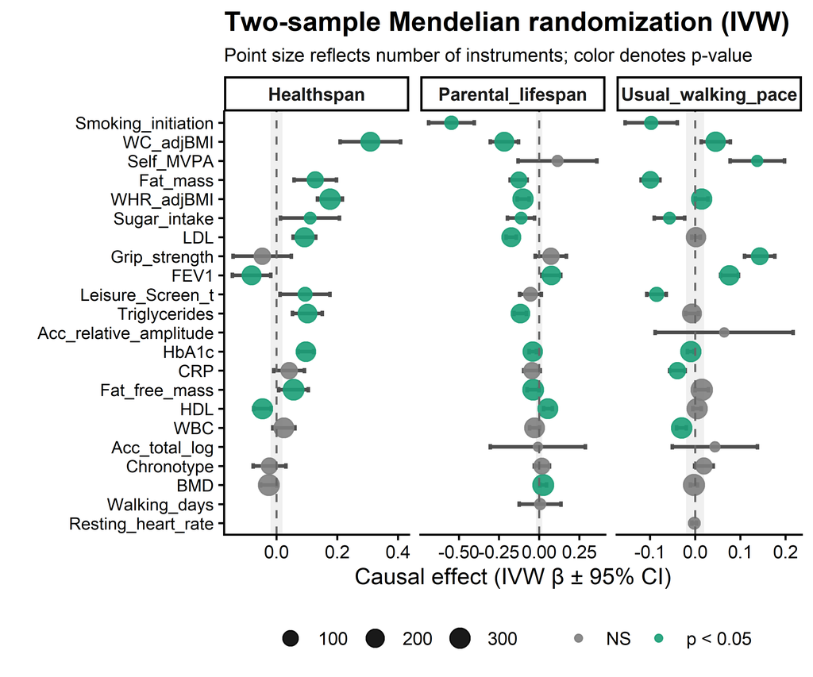

```r
library(dplyr)
library(ggplot2)

#------------------------------------------------------------
# Prepare IVW results
#------------------------------------------------------------

ivw <- mr_results %>%
  filter(method == "Inverse variance weighted (multiplicative random effects)") %>%
  mutate(
    ci_low  = b - 1.96 * se,
    ci_high = b + 1.96 * se,
    sig = ifelse(p < 0.05, "p < 0.05", "NS")
  )

#------------------------------------------------------------
# Nature-style forest plot
#------------------------------------------------------------

ggplot(ivw, aes(x = b, y = reorder(exposure, abs(b)))) +

  # subtle null band
  annotate(
    "rect",
    xmin = -0.02, xmax = 0.02,
    ymin = -Inf, ymax = Inf,
    fill = "grey80", alpha = 0.3
  ) +

  # confidence intervals
  geom_errorbarh(
    aes(xmin = ci_low, xmax = ci_high),
    height = 0.28,
    linewidth = 0.9,
    color = "grey30"
  ) +

  # effect points (size = number of SNP instruments)
  geom_point(
    aes(color = sig, size = nsnp),
    alpha = 0.9
  ) +

  geom_vline(xintercept = 0, linetype = "dashed", color = "grey40") +

  facet_wrap(~ outcome, scales = "free_x") +

  scale_color_manual(
    values = c("p < 0.05" = "#1B9E77", "NS" = "grey50")
  ) +

  scale_size_continuous(range = c(2, 5)) +

  labs(
    x = "Causal effect (IVW β ± 95% CI)",
    y = "",
    title = "Two-sample Mendelian randomization (IVW)",
    subtitle = "Point size reflects number of instruments; color denotes p-value"
  ) +

  theme_classic(base_size = 12) +

  theme(
    strip.text = element_text(face = "bold"),
    axis.text.y = element_text(size = 9),
    plot.title = element_text(face = "bold"),
    plot.subtitle = element_text(size = 10),
    legend.position = "bottom",
    legend.title = element_blank()
  )
```

## 15.2 Comprehensive MR effect grid and confidence intervals

A complete tabular summary of MR results across all estimators is presented, including effect sizes, confidence intervals, number of instruments, and significance values, serving as the full quantitative reference for causal inference.

```r
#============================================================
# SECTION 15.2 — SUPPLEMENTARY TABLE S3
# Full Mendelian Randomization results (all methods)
#============================================================

library(dplyr)
library(knitr)
library(kableExtra)
library(openxlsx)
library(DT)

#------------------------------------------------------------
# Build clean MR results table
#------------------------------------------------------------

supp_mr <- mr_results %>%
  mutate(
    ci_low  = b - 1.96 * se,
    ci_high = b + 1.96 * se,
    `β (95% CI)` = sprintf("%.3f (%.3f, %.3f)", b, ci_low, ci_high)
  ) %>%
  dplyr::select(
    exposure,
    outcome,
    method,
    nsnp,
    `β (95% CI)`,
    p
  ) %>%
  arrange(outcome, exposure, method)

#============================================================
# 1) INTERACTIVE SEARCHABLE TABLE IN R MARKDOWN
#============================================================

datatable(
  supp_mr,
  rownames = FALSE,
  filter = "top",
  options = list(
    pageLength = 25,
    scrollX = TRUE,
    autoWidth = TRUE
  ),
  caption = htmltools::tags$caption(
    style = "caption-side: top; text-align: center; font-weight: bold;",
    "Supplementary Table S3. Full Mendelian Randomization results"
  )
)
```

| exposure | outcome | method | nsnp | β (95% CI) | p |
| --- | --- | --- | --- | --- | --- |
| Acc_relative_amplitude | Healthspan | Inverse variance weighted (fixed effects) | 3 | 0.100 (-0.084, 0.283) | 0.2868115890757087 |
| Acc_relative_amplitude | Healthspan | MR Egger | 3 | 0.119 (-0.558, 0.796) | 0.7891895107757807 |
| Acc_relative_amplitude | Healthspan | Simple mode | 3 | 0.172 (-0.101, 0.445) | 0.3428561139690856 |
| Acc_relative_amplitude | Healthspan | Weighted median | 3 | 0.124 (-0.101, 0.349) | 0.2802013353581029 |
| Acc_relative_amplitude | Healthspan | Weighted mode | 3 | 0.148 (-0.118, 0.414) | 0.3901370986941521 |
| Acc_total_log | Healthspan | Inverse variance weighted (fixed effects) | 3 | -0.015 (-0.227, 0.197) | 0.8889832084282168 |
| Acc_total_log | Healthspan | MR Egger | 3 | 0.269 (-0.443, 0.980) | 0.5943928711507468 |
| Acc_total_log | Healthspan | Simple mode | 3 | 0.006 (-0.306, 0.319) | 0.9722310799537828 |
| Acc_total_log | Healthspan | Weighted median | 3 | -0.007 (-0.262, 0.249) | 0.9588117003547331 |
| Acc_total_log | Healthspan | Weighted mode | 3 | 0.013 (-0.305, 0.331) | 0.9427515364020116 |

[output cut: 355 more lines]

```r
#============================================================
# 2) EXPORT FOR SUPPLEMENTARY MATERIALS (EXCEL)
#============================================================

out_dir <- "C:/Users/75118/Desktop/UEA/Proyecto 1/MainMRresults"
dir.create(out_dir, showWarnings = FALSE)

excel_file <- file.path(out_dir, "Section_15.2_Supplementary_MR_Full_Results.xlsx")

write.xlsx(
  supp_mr,
  excel_file,
  overwrite = TRUE
)

cat("📊 Supplementary MR table saved at:\n", excel_file, "\n")
```

```
## 📊 Supplementary MR table saved at:
##  C:/Users/75118/Desktop/UEA/Proyecto 1/MainMRresults/Section_15.2_Supplementary_MR_Full_Results.xlsx
```

```r
#============================================================
# SECTION 15.2.1 — Table 1. Significant MR results (IVW RE)
# Adds: FDR q-values + robustness flag + ranking + image export
#============================================================

library(dplyr)
library(stringr)
library(knitr)
library(kableExtra)
library(gt)

#------------------------------------------------------------
# Metadata + output
#------------------------------------------------------------
section_id <- "15.2.1"
out_dir <- "C:/Users/75118/Desktop/UEA/Proyecto 1/MainMRresults"
dir.create(out_dir, showWarnings = FALSE, recursive = TRUE)

img_file <- file.path(out_dir, paste0("Section_", section_id, "_Table_1_Significant_MR_IVW_RE.png"))

#------------------------------------------------------------
# Helper: format p-values nicely
#------------------------------------------------------------
fmt_p <- function(x) {
  ifelse(x < 1e-3, "<0.001", sprintf("%.3f", x))
}

#------------------------------------------------------------
# 1) Pull the primary method: IVW random effects
#    (in your object it is "Inverse variance weighted (multiplicative random effects)")
#------------------------------------------------------------
ivw_re <- mr_results %>%
  filter(method == "Inverse variance weighted (multiplicative random effects)") %>%
  mutate(
    ci_low  = b - 1.96 * se,
    ci_high = b + 1.96 * se
  ) %>%
  dplyr::select(exposure, outcome, nsnp, b, se, ci_low, ci_high, p)

#------------------------------------------------------------
# 2) Get support from other methods (robustness)
#    Weighted median + MR Egger (if present)
#------------------------------------------------------------
wm <- mr_results %>%
  filter(method == "Weighted median") %>%
  dplyr::select(exposure, outcome, b_wm = b, p_wm = p)

egger <- mr_results %>%
  filter(method == "MR Egger") %>%
  dplyr::select(exposure, outcome, b_egger = b, p_egger = p)

#------------------------------------------------------------
# 3) Build summary table with:
#    - FDR q (computed across IVW tests)
#    - robustness flag
#------------------------------------------------------------
tab1 <- ivw_re %>%
  left_join(wm, by = c("exposure", "outcome")) %>%
  left_join(egger, by = c("exposure", "outcome")) %>%
  mutate(
    q = p.adjust(p, method = "BH"),

    # Support flags
    wm_support = !is.na(p_wm) & (p_wm < 0.05) & (sign(b_wm) == sign(b)),
    egger_support = !is.na(p_egger) & (p_egger < 0.05) & (sign(b_egger) == sign(b)),

    robustness = case_when(
      wm_support ~ "Robust (WM support)",
      egger_support ~ "Supported (Egger)",
      TRUE ~ "IVW-only"
    ),

    effect_ci = sprintf("%.3f (%.3f, %.3f)", b, ci_low, ci_high),
    p_label   = fmt_p(p),
    q_label   = fmt_p(q)
  ) %>%
  # keep significant (choose one: nominal p or FDR)
  filter(p < 0.05) %>%
  group_by(outcome) %>%
  mutate(rank_within_outcome = rank(-abs(b), ties.method = "first")) %>%
  ungroup() %>%
  arrange(outcome, rank_within_outcome) %>%
  transmute(
    Exposure = exposure,
    Outcome  = outcome,
    Instruments = nsnp,
    `β (95% CI)` = effect_ci,
    `P-value` = p_label,
    `FDR q`   = q_label,
    `Robustness` = robustness
  )

#------------------------------------------------------------
# 4) Show in R Markdown (scrollable + searchable alternative)
#    Option A: kableExtra (scroll)
#------------------------------------------------------------
kbl(
  tab1,
  caption = paste0("Table 1. Significant Mendelian Randomization results (IVW random-effects) — Section ", section_id),
  align = "c"
) %>%
  kable_styling(full_width = FALSE, position = "center",
                bootstrap_options = c("striped", "hover")) %>%
  scroll_box(height = "500px", width = "100%")
```

Table 1. Significant Mendelian Randomization results (IVW random-effects) — Section 15.2.1

| Exposure | Outcome | Instruments | β (95% CI) | P-value | FDR q | Robustness |
| --- | --- | --- | --- | --- | --- | --- |
| WC_adjBMI | Healthspan | 231 | 0.309 (0.210, 0.409) | <0.001 | <0.001 | Robust (WM support) |
| WHR_adjBMI | Healthspan | 307 | 0.176 (0.135, 0.217) | <0.001 | <0.001 | Robust (WM support) |
| Fat_mass | Healthspan | 115 | 0.128 (0.058, 0.198) | <0.001 | 0.001 | Robust (WM support) |
| Sugar_intake | Healthspan | 18 | 0.110 (0.013, 0.207) | 0.026 | 0.045 | IVW-only |
| Triglycerides | Healthspan | 222 | 0.101 (0.052, 0.150) | <0.001 | <0.001 | Robust (WM support) |
| HbA1c | Healthspan | 259 | 0.097 (0.071, 0.122) | <0.001 | <0.001 | Robust (WM support) |
| Leisure_Screen_t | Healthspan | 54 | 0.094 (0.012, 0.176) | 0.025 | 0.044 | Robust (WM support) |
| LDL | Healthspan | 239 | 0.092 (0.055, 0.129) | <0.001 | <0.001 | Robust (WM support) |
| FEV1 | Healthspan | 227 | -0.082 (-0.145, -0.019) | 0.011 | 0.023 | IVW-only |
| Fat_free_mass | Healthspan | 328 | 0.056 (0.007, 0.104) | 0.024 | 0.044 | IVW-only |
| HDL | Healthspan | 285 | -0.047 (-0.076, -0.018) | 0.002 | 0.004 | IVW-only |
| Smoking_initiation | Parental_lifespan | 44 | -0.546 (-0.688, -0.403) | <0.001 | <0.001 | Robust (WM support) |
| WC_adjBMI | Parental_lifespan | 230 | -0.216 (-0.305, -0.128) | <0.001 | <0.001 | Robust (WM support) |
| LDL | Parental_lifespan | 231 | -0.174 (-0.205, -0.142) | <0.001 | <0.001 | Robust (WM support) |
| Fat_mass | Parental_lifespan | 111 | -0.127 (-0.180, -0.075) | <0.001 | <0.001 | Robust (WM support) |
| Triglycerides | Parental_lifespan | 220 | -0.118 (-0.157, -0.079) | <0.001 | <0.001 | Robust (WM support) |
| Sugar_intake | Parental_lifespan | 18 | -0.113 (-0.197, -0.029) | 0.008 | 0.018 | Robust (WM support) |
| WHR_adjBMI | Parental_lifespan | 304 | -0.099 (-0.137, -0.062) | <0.001 | <0.001 | Robust (WM support) |
| FEV1 | Parental_lifespan | 222 | 0.076 (0.017, 0.135) | 0.012 | 0.025 | IVW-only |
| HDL | Parental_lifespan | 280 | 0.055 (0.028, 0.082) | <0.001 | <0.001 | Robust (WM support) |
| HbA1c | Parental_lifespan | 255 | -0.039 (-0.062, -0.017) | <0.001 | 0.002 | IVW-only |
| Fat_free_mass | Parental_lifespan | 324 | -0.037 (-0.074, -0.000) | 0.050 | 0.081 | Robust (WM support) |
| BMD | Parental_lifespan | 340 | 0.025 (0.004, 0.046) | 0.018 | 0.034 | Robust (WM support) |
| Grip_strength | Usual_walking_pace | 144 | 0.143 (0.109, 0.177) | <0.001 | <0.001 | Robust (WM support) |
| Self_MVPA | Usual_walking_pace | 12 | 0.138 (0.077, 0.198) | <0.001 | <0.001 | Robust (WM support) |
| Fat_mass | Usual_walking_pace | 134 | -0.099 (-0.120, -0.078) | <0.001 | <0.001 | Robust (WM support) |
| Smoking_initiation | Usual_walking_pace | 42 | -0.097 (-0.155, -0.039) | 0.001 | 0.003 | Robust (WM support) |
| Leisure_Screen_t | Usual_walking_pace | 60 | -0.085 (-0.107, -0.064) | <0.001 | <0.001 | Robust (WM support) |
| FEV1 | Usual_walking_pace | 252 | 0.076 (0.056, 0.096) | <0.001 | <0.001 | Robust (WM support) |
| Sugar_intake | Usual_walking_pace | 19 | -0.057 (-0.090, -0.023) | <0.001 | 0.002 | Robust (WM support) |
| WC_adjBMI | Usual_walking_pace | 250 | 0.046 (0.013, 0.078) | 0.005 | 0.013 | Robust (WM support) |
| CRP | Usual_walking_pace | 125 | -0.039 (-0.057, -0.022) | <0.001 | <0.001 | IVW-only |
| WBC | Usual_walking_pace | 308 | -0.030 (-0.041, -0.019) | <0.001 | <0.001 | Robust (WM support) |
| WHR_adjBMI | Usual_walking_pace | 303 | 0.015 (0.001, 0.028) | 0.040 | 0.067 | Robust (WM support) |
| HbA1c | Usual_walking_pace | 299 | -0.009 (-0.017, -0.002) | 0.014 | 0.028 | IVW-only |

```r
#------------------------------------------------------------
# 5) Export a publication-ready PNG using gt
#------------------------------------------------------------
gt_tbl <- gt(tab1) %>%
  tab_header(
    title = md("**Table 1. Significant Mendelian Randomization results**"),
    subtitle = md(paste0("IVW random-effects estimates (Section ", section_id, "); FDR shown across IVW tests"))
  ) %>%
  cols_label(
    `β (95% CI)` = md("&beta; (95% CI)")
  ) %>%
  tab_style(
    style = list(cell_text(weight = "bold")),
    locations = cells_body(columns = c(Exposure, Outcome))
  ) %>%
  tab_style(
    style = cell_text(weight = "bold"),
    locations = cells_body(columns = `P-value`, rows = `P-value` %in% c("<0.001"))
  ) %>%
  opt_all_caps(FALSE) %>%
  opt_table_outline() %>%
  tab_source_note(
    source_note = md("Robustness flag: WM support = Weighted median p < 0.05 with same direction as IVW. FDR q-values computed across IVW tests.")
  )


if(interactive()){
  gtsave(
    gt_tbl,
    filename = img_file,
    vwidth = 2200,
    vheight = 1600,
    expand = 10,
    delay = 2
  )
}


cat("🖼️ Saved Table 1 image at:\n", img_file, "\n")
```

```
## 🖼️ Saved Table 1 image at:
##  C:/Users/75118/Desktop/UEA/Proyecto 1/MainMRresults/Section_15.2.1_Table_1_Significant_MR_IVW_RE.png
```

## 15.3 Robustness diagnostics across heterogeneity, pleiotropy, Steiger filtering, and MR-PRESSO

Sensitivity metrics are integrated across methods to flag potential violations of MR assumptions, including instrument heterogeneity, horizontal pleiotropy, directionality inconsistencies, and outlier-driven distortions.

```r
# TABLE 2 — Sensitivity summary


sensitivity <- mr_results %>%
  dplyr::filter(method == "Inverse variance weighted (multiplicative random effects)") %>%
  dplyr::left_join(
    mr_het %>% dplyr::select(exposure, outcome, Q_pval),
    by = c("exposure","outcome")
  ) %>%
  dplyr::left_join(
    mr_pleio %>% dplyr::select(exposure, outcome, egger_p = pval),
    by = c("exposure","outcome")
  ) %>%
  dplyr::left_join(
    mr_steiger,
    by = c("exposure","outcome")
  ) %>%
  dplyr::left_join(
    mr_presso %>%
      dplyr::select(exposure, outcome, global_p = presso_global_p),
    by = c("exposure","outcome")
  )


library(kableExtra)
library(dplyr)

sensitivity2 <- sensitivity %>%
  mutate(
    heterogeneity_flag = ifelse(Q_pval < 0.05, "⚠️ Yes", "No"),
    pleiotropy_flag    = ifelse(egger_p < 0.05, "⚠️ Yes", "No"),
    presso_flag        = ifelse(global_p < 0.05, "⚠️ Yes", "No")
  ) %>%
  arrange(outcome, p)


DT::datatable(
  sensitivity2,
  rownames = FALSE,
  filter = "top",
  options = list(
    pageLength = 20,
    scrollX = TRUE,
    autoWidth = TRUE
  ),
  caption = htmltools::tags$caption(
    style = "caption-side: top; text-align: center; font-weight: bold;",
    "Table 2. Sensitivity and robustness diagnostics for IVW MR results"
  )
)
```

| exposure | outcome | method | nsnp | b | se | p | Q_pval | egger_p | nsnp_steiger | direction_correct_fraction | global_p | heterogeneity_flag | pleiotropy_flag | presso_flag |
| --- | --- | --- | --- | --- | --- | --- | --- | --- | --- | --- | --- | --- | --- | --- |
| WHR_adjBMI | Healthspan | Inverse variance weighted (multiplicative random effects) | 307 | 0.1759587070731447 | 0.02093205569111027 | 4.235672434539635e-17 | 1.631142541277364e-09 | 0.1227848163116493 | 307 | 1 |  | ⚠️ Yes | No |  |
| WHR_adjBMI | Healthspan | Inverse variance weighted (multiplicative random effects) | 307 | 0.1759587070731447 | 0.02093205569111027 | 4.235672434539635e-17 | 1.030008453046839e-09 | 0.1227848163116493 | 307 | 1 |  | ⚠️ Yes | No |  |
| HbA1c | Healthspan | Inverse variance weighted (multiplicative random effects) | 259 | 0.09675572947124862 | 0.01296647093949935 | 8.522271137860873e-14 | 0.001829971078852173 | 0.0001605049894153716 | 259 | 1 |  | ⚠️ Yes | ⚠️ Yes |  |
| HbA1c | Healthspan | Inverse variance weighted (multiplicative random effects) | 259 | 0.09675572947124862 | 0.01296647093949935 | 8.522271137860873e-14 | 0.0001893332687799117 | 0.0001605049894153716 | 259 | 1 |  | ⚠️ Yes | ⚠️ Yes |  |
| WC_adjBMI | Healthspan | Inverse variance weighted (multiplicative random effects) | 231 | 0.309361908132993 | 0.05086353286599269 | 1.185485121883315e-09 | 1.442377980561388e-09 | 0.3546846076607316 | 231 | 1 |  | ⚠️ Yes | No |  |
| WC_adjBMI | Healthspan | Inverse variance weighted (multiplicative random effects) | 231 | 0.309361908132993 | 0.05086353286599269 | 1.185485121883315e-09 | 1.398640342780434e-09 | 0.3546846076607316 | 231 | 1 |  | ⚠️ Yes | No |  |
| LDL | Healthspan | Inverse variance weighted (multiplicative random effects) | 239 | 0.09187003889823424 | 0.01885958715016632 | 1.108862312421465e-06 | 0.0002503415372426266 | 0.05889051790092655 | 239 | 0.99581589958159 |  | ⚠️ Yes | No |  |
| LDL | Healthspan | Inverse variance weighted (multiplicative random effects) | 239 | 0.09187003889823424 | 0.01885958715016632 | 1.108862312421465e-06 | 0.000147680254561077 | 0.05889051790092655 | 239 | 0.99581589958159 |  | ⚠️ Yes | No |  |
| Triglycerides | Healthspan | Inverse variance weighted (multiplicative random effects) | 222 | 0.1012835006206624 | 0.02507580811290909 | 5.365847449216888e-05 | 8.17014541401068e-11 | 0.03643521682978557 | 222 | 0.9774774774774775 |  | ⚠️ Yes | ⚠️ Yes |  |
| Triglycerides | Healthspan | Inverse variance weighted (multiplicative random effects) | 222 | 0.1012835006206624 | 0.02507580811290909 | 5.365847449216888e-05 | 2.00954716508822e-11 | 0.03643521682978557 | 222 | 0.9774774774774775 |  | ⚠️ Yes | ⚠️ Yes |  |

[output cut: 104 more lines]

```r
#============================================================
# SECTION 15.3.1 — Sensitivity diagnostics (DT full, FDR)
# SECTION 15.3.2 — Simplified sensitivity summary (robust + top N)
#============================================================

library(dplyr)
library(DT)
library(htmltools)
library(gt)

out_dir <- "C:/Users/75118/Desktop/UEA/Proyecto 1/MainMRresults"
dir.create(out_dir, showWarnings = FALSE, recursive = TRUE)

#------------------------------------------------------------
# Join IVW RE effect sizes into sensitivity (so we can rank)
#------------------------------------------------------------
ivw_re_eff <- mr_results %>%
  filter(method == "Inverse variance weighted (multiplicative random effects)") %>%
  transmute(
    exposure, outcome,
    b_ivw = b,
    se_ivw = se,
    p_ivw = p,
    ci_low = b - 1.96 * se,
    ci_high = b + 1.96 * se
  )

sens_base <- sensitivity %>%
  left_join(ivw_re_eff, by = c("exposure", "outcome")) %>%
  mutate(
    # FDR across IVW tests (use p_ivw if available; fallback to p)
    p_for_fdr = ifelse(!is.na(p_ivw), p_ivw, p),
    q = p.adjust(p_for_fdr, method = "BH"),

    Heterogeneity = ifelse(Q_pval < 0.05, "⚠️ Yes", "No"),
    Pleiotropy    = ifelse(egger_p < 0.05, "⚠️ Yes", "No"),
    Outliers      = ifelse(global_p < 0.05, "⚠️ Yes", "No"),

    Direction_OK = ifelse(direction_correct_fraction >= 0.5, "Yes", "No"),
    Direction_fraction = round(direction_correct_fraction, 2),

    reliability_score =
      (Q_pval >= 0.05) +
      (egger_p >= 0.05) +
      (global_p >= 0.05) +
      (direction_correct_fraction >= 0.5),

    Reliability = case_when(
      reliability_score == 4 ~ "Very strong",
      reliability_score == 3 ~ "Strong",
      reliability_score == 2 ~ "Moderate",
      TRUE ~ "Weak"
    ),

    effect_ci = ifelse(
      !is.na(b_ivw),
      sprintf("%.3f (%.3f, %.3f)", b_ivw, ci_low, ci_high),
      NA_character_
    )
  )

#============================================================
# SECTION 15.3.1 — FULL TABLE (still large, but searchable)
#============================================================

sens_tab_full <- sens_base %>%
  dplyr::filter(q < 0.05) %>%
  dplyr::arrange(outcome, desc(reliability_score), q) %>%
  dplyr::select(
    exposure, outcome,
    effect_ci,
    p_for_fdr, q,
    Heterogeneity, Pleiotropy, Outliers,
    Direction_OK, Direction_fraction,
    Reliability
  ) %>%
  dplyr::rename(p = p_for_fdr)


DT::datatable(
  sens_tab_full,
  rownames = FALSE,
  filter = "top",
  options = list(pageLength = 20, scrollX = TRUE, autoWidth = TRUE),
  caption = tags$caption(
    style = "caption-side: top; text-align: center; font-weight: bold;",
    "Table 2. Sensitivity and robustness diagnostics for IVW MR results (FDR q < 0.05) — Section 15.3.1"
  )
)
```

| exposure | outcome | effect_ci | p | q | Heterogeneity | Pleiotropy | Outliers | Direction_OK | Direction_fraction | Reliability |
| --- | --- | --- | --- | --- | --- | --- | --- | --- | --- | --- |
| Sugar_intake | Healthspan | 0.110 (0.013, 0.207) | 0.02608147356807589 | 0.04504981798122199 | ⚠️ Yes | No | ⚠️ Yes | Yes | 1 | Moderate |
| Sugar_intake | Healthspan | 0.110 (0.013, 0.207) | 0.02608147356807589 | 0.04504981798122199 | ⚠️ Yes | No | ⚠️ Yes | Yes | 1 | Moderate |
| WHR_adjBMI | Healthspan | 0.176 (0.135, 0.217) | 4.235672434539635e-17 | 8.047777625625307e-16 | ⚠️ Yes | No |  | Yes | 1 | Weak |
| WHR_adjBMI | Healthspan | 0.176 (0.135, 0.217) | 4.235672434539635e-17 | 8.047777625625307e-16 | ⚠️ Yes | No |  | Yes | 1 | Weak |
| HbA1c | Healthspan | 0.097 (0.071, 0.122) | 8.522271137860873e-14 | 6.072118185725872e-13 | ⚠️ Yes | ⚠️ Yes |  | Yes | 1 | Weak |
| HbA1c | Healthspan | 0.097 (0.071, 0.122) | 8.522271137860873e-14 | 6.072118185725872e-13 | ⚠️ Yes | ⚠️ Yes |  | Yes | 1 | Weak |
| WC_adjBMI | Healthspan | 0.309 (0.210, 0.409) | 1.185485121883315e-09 | 7.508072438594327e-09 | ⚠️ Yes | No |  | Yes | 1 | Weak |
| WC_adjBMI | Healthspan | 0.309 (0.210, 0.409) | 1.185485121883315e-09 | 7.508072438594327e-09 | ⚠️ Yes | No |  | Yes | 1 | Weak |
| LDL | Healthspan | 0.092 (0.055, 0.129) | 1.108862312421465e-06 | 4.861934754463347e-06 | ⚠️ Yes | No |  | Yes | 1 | Weak |
| LDL | Healthspan | 0.092 (0.055, 0.129) | 1.108862312421465e-06 | 4.861934754463347e-06 | ⚠️ Yes | No |  | Yes | 1 | Weak |

[output cut: 56 more lines]

```r
#=================================================
# SECTION 15.3.2 — Simplified sensitivity summary
#=================================================


#=================================================
# SECTION 15.3.2 — Simplified sensitivity summary (FIXED)
#=================================================

section_id_simplified <- "15.3.2"
top_n_per_outcome <- 20

# ---- build directly from sens_base (NOT sens_tab) ----

sens_tab_simple <- sens_base %>%

  distinct(exposure, outcome, .keep_all = TRUE) %>%   # one causal pair only

  filter(!is.na(q) & q < 0.05) %>%                     # FDR significant only

  mutate(
    Robustness = factor(
      Reliability,
      levels = c("Very strong", "Strong", "Moderate", "Weak")
    ),
    abs_b = abs(b_ivw)
  ) %>%

  group_by(outcome) %>%
  arrange(
    Robustness,
    desc(abs_b),
    q,
    .by_group = TRUE
  ) %>%
  slice_head(n = top_n_per_outcome) %>%
  ungroup() %>%

  transmute(
    Exposure = exposure,
    Outcome  = outcome,
    Instruments = nsnp,
    `β (95% CI)` = effect_ci,
    `P` = p_for_fdr,
    `FDR q` = q,
    Heterogeneity,
    Pleiotropy,
    Outliers,
    `Steiger dir` = Direction_OK,
    `Steiger frac` = Direction_fraction,
    Robustness
  )

# ---- interactive Rmd table ----

DT::datatable(
  sens_tab_simple,
  rownames = FALSE,
  filter = "top",
  options = list(
    pageLength = 15,
    scrollX = TRUE,
    autoWidth = TRUE
  ),
  caption = htmltools::tags$caption(
    style = "caption-side: top; text-align: center; font-weight: bold;",
    paste0(
      "Table 2a. Simplified sensitivity summary (FDR q < 0.05; top ",
      top_n_per_outcome, " per outcome) — Section ", section_id_simplified
    )
  )
)
```

| Exposure | Outcome | Instruments | β (95% CI) | P | FDR q | Heterogeneity | Pleiotropy | Outliers | Steiger dir | Steiger frac | Robustness |
| --- | --- | --- | --- | --- | --- | --- | --- | --- | --- | --- | --- |
| Sugar_intake | Healthspan | 18 | 0.110 (0.013, 0.207) | 0.02608147356807589 | 0.04504981798122199 | ⚠️ Yes | No | ⚠️ Yes | Yes | 1 | Moderate |
| WC_adjBMI | Healthspan | 231 | 0.309 (0.210, 0.409) | 1.185485121883315e-09 | 7.508072438594327e-09 | ⚠️ Yes | No |  | Yes | 1 | Weak |
| WHR_adjBMI | Healthspan | 307 | 0.176 (0.135, 0.217) | 4.235672434539635e-17 | 8.047777625625307e-16 | ⚠️ Yes | No |  | Yes | 1 | Weak |
| Fat_mass | Healthspan | 115 | 0.128 (0.058, 0.198) | 0.0003563631819600114 | 0.001015635068586032 | ⚠️ Yes | No |  | Yes | 1 | Weak |
| Triglycerides | Healthspan | 222 | 0.101 (0.052, 0.150) | 5.365847449216888e-05 | 0.0001699185025585348 | ⚠️ Yes | ⚠️ Yes |  | Yes | 0.98 | Weak |
| HbA1c | Healthspan | 259 | 0.097 (0.071, 0.122) | 8.522271137860873e-14 | 6.072118185725872e-13 | ⚠️ Yes | ⚠️ Yes |  | Yes | 1 | Weak |
| Leisure_Screen_t | Healthspan | 54 | 0.094 (0.012, 0.176) | 0.02495942319486172 | 0.04445897256584744 | ⚠️ Yes | No |  | Yes | 1 | Weak |
| LDL | Healthspan | 239 | 0.092 (0.055, 0.129) | 1.108862312421465e-06 | 4.861934754463347e-06 | ⚠️ Yes | No |  | Yes | 1 | Weak |
| FEV1 | Healthspan | 227 | -0.082 (-0.145, -0.019) | 0.01073403103786168 | 0.02266073219104131 | ⚠️ Yes | No |  | Yes | 1 | Weak |
| Fat_free_mass | Healthspan | 328 | 0.056 (0.007, 0.104) | 0.02391098767054469 | 0.0439653644264854 | ⚠️ Yes | No |  | Yes | 1 | Weak |

[output cut: 23 more lines]

```r
#============================================================
# Export simplified PNG — Section 15.3.2
#============================================================

img_file_simple <- file.path(
  out_dir,
  paste0("Section_", section_id_simplified, "_Table_2a_Sensitivity_Summary.png")
)

gt_simple <- gt(sens_tab_simple) %>%
  tab_header(
    title = md("**Table 2a. Simplified sensitivity summary**"),
    subtitle = md(paste0(
      "Top ", top_n_per_outcome,
      " most robust associations per outcome (Section ", section_id_simplified, ")"
    ))
  ) %>%
  opt_all_caps(FALSE) %>%
  opt_table_outline() %>%
  tab_source_note(
    source_note = md(
      "Filtered by FDR q < 0.05. Ranked within each outcome by robustness diagnostics and Steiger directionality."
    )
  )

gtsave(
  gt_simple,
  filename = img_file_simple,
  vwidth = 2400,
  vheight = 1600,
  expand = 10
)

cat("🖼️ Saved simplified table image at:\n", img_file_simple, "\n")
```

```
## 🖼️ Saved simplified table image at:
##  C:/Users/75118/Desktop/UEA/Proyecto 1/MainMRresults/Section_15.3.2_Table_2a_Sensitivity_Summary.png
```

```r
#============================================================
# SECTION 15.3.2 — Simplified sensitivity summary (UPGRADED)
# - Less harsh robustness scoring (weighted)
# - Color-coded warning flags in PNG table
# - Star system for strongest causal evidence
# - One-page causal evidence figure (Nature-style)
#============================================================

library(dplyr)
library(stringr)
library(DT)
library(htmltools)
library(gt)
library(ggplot2)
library(patchwork)


#------------------------------------------------------------
# Metadata + output
#------------------------------------------------------------
section_id <- "15.3.2"
out_dir <- "C:/Users/75118/Desktop/UEA/Proyecto 1/MainMRresults"
dir.create(out_dir, showWarnings = FALSE, recursive = TRUE)

png_table_file <- file.path(out_dir, paste0("Section_", section_id, "_Table_2a_Simplified_Sensitivity_Summary.png"))
pdf_fig_file   <- file.path(out_dir, paste0("Section_", section_id, "_Figure_Causal_Evidence_OnePage.pdf"))
png_fig_file   <- file.path(out_dir, paste0("Section_", section_id, "_Figure_Causal_Evidence_OnePage.png"))

top_n_per_outcome <- 20  # adjust: 10–25 is usually best for a "simplified" table

#------------------------------------------------------------
# REQUIREMENT: sens_base should exist from Section 15.3.1 build
# sens_base should contain at least:
# exposure, outcome, nsnp, b_ivw, se_ivw, p_for_fdr, q,
# Q_pval, egger_p, global_p, direction_correct_fraction
#------------------------------------------------------------
if (!exists("sens_base")) {
  stop("Object 'sens_base' not found. Please run Section 15.3.1 code that builds 'sens_base' first.")
}

#------------------------------------------------------------
# Helpers
#------------------------------------------------------------
fmt_p <- function(x) {
  dplyr::case_when(
    is.na(x) ~ NA_character_,
    x < 1e-100 ~ "<1e-100",
    x < 1e-10  ~ format(x, scientific = TRUE, digits = 2),
    x < 1e-3   ~ "<0.001",
    TRUE       ~ sprintf("%.3f", x)
  )
}

safe_ok <- function(x, cutoff = 0.05) {
  # treat NA as "unknown" rather than failure
  ifelse(is.na(x), NA, x >= cutoff)
}

safe_flag <- function(x, cutoff = 0.05) {
  # TRUE means warning flag
  ifelse(is.na(x), NA, x < cutoff)
}

#------------------------------------------------------------
# 1) Build upgraded simplified table base
#    - Less harsh score: Steiger + Pleiotropy/Outliers weighted,
#      heterogeneity is down-weighted (very common in polygenic MR)
#------------------------------------------------------------
sens2 <- sens_base %>%
  mutate(
    ci_low  = b_ivw - 1.96 * se_ivw,
    ci_high = b_ivw + 1.96 * se_ivw,
    effect_ci = sprintf("%.3f (%.3f, %.3f)", b_ivw, ci_low, ci_high),

    # Flags (TRUE = warning)
    flag_het   = safe_flag(Q_pval, 0.05),
    flag_pleio = safe_flag(egger_p, 0.05),
    flag_out   = safe_flag(global_p, 0.05),

    # Steiger directionality (use 0.5 threshold)
    steiger_ok = ifelse(is.na(direction_correct_fraction), NA, direction_correct_fraction >= 0.50),
    steiger_frac = round(direction_correct_fraction, 2),

    # Display-friendly labels
    Heterogeneity = dplyr::case_when(
      is.na(flag_het)   ~ "NA",
      flag_het          ~ "\u26A0 Yes",
      TRUE              ~ "No"
    ),
    Pleiotropy = dplyr::case_when(
      is.na(flag_pleio) ~ "NA",
      flag_pleio        ~ "\u26A0 Yes",
      TRUE              ~ "No"
    ),
    Outliers = dplyr::case_when(
      is.na(flag_out)   ~ "NA",
      flag_out          ~ "\u26A0 Yes",
      TRUE              ~ "No"
    ),
    Direction_OK = dplyr::case_when(
      is.na(steiger_ok) ~ "NA",
      steiger_ok        ~ "Yes",
      TRUE              ~ "No"
    ),

    #--------------------------------------------------------
    # Less harsh robustness scoring (weighted)
    #  - Steiger is most important (weight 2)
    #  - Pleiotropy and outliers are important (weight 1 each)
    #  - Heterogeneity is common: weight 0.5
    #
    # Score ranges roughly 0–4.5; NA treated as "unknown" (0)
    #--------------------------------------------------------
    score =
      2*(steiger_ok %in% TRUE) +
      1*(flag_out %in% FALSE | is.na(flag_out)) +
      0.5*(flag_pleio %in% FALSE),

    Robustness = case_when(
      score >= 4 ~ "Very strong",
      score >= 3 ~ "Strong",
      score >= 2 ~ "Moderate",
      TRUE       ~ "Weak"
    ),

    #--------------------------------------------------------
    # Star system (strongest causal evidence)
    #  ★★★ : FDR + Steiger OK + no pleiotropy + no outliers
    #   ★★ : FDR + Steiger OK + (<=1 warning among pleio/outliers/het)
    #    ★ : FDR only
    #--------------------------------------------------------
    n_warnings = rowSums(cbind(
      flag_het   %in% TRUE,
      flag_pleio %in% TRUE,
      flag_out   %in% TRUE
    ), na.rm = TRUE),

    Stars = case_when(
      q < 0.05 & isTRUE(steiger_ok) & isFALSE(flag_pleio) & (isFALSE(flag_out) | is.na(flag_out)) ~ "\u2605\u2605\u2605",
      q < 0.05 & isTRUE(steiger_ok) & n_warnings <= 1                                          ~ "\u2605\u2605",
      q < 0.05                                                                                  ~ "\u2605",
      TRUE                                                                                      ~ ""
    ),

    p_label = fmt_p(p_for_fdr),
    q_label = fmt_p(q)
  )

#------------------------------------------------------------
# 2) Build simplified table (FDR significant + top N per outcome)
#    Rank: Stars first, then Robustness, then |beta|
#------------------------------------------------------------
robust_order <- c("Very strong", "Strong", "Moderate", "Weak")

#------------------------------------------------------------
# CLEAN + RANK EXACTLY LIKE ORIGINAL (but upgraded metrics)
#------------------------------------------------------------

star_rank <- function(x){
  case_when(
    x == "★★★" ~ 3,
    x == "★★"  ~ 2,
    x == "★"   ~ 1,
    TRUE       ~ 0
  )
}

sens_tab_simple <- sens2 %>%

  # 🔧 critical fix — keep only one row per causal pair
  distinct(exposure, outcome, .keep_all = TRUE) %>%

  # only FDR significant (same as before)
  filter(!is.na(q) & q < 0.05) %>%

  mutate(
    Robustness = factor(Robustness, levels = robust_order),
    star_score = star_rank(Stars),
    abs_b = abs(b_ivw)
  ) %>%

  group_by(outcome) %>%

  arrange(
    desc(star_score),     # strongest stars first (numeric now)
    Robustness,           # Very strong → Weak
    desc(abs_b),
    q,
    .by_group = TRUE
  ) %>%

  slice_head(n = top_n_per_outcome) %>%
  ungroup() %>%

  transmute(
    Exposure = exposure,
    Outcome  = outcome,
    Instruments = nsnp,
    `β (95% CI)` = effect_ci,
    `P` = p_label,
    `FDR q` = q_label,
    Heterogeneity,
    Pleiotropy,
    Outliers,
    `Steiger dir` = Direction_OK,
    `Steiger frac` = steiger_frac,
    Robustness,
    Stars
  )


#------------------------------------------------------------
# 3) R Markdown output: ONE interactive searchable table (DT)
#------------------------------------------------------------
DT::datatable(
  sens_tab_simple,
  rownames = FALSE,
  filter = "top",
  extensions = c("Buttons"),
  options = list(
    dom = "Bfrtip",
    buttons = c("copy", "csv", "excel"),
    pageLength = 15,
    scrollX = TRUE,
    autoWidth = TRUE
  ),
  caption = tags$caption(
    style = "caption-side: top; text-align: center; font-weight: bold;",
    paste0(
      "Table 2a. Simplified sensitivity summary (FDR q < 0.05; top ",
      top_n_per_outcome, " per outcome) — Section ", section_id,
      " | Stars denote strongest causal evidence"
    )
  )
)
```

| Exposure | Outcome | Instruments | β (95% CI) | P | FDR q | Heterogeneity | Pleiotropy | Outliers | Steiger dir | Steiger frac | Robustness | Stars |
| --- | --- | --- | --- | --- | --- | --- | --- | --- | --- | --- | --- | --- |
| WC_adjBMI | Healthspan | 231 | 0.309 (0.210, 0.409) | &lt;0.001 | &lt;0.001 | ⚠ Yes | No | NA | Yes | 1 | Strong | ★ |
| WHR_adjBMI | Healthspan | 307 | 0.176 (0.135, 0.217) | 4.2e-17 | 8.0e-16 | ⚠ Yes | No | NA | Yes | 1 | Strong | ★ |
| Fat_mass | Healthspan | 115 | 0.128 (0.058, 0.198) | &lt;0.001 | 0.001 | ⚠ Yes | No | NA | Yes | 1 | Strong | ★ |
| Triglycerides | Healthspan | 222 | 0.101 (0.052, 0.150) | &lt;0.001 | &lt;0.001 | ⚠ Yes | ⚠ Yes | NA | Yes | 0.98 | Strong | ★ |
| HbA1c | Healthspan | 259 | 0.097 (0.071, 0.122) | 8.5e-14 | 6.1e-13 | ⚠ Yes | ⚠ Yes | NA | Yes | 1 | Strong | ★ |
| Leisure_Screen_t | Healthspan | 54 | 0.094 (0.012, 0.176) | 0.025 | 0.044 | ⚠ Yes | No | NA | Yes | 1 | Strong | ★ |
| LDL | Healthspan | 239 | 0.092 (0.055, 0.129) | &lt;0.001 | &lt;0.001 | ⚠ Yes | No | NA | Yes | 1 | Strong | ★ |
| FEV1 | Healthspan | 227 | -0.082 (-0.145, -0.019) | 0.011 | 0.023 | ⚠ Yes | No | NA | Yes | 1 | Strong | ★ |
| Fat_free_mass | Healthspan | 328 | 0.056 (0.007, 0.104) | 0.024 | 0.044 | ⚠ Yes | No | NA | Yes | 1 | Strong | ★ |
| HDL | Healthspan | 285 | -0.047 (-0.076, -0.018) | 0.002 | 0.004 | ⚠ Yes | No | NA | Yes | 1 | Strong | ★ |

[output cut: 23 more lines]

```r
#------------------------------------------------------------
# 4) Export publication-ready PNG table (color-coded flags)
#------------------------------------------------------------
gt_tbl <- gt(sens_tab_simple) %>%
  tab_header(
    title = md("**Table 2a. Simplified sensitivity summary**"),
    subtitle = md(paste0(
      "Top ", top_n_per_outcome,
      " most robust associations per outcome (Section ", section_id, "); FDR q < 0.05"
    ))
  ) %>%
  cols_label(`β (95% CI)` = md("&beta; (95% CI)")) %>%
  tab_style(
    style = cell_text(weight = "bold"),
    locations = cells_body(columns = c(Exposure, Outcome, Stars))
  ) %>%
  # Color-code warning flags (Yes) and OK (No)
  tab_style(
    style = cell_fill(color = "#FDEDEC"),  # light red for warnings
    locations = cells_body(columns = c(Heterogeneity, Pleiotropy, Outliers), rows = str_detect(Heterogeneity, "Yes") | str_detect(Pleiotropy, "Yes") | str_detect(Outliers, "Yes"))
  ) %>%
  tab_style(
    style = cell_fill(color = "#EAF2F8"),  # light blue for "No"
    locations = list(
      cells_body(columns = Heterogeneity, rows = Heterogeneity == "No"),
      cells_body(columns = Pleiotropy,    rows = Pleiotropy == "No"),
      cells_body(columns = Outliers,      rows = Outliers == "No")
    )
  ) %>%
  # Highlight robustness level
  tab_style(
    style = cell_fill(color = "#E8F8F5"),  # green-ish
    locations = cells_body(columns = Robustness, rows = Robustness %in% c("Very strong","Strong"))
  ) %>%
  tab_style(
    style = cell_fill(color = "#FEF9E7"),  # yellow-ish
    locations = cells_body(columns = Robustness, rows = Robustness == "Moderate")
  ) %>%
  tab_style(
    style = cell_fill(color = "#F4F6F7"),  # gray-ish
    locations = cells_body(columns = Robustness, rows = Robustness == "Weak")
  ) %>%
  opt_all_caps(FALSE) %>%
  opt_table_outline() %>%
  tab_source_note(
    source_note = md(
      paste0(
        "**Stars:** ★★★ = FDR + Steiger OK + no pleiotropy + no outliers; ★★ = FDR + Steiger OK + ≤1 warning; ★ = FDR only. ",
        "Heterogeneity is down-weighted (common in polygenic MR)."
      )
    )
  )

gtsave(
  gt_tbl,
  filename = png_table_file,
  vwidth = 2400,
  vheight = 1600,
  expand = 10
)

cat("🖼️ Saved Table 2a PNG at:\n", png_table_file, "\n")
```

```
## 🖼️ Saved Table 2a PNG at:
##  C:/Users/75118/Desktop/UEA/Proyecto 1/MainMRresults/Section_15.3.2_Table_2a_Simplified_Sensitivity_Summary.png
```

```r
#------------------------------------------------------------
# 5) One-page causal evidence figure (Nature-style)
#    Panel A: "evidence dot plot" (effect direction, size ~ -log10(q), label stars)
#    Panel B: small legend-like annotation block
#------------------------------------------------------------
fig_df <- sens2 %>%
  filter(!is.na(q) & q < 0.05) %>%
  mutate(
    outcome = factor(outcome, levels = unique(outcome)),
    exposure = factor(exposure),
    sign_dir = ifelse(b_ivw >= 0, "Positive", "Negative"),
    mlq = -log10(q),
    Robustness = factor(Robustness, levels = robust_order)
  ) %>%
  group_by(outcome) %>%
  arrange(desc(Stars), Robustness, desc(abs(b_ivw)), q, .by_group = TRUE) %>%
  slice_head(n = top_n_per_outcome) %>%
  ungroup()

pA <- ggplot(fig_df, aes(x = outcome, y = reorder(exposure, abs(b_ivw)))) +
  geom_point(aes(size = mlq, shape = Robustness, fill = sign_dir), color = "black", stroke = 0.25) +
  geom_text(aes(label = Stars), nudge_x = 0.15, size = 3) +
  scale_size_continuous(name = expression(-log[10](q)), range = c(2, 7)) +
  scale_shape_manual(
    values = c("Very strong" = 23, "Strong" = 22, "Moderate" = 21, "Weak" = 25),
    name = "Robustness"
  ) +
  scale_fill_manual(values = c("Positive" = "#2E86AB", "Negative" = "#D1495B"), name = "Direction") +
  labs(
    x = NULL, y = NULL,
    title = "Causal evidence summary (FDR-significant IVW random-effects)",
    subtitle = paste0("Section ", section_id, " — Point size ~ strength; symbols ~ robustness; stars ~ strongest evidence")
  ) +
  theme_bw(base_size = 12) +
  theme(
    plot.title = element_text(face = "bold"),
    axis.text.x = element_text(face = "bold"),
    axis.text.y = element_text(size = 10),
    legend.position = "right"
  )

pB <- ggplot() +
  annotate(
    "text",
    x = 0.02, y = 0.95,
    hjust = 0, vjust = 1,
    size = 4,
    label = paste0(
      "Star rules\n",
      "★★★  FDR + Steiger OK + no pleiotropy + no outliers\n",
      "★★   FDR + Steiger OK + ≤1 warning\n",
      "★    FDR only\n\n",
      "Warnings\n",
      "Heterogeneity: Q p < 0.05\n",
      "Pleiotropy: Egger p < 0.05\n",
      "Outliers: MR-PRESSO global p < 0.05\n\n",
      "Note: Heterogeneity down-weighted in robustness score"
    )
  ) +
  theme_void() +
  coord_cartesian(clip = "off")


one_page <- pA / pB + plot_layout(heights = c(3, 1))

ggsave(pdf_fig_file, one_page, width = 11, height = 9)
ggsave(png_fig_file, one_page, width = 11, height = 9, dpi = 300)

cat("📄 Saved one-page figure PDF at:\n", pdf_fig_file, "\n")
```

```
## 📄 Saved one-page figure PDF at:
##  C:/Users/75118/Desktop/UEA/Proyecto 1/MainMRresults/Section_15.3.2_Figure_Causal_Evidence_OnePage.pdf
```

```r
cat("🖼️ Saved one-page figure PNG at:\n", png_fig_file, "\n")
```

```
## 🖼️ Saved one-page figure PNG at:
##  C:/Users/75118/Desktop/UEA/Proyecto 1/MainMRresults/Section_15.3.2_Figure_Causal_Evidence_OnePage.png
```

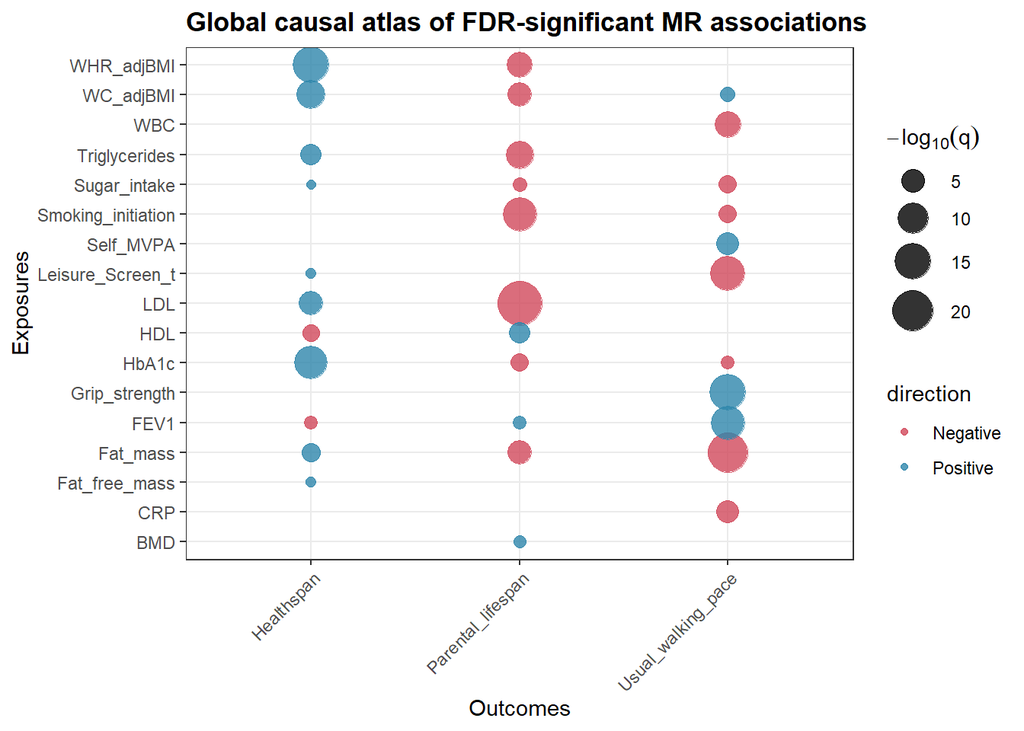

```r
############################################################
# S15.S1 — Full causal atlas heatmap (supplementary)
############################################################

library(dplyr)
library(ggplot2)

atlas_df <- sens2 %>%
  distinct(exposure, outcome, .keep_all = TRUE) %>%
  filter(!is.na(q) & q < 0.05) %>%
  mutate(
    strength = -log10(q),
    direction = ifelse(b_ivw >= 0, "Positive", "Negative")
  )

ggplot(atlas_df, aes(outcome, exposure)) +
  geom_point(aes(size = strength, color = direction), alpha = 0.8) +
  scale_size_continuous(name = expression(-log[10](q)), range = c(2, 10)) +
  scale_color_manual(values = c(
    Positive = "#2E86AB",
    Negative = "#D1495B"
  )) +
  labs(
    title = "Global causal atlas of FDR-significant MR associations",
    x = "Outcomes",
    y = "Exposures"
  ) +
  theme_bw() +
  theme(
    axis.text.x = element_text(angle = 45, hjust = 1),
    plot.title = element_text(face = "bold")
  )
```

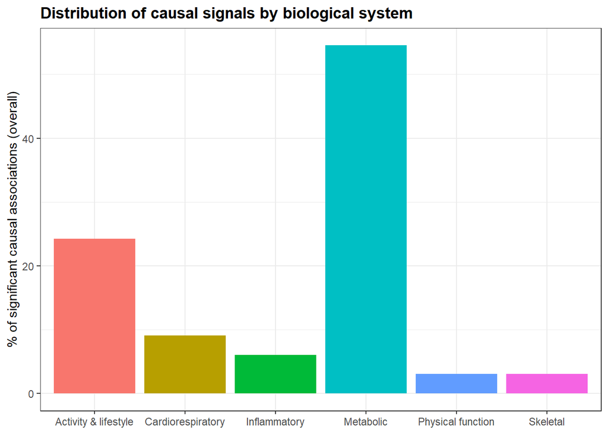

```r
############################################################
# S15.S2 — % causal contribution per biological system
############################################################

library(dplyr)
library(ggplot2)


############################################################
# Normalize exposure names (avoid case mismatches)
############################################################

sens2 <- sens2 %>%
  mutate(exposure = tolower(exposure))


############################################################
# Biological system classification
############################################################

system_map <- tibble(
  exposure = unique(sens2$exposure),
  system = case_when(

    #--------------------------------------------------
    # Metabolic
    #--------------------------------------------------
    exposure %in% c(
      "bmi","whr_adjbmi","wc_adjbmi",
      "fat_mass","fat_free_mass",
      "visceral_fat","whole_body_fat_mass",
      "whole_body_fat_free_mass",
      "triglycerides","ldl","hdl",
      "hba1c"
    ) ~ "Metabolic",

    #--------------------------------------------------
    # Inflammatory
    #--------------------------------------------------
    exposure %in% c("crp","wbc") ~ "Inflammatory",

    #--------------------------------------------------
    # Cardiorespiratory
    #--------------------------------------------------
    exposure %in% c(
      "crf_vo2max","crf_slope",
      "resting_heart_rate",
      "fev1"
    ) ~ "Cardiorespiratory",

    #--------------------------------------------------
    # Physical function
    #--------------------------------------------------
    exposure %in% c("grip_strength") ~ "Physical function",

    #--------------------------------------------------
    # Physical activity & lifestyle
    #--------------------------------------------------
    exposure %in% c(
      "acc_total_log","acc_lipa","acc_mvpa",
      "acc_l5_inactivity","acc_relative_amplitude",
      "self_mvpa","leisure_screen_t",
      "walk_time","walking_days",
      "chronotype","smoking_initiation",
      "sugar_intake"
    ) ~ "Activity & lifestyle",

    #--------------------------------------------------
    # Skeletal
    #--------------------------------------------------
    exposure %in% c("bmd") ~ "Skeletal",

    TRUE ~ NA_character_
  )
)

# Ensure full classification (stop if any missing)
stopifnot(!any(is.na(system_map$system)))


############################################################
# Plot 1 — Raw distribution of significant associations
############################################################

system_df_raw <- sens2 %>%
  distinct(exposure, outcome, .keep_all = TRUE) %>%
  filter(!is.na(q) & q < 0.05) %>%
  left_join(system_map, by = "exposure") %>%
  count(system) %>%
  right_join(
    tibble(system = unique(system_map$system)),
    by = "system"
  ) %>%
  mutate(
    n = ifelse(is.na(n), 0, n),
    percent = 100 * n / sum(n)
  )


ggplot(system_df_raw, aes(system, percent, fill = system)) +
  geom_col() +
  labs(
    y = "% of significant causal associations (overall)",
    x = NULL,
    title = "Distribution of causal signals by biological system"
  ) +
  theme_bw() +
  theme(
    plot.title = element_text(face = "bold"),
    legend.position = "none"
  )
```

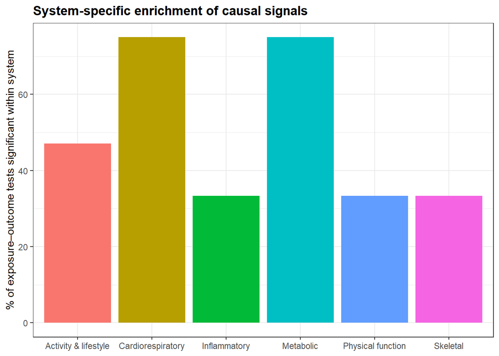

```r
############################################################
# Plot 2 — Normalized enrichment within each system
############################################################

# Total tests per system
total_tests <- sens2 %>%
  distinct(exposure, outcome) %>%
  left_join(system_map, by = "exposure") %>%
  count(system, name = "total_tests")

# Significant tests per system
sig_tests <- sens2 %>%
  distinct(exposure, outcome, .keep_all = TRUE) %>%
  filter(!is.na(q) & q < 0.05) %>%
  left_join(system_map, by = "exposure") %>%
  count(system, name = "sig_tests")

# Combine
system_df_norm <- total_tests %>%
  left_join(sig_tests, by = "system") %>%
  mutate(
    sig_tests = ifelse(is.na(sig_tests), 0, sig_tests),
    percent = 100 * sig_tests / total_tests
  )

ggplot(system_df_norm, aes(system, percent, fill = system)) +
  geom_col() +
  labs(
    y = "% of exposure–outcome tests significant within system",
    x = NULL,
    title = "System-specific enrichment of causal signals"
  ) +
  theme_bw() +
  theme(
    plot.title = element_text(face = "bold"),
    legend.position = "none"
  )
```

```r
############################################################
# S15.S3 — Mechanistic priority trait shortlist
############################################################

library(dplyr)
library(writexl)

priority_traits <- sens2 %>%
  dplyr::distinct(exposure, outcome, .keep_all = TRUE) %>%
  dplyr::filter(!is.na(q) & q < 0.05) %>%
  dplyr::filter(
    steiger_ok == TRUE,
    flag_out %in% FALSE | is.na(flag_out)
  ) %>%
  dplyr::arrange(q) %>%
  dplyr::select(
    exposure, outcome, b_ivw, q, Robustness, Stars
  )


library(DT)

datatable(
  priority_traits,
  options = list(
    pageLength = 10,
    scrollX = TRUE
  ),
  caption = "Prioritized causal associations (FDR < 0.05, Steiger-consistent, no MR-PRESSO outliers)"
)
```

|  | exposure | outcome | b_ivw | q | Robustness | Stars |
| --- | --- | --- | --- | --- | --- | --- |
| 1 | ldl | Parental_lifespan | -0.1735716406955919 | 3.309236935970412e-25 | Strong | ★ |
| 2 | fat_mass | Usual_walking_pace | -0.09882736191530073 | 2.646696379014701e-19 | Strong | ★ |
| 3 | whr_adjbmi | Healthspan | 0.1759587070731447 | 8.047777625625307e-16 | Strong | ★ |
| 4 | grip_strength | Usual_walking_pace | 0.1429621176881462 | 1.131016773928594e-15 | Strong | ★ |
| 5 | leisure_screen_t | Usual_walking_pace | -0.08548758452536324 | 5.994149681045635e-14 | Strong | ★ |
| 6 | smoking_initiation | Parental_lifespan | -0.5456030771248931 | 4.491988983873006e-13 | Strong | ★ |
| 7 | fev1 | Usual_walking_pace | 0.07619015012780557 | 4.491988983873006e-13 | Strong | ★ |
| 8 | hba1c | Healthspan | 0.09675572947124862 | 6.072118185725872e-13 | Strong | ★ |
| 9 | wc_adjbmi | Healthspan | 0.309361908132993 | 7.508072438594327e-09 | Strong | ★ |
| 10 | triglycerides | Parental_lifespan | -0.1176599729884456 | 2.016310135783324e-08 | Strong | ★ |

[output cut: 18 more lines]

```r
#------------------------------------------------------------
# Write Excel file (clean columns, no locale issues)
#------------------------------------------------------------

out_path <- "C:/Users/75118/Desktop/UEA/Proyecto 1/MainMRresults/Section_15.3.2_Mechanistic_priority_traits.xlsx"

write_xlsx(
  priority_traits,
  path = out_path
)

cat("✅ Excel file written to:\n", out_path, "\n")
```

```
## ✅ Excel file written to:
##  C:/Users/75118/Desktop/UEA/Proyecto 1/MainMRresults/Section_15.3.2_Mechanistic_priority_traits.xlsx
```